# Why Discussion Rules Matter: Populated pre-analysis plan

Rachel Brulé, Alyssa Heinze, Simon Chauchard

# Summary

This document includes the populated pre-analysis plan for “Why Discussion Rules Matter.” The black text is the original, unchanged text from the pre-analysis plan. Blue text indicates deviations and precisions.

# First group of hypotheses: Institutional Centrality

### This measures the degree of de facto centrality (or authority) of the de jure central official (the Sarpanch) in a typical decision-making process.

#### IC1 (H3.1): *Oral participation to the meeting will be more likely for those sarpanches exposed to treatment requiring the sarpanch to speak (T1 and T2) versus those not exposed (Control).*

- Assessed by regressing “equal participation” on treatment status (T1 or T2 versus control). Two-tailed tests are used in all cases.
- We check the robustness of results with bivariate regressions on treatment status and a multivariate regression including a standard set of demographic controls. We also control for the potential presence of a sarpanch relative during the interview (“the interview” being here understood as the group interview), both separately and in interaction with the gender of the sarpanch.
- In order to measure equal participation, we make use of the following two survey items:
  - Q29: Does the sarpanch respond first to the question (Y/N)
  - Q30: Does the sarpanch speak at all? (Y/N)
- In additional analyses, we disentangle between T1 and T2. We also include the series of individual and village level controls presented in G2.
- Deviation 1: Living with in-laws and one’s own parents were planned to be included in the wealth index. We instead include them as separate controls, because they are not indicative of wealth.
- Precision 1: Village-level controls were not presented in cell G2 of the PAP spreadsheet; instead, they were presented in cell H4. This was a typo on our part.

|  | DV: Sarpanch responded first Unadjusted | DV: Sarpanch responded first Adjusted, demographic controls | DV: Sarpanch responded first Adjusted, demographic and village controls | DV: Sarpanch spoke at all Unadjusted | DV: Sarpanch spoke at all Adjusted, demographic controls | DV: Sarpanch spoke at all Adjusted, demographic and village controls |
| --- | --- | --- | --- | --- | --- | --- |
| (Intercept) | 0.323*** | 0.406*** | 0.313** | 0.802*** | 0.907*** | 0.938*** |
|  | (0.034) | (0.081) | (0.113) | (0.029) | (0.063) | (0.090) |
| Discussion rules | 0.178*** | 0.138** | 0.134** | 0.055 | 0.039 | 0.036 |
|  | (0.042) | (0.042) | (0.043) | (0.034) | (0.034) | (0.035) |
| Sarpanch woman |  | -0.286* | -0.221 |  | -0.019 | 0.044 |
|  |  | (0.126) | (0.139) |  | (0.119) | (0.108) |
| Sarpanch relative present |  | -0.367+ | -0.392* |  | -0.096 | -0.122 |
|  |  | (0.197) | (0.193) |  | (0.200) | (0.214) |
| Sarpanch SC |  | -0.101 | -0.035 |  | 0.015 | 0.007 |
|  |  | (0.086) | (0.088) |  | (0.077) | (0.074) |
| Sarpanch OBC |  | -0.002 | 0.035 |  | -0.027 | -0.009 |
|  |  | (0.055) | (0.057) |  | (0.044) | (0.043) |
| Education above median |  | 0.172*** | 0.176*** |  | 0.079** | 0.073* |
|  |  | (0.044) | (0.045) |  | (0.031) | (0.031) |
| Wealth above median |  | -0.022 | -0.015 |  | 0.063* | 0.054+ |
|  |  | (0.041) | (0.043) |  | (0.032) | (0.032) |
| Lives with in-laws |  | 0.090 | 0.070 |  | -0.080 | -0.125 |
|  |  | (0.110) | (0.118) |  | (0.101) | (0.091) |
| Lives with own parents |  | 0.076 | 0.077 |  | -0.057 | -0.053 |
|  |  | (0.048) | (0.051) |  | (0.038) | (0.039) |
| Years as sarpanch |  | -0.005 | 0.002 |  | -0.013 | -0.012 |
|  |  | (0.013) | (0.014) |  | (0.010) | (0.011) |
| Gender quota |  | -0.011 | -0.052 |  | -0.073 | -0.098 |
|  |  | (0.069) | (0.075) |  | (0.065) | (0.068) |
| SC quota |  | 0.014 | -0.050 |  | -0.052 | -0.042 |
|  |  | (0.085) | (0.088) |  | (0.076) | (0.073) |
| OBC quota |  | 0.048 | 0.010 |  | 0.088* | 0.092* |
|  |  | (0.053) | (0.055) |  | (0.042) | (0.040) |
| Sarpanch woman:Sarpanch relative present |  | 0.218 | 0.165 |  | -0.090 | -0.126 |
|  |  | (0.210) | (0.204) |  | (0.217) | (0.233) |
| Percent of village land held by biggest landholding caste |  |  | -0.000 |  |  | -0.001 |
|  |  |  | (0.001) |  |  | (0.001) |
| Distance (km) from block center |  |  | 0.002 |  |  | 0.002 |
|  |  |  | (0.002) |  |  | (0.001) |
| Directly elected |  |  | 0.087+ |  |  | 0.017 |
|  |  |  | (0.045) |  |  | (0.033) |
| Num.Obs. | 605 | 549 | 506 | 605 | 549 | 506 |
| R2 | 0.028 | 0.167 | 0.195 | 0.005 | 0.120 | 0.147 |

+ p < 0.1, * p < 0.05, ** p < 0.01, *** p < 0.001  
Each model is a linear regression of each outcome on an indicator for being assigned to discussion rules (1) versus not (0). Unadjusted and covariate-adjusted models presented. All regressions use robust standard errors.

|  | DV: Sarpanch responded first Unadjusted | DV: Sarpanch responded first Adjusted, demographic controls | DV: Sarpanch responded first Adjusted, demographic and village controls | DV: Sarpanch spoke at all Unadjusted | DV: Sarpanch spoke at all Adjusted, demographic controls | DV: Sarpanch spoke at all Adjusted, demographic and village controls |
| --- | --- | --- | --- | --- | --- | --- |
| (Intercept) | 0.323*** | 0.471*** | 0.368** | 0.826*** | 0.844*** | 0.921*** |
|  | (0.034) | (0.090) | (0.125) | (0.019) | (0.068) | (0.109) |
| T1 | 0.338*** | 0.301*** | 0.310*** | 0.039 | 0.048 | 0.050 |
|  | (0.047) | (0.047) | (0.048) | (0.030) | (0.038) | (0.039) |
| Sarpanch woman |  | -0.378** | -0.314* |  | 0.037 | 0.021 |
|  |  | (0.130) | (0.135) |  | (0.142) | (0.139) |
| Sarpanch relative present |  | -0.671*** | -0.641*** |  | -0.303 | -0.338 |
|  |  | (0.142) | (0.143) |  | (0.309) | (0.323) |
| Sarpanch SC |  | -0.214* | -0.161 |  | 0.011 | -0.015 |
|  |  | (0.101) | (0.112) |  | (0.094) | (0.094) |
| Sarpanch OBC |  | -0.065 | -0.030 |  | -0.050 | -0.027 |
|  |  | (0.059) | (0.060) |  | (0.050) | (0.050) |
| Education above median |  | 0.194*** | 0.178*** |  | 0.121** | 0.098** |
|  |  | (0.051) | (0.052) |  | (0.037) | (0.037) |
| Wealth above median |  | 0.014 | 0.017 |  | 0.067+ | 0.048 |
|  |  | (0.047) | (0.049) |  | (0.039) | (0.040) |
| Lives with in-laws |  | 0.146 | 0.143 |  | -0.113 | -0.109 |
|  |  | (0.108) | (0.110) |  | (0.132) | (0.126) |
| Lives with own parents |  | 0.087 | 0.109+ |  | -0.033 | -0.029 |
|  |  | (0.056) | (0.057) |  | (0.042) | (0.044) |
| Years as sarpanch |  | -0.021 | -0.018 |  | 0.001 | -0.000 |
|  |  | (0.015) | (0.016) |  | (0.012) | (0.013) |
| Gender quota |  | -0.026 | -0.061 |  | -0.101 | -0.093 |
|  |  | (0.082) | (0.086) |  | (0.071) | (0.077) |
| SC quota |  | 0.158 | 0.111 |  | -0.042 | -0.009 |
|  |  | (0.101) | (0.110) |  | (0.094) | (0.092) |
| OBC quota |  | 0.035 | 0.004 |  | 0.086+ | 0.094* |
|  |  | (0.057) | (0.059) |  | (0.048) | (0.047) |
| Sarpanch woman:Sarpanch relative present |  | 0.543** | 0.434* |  | 0.172 | 0.134 |
|  |  | (0.170) | (0.169) |  | (0.324) | (0.339) |
| Percent of village land held by biggest landholding caste |  |  | 0.001 |  |  | -0.001 |
|  |  |  | (0.001) |  |  | (0.001) |
| Distance (km) from block center |  |  | -0.000 |  |  | 0.000 |
|  |  |  | (0.002) |  |  | (0.002) |
| Directly elected |  |  | 0.123* |  |  | 0.042 |
|  |  |  | (0.049) |  |  | (0.039) |
| Num.Obs. | 407 | 370 | 340 | 605 | 370 | 340 |
| R2 | 0.114 | 0.308 | 0.344 | 0.003 | 0.136 | 0.154 |

+ p < 0.1, * p < 0.05, ** p < 0.01, *** p < 0.001  
Each model is a linear regression of each outcome on an indicator for being assigned to T1 (1) versus control (0). Unadjusted and covariate-adjusted models presented. All regressions use robust standard errors.

|  | DV: Sarpanch responded first Unadjusted | DV: Sarpanch responded first Adjusted, demographic controls | DV: Sarpanch responded first Adjusted, demographic and village controls | DV: Sarpanch spoke at all Unadjusted | DV: Sarpanch spoke at all Adjusted, demographic controls | DV: Sarpanch spoke at all Adjusted, demographic and village controls |
| --- | --- | --- | --- | --- | --- | --- |
| (Intercept) | 0.323*** | 0.340*** | 0.237 | 0.835*** | 0.944*** | 0.876*** |
|  | (0.034) | (0.101) | (0.144) | (0.018) | (0.084) | (0.118) |
| T2 | 0.005 | -0.040 | -0.047 | 0.013 | 0.014 | 0.015 |
|  | (0.048) | (0.049) | (0.051) | (0.031) | (0.039) | (0.041) |
| Sarpanch woman |  | -0.256 | -0.209 |  | -0.074 | 0.087 |
|  |  | (0.165) | (0.189) |  | (0.177) | (0.166) |
| Sarpanch relative present |  | -0.198 | -0.229 |  | -0.116 | -0.126 |
|  |  | (0.274) | (0.272) |  | (0.264) | (0.282) |
| Sarpanch SC |  | -0.082 | -0.013 |  | -0.039 | -0.012 |
|  |  | (0.100) | (0.103) |  | (0.109) | (0.106) |
| Sarpanch OBC |  | -0.009 | 0.021 |  | -0.038 | -0.006 |
|  |  | (0.066) | (0.069) |  | (0.060) | (0.059) |
| Education above median |  | 0.165** | 0.184** |  | 0.050 | 0.060 |
|  |  | (0.055) | (0.057) |  | (0.042) | (0.043) |
| Wealth above median |  | -0.049 | -0.045 |  | 0.064 | 0.063 |
|  |  | (0.050) | (0.053) |  | (0.041) | (0.041) |
| Lives with in-laws |  | 0.050 | 0.062 |  | -0.095 | -0.168 |
|  |  | (0.151) | (0.164) |  | (0.142) | (0.135) |
| Lives with own parents |  | 0.118+ | 0.094 |  | -0.052 | -0.049 |
|  |  | (0.060) | (0.063) |  | (0.052) | (0.054) |
| Years as sarpanch |  | -0.001 | 0.002 |  | -0.022 | -0.019 |
|  |  | (0.016) | (0.018) |  | (0.014) | (0.016) |
| Gender quota |  | 0.061 | 0.002 |  | -0.006 | -0.104 |
|  |  | (0.078) | (0.090) |  | (0.099) | (0.099) |
| SC quota |  | 0.020 | -0.048 |  | 0.019 | 0.000 |
|  |  | (0.098) | (0.103) |  | (0.108) | (0.105) |
| OBC quota |  | 0.077 | 0.044 |  | 0.122* | 0.128* |
|  |  | (0.065) | (0.069) |  | (0.055) | (0.053) |
| Sarpanch woman:Sarpanch relative present |  | 0.082 | 0.047 |  | -0.151 | -0.183 |
|  |  | (0.281) | (0.274) |  | (0.286) | (0.303) |
| Percent of village land held by biggest landholding caste |  |  | 0.000 |  |  | -0.000 |
|  |  |  | (0.001) |  |  | (0.001) |
| Distance (km) from block center |  |  | 0.002 |  |  | 0.002 |
|  |  |  | (0.002) |  |  | (0.002) |
| Directly elected |  |  | 0.125* |  |  | 0.012 |
|  |  |  | (0.055) |  |  | (0.045) |
| Num.Obs. | 390 | 351 | 325 | 605 | 351 | 325 |
| R2 | 0.000 | 0.136 | 0.169 | 0.000 | 0.127 | 0.158 |

+ p < 0.1, * p < 0.05, ** p < 0.01, *** p < 0.001  
Each model is a linear regression of each outcome on an indicator for being assigned to T2 (1) versus control (0). Unadjusted and covariate-adjusted models presented. All regressions use robust standard errors.

### IC2 (H3.2): *Institutional centrality of the sarpanch will be higher for those exposed to treatment requiring the sarpanch to speak (T1 and T2) versus not exposed (Control).*

- We focus on differences in (i) means and (ii) the graphical distribution of values across treatment (clubbing T1 and T2 together) and control conditions for each dependent variable, with respect to our measures of institutional centrality (both perceptions and behaviors).
- We also control for the potential presence of a sarpanch relative during the interview (“the interview” being here understood as the group interview), both separately and in interaction with the gender of the sarpanch. Cluster-corrected standard errors will be used at the taluka level. We check the robustness of results with bivariate regressions on treatment status and a multivariate regression including a standard set of demographic controls.
- We draw on our group survey instrument to develop three primary measures of institutional centrality (IC), below. We include additional measures of IC in the Supplemental Appendix.
  - Q35: “Who made the final decision?” (for the budget - enumerator codes, 1: sarpanch)
  - Q39: Responded first to the question: What are the roles and responsibilities of the sarpanch? Which are most important to you? (1=Yes/0=anything else)
  - Q91: “For what approximate percentage of the discussion did the sarpanch speak?” (0-100%, normalized to 0-1 scale)
- In additional analyses, we disentangle the impact of T1 and T2. We also run bivariate regressions, clustering at the taluka level, and we also include the series of individual and village level demographic controls presented in G2.
- Deviation 1: Living with in-laws and one’s own parents were planned to be included in the wealth index. We instead include them as separate controls, because they are not indicative of wealth.
- Deviation 2: We originally planned to use clustered standard errors at the taluka level. This was an error on our part: because the treatment assignment occurs at the level of each village council, we do not cluster standard errors in these analyses.
- Deviation 3: Because the first two variables are binary, comparing graphical distributions is not more informative than running regressions. However, we do still compare graphical distributions between treatment/control for the third outcome variable.
- Precision 1: Village-level controls were not presented in cell G2 of the PAP spreadsheet; instead, they were presented in cell H4. This was a typo on our part.
- Precision 2: We previously did not state how we would formally test whether the distributions of outcome variables under each treatment condition are statistically different from each other. We do so here using an asymptotic two-sample Kolmogorov-Smirnov test.

|  | DV: Sarpanch made final budget decision Unadjusted | DV: Sarpanch made final budget decision Adjusted, demographic controls | DV: Sarpanch made final budget decision Adjusted, demographic and village controls | DV: Sarpanch responded first to roles/resp. Unadjusted | DV: Sarpanch responded first to roles/resp. Adjusted, demographic controls | DV: Sarpanch responded first to roles/resp. Adjusted, demographic and village controls | DV: Proportion of time sarpanch spoke Unadjusted | DV: Proportion of time sarpanch spoke Adjusted, demographic controls | DV: Proportion of time sarpanch spoke Adjusted, demographic and village controls |
| --- | --- | --- | --- | --- | --- | --- | --- | --- | --- |
| (Intercept) | 0.193*** | 0.345*** | 0.472*** | 0.786*** | 0.804*** | 0.727*** | 0.256*** | 0.279*** | 0.299*** |
|  | (0.029) | (0.077) | (0.107) | (0.030) | (0.069) | (0.093) | (0.011) | (0.024) | (0.035) |
| Discussion rules | 0.122*** | 0.094* | 0.101* | 0.022 | -0.001 | -0.014 | 0.034* | 0.015 | 0.015 |
|  | (0.037) | (0.038) | (0.040) | (0.035) | (0.037) | (0.036) | (0.014) | (0.012) | (0.013) |
| Sarpanch woman |  | -0.141 | -0.106 |  | -0.095 | -0.029 |  | -0.100** | -0.072+ |
|  |  | (0.119) | (0.135) |  | (0.130) | (0.127) |  | (0.038) | (0.040) |
| Sarpanch relative present |  | -0.001 | -0.028 |  | 0.145*** | 0.126* |  | 0.025 | 0.013 |
|  |  | (0.227) | (0.232) |  | (0.039) | (0.052) |  | (0.126) | (0.126) |
| Sarpanch SC |  | -0.168+ | -0.180+ |  | -0.039 | 0.009 |  | 0.016 | 0.025 |
|  |  | (0.095) | (0.098) |  | (0.075) | (0.076) |  | (0.021) | (0.022) |
| Sarpanch OBC |  | -0.055 | -0.047 |  | 0.017 | 0.073 |  | 0.008 | 0.019 |
|  |  | (0.051) | (0.054) |  | (0.049) | (0.050) |  | (0.016) | (0.017) |
| Education above median |  | 0.106** | 0.121** |  | 0.122*** | 0.129*** |  | 0.081*** | 0.079*** |
|  |  | (0.040) | (0.041) |  | (0.034) | (0.035) |  | (0.012) | (0.013) |
| Wealth above median |  | -0.023 | -0.026 |  | 0.023 | 0.006 |  | 0.011 | 0.010 |
|  |  | (0.038) | (0.039) |  | (0.036) | (0.037) |  | (0.012) | (0.012) |
| Lives with in-laws |  | -0.109 | -0.120 |  | 0.087 | 0.031 |  | -0.006 | -0.013 |
|  |  | (0.107) | (0.119) |  | (0.118) | (0.115) |  | (0.035) | (0.036) |
| Lives with own parents |  | -0.017 | -0.041 |  | 0.012 | 0.003 |  | 0.026+ | 0.023 |
|  |  | (0.042) | (0.046) |  | (0.041) | (0.040) |  | (0.014) | (0.014) |
| Years as sarpanch |  | 0.006 | 0.009 |  | -0.015 | -0.009 |  | 0.005 | 0.004 |
|  |  | (0.013) | (0.013) |  | (0.012) | (0.012) |  | (0.004) | (0.004) |
| Gender quota |  | 0.006 | -0.015 |  | -0.110+ | -0.156* |  | -0.018 | -0.037+ |
|  |  | (0.057) | (0.064) |  | (0.063) | (0.065) |  | (0.018) | (0.019) |
| SC quota |  | 0.115 | 0.122 |  | 0.079 | 0.051 |  | -0.041* | -0.048* |
|  |  | (0.093) | (0.096) |  | (0.072) | (0.072) |  | (0.020) | (0.022) |
| OBC quota |  | 0.029 | 0.010 |  | 0.042 | 0.020 |  | 0.001 | -0.007 |
|  |  | (0.050) | (0.053) |  | (0.048) | (0.047) |  | (0.016) | (0.016) |
| Sarpanch woman:Sarpanch relative present |  | -0.051 | -0.030 |  | -0.308** | -0.309** |  | -0.103 | -0.104 |
|  |  | (0.234) | (0.240) |  | (0.099) | (0.108) |  | (0.128) | (0.128) |
| Percent of village land held by biggest landholding caste |  |  | -0.002* |  |  | 0.000 |  |  | -0.000 |
|  |  |  | (0.001) |  |  | (0.001) |  |  | (0.000) |
| Distance (km) from block center |  |  | 0.000 |  |  | 0.002* |  |  | -0.000 |
|  |  |  | (0.002) |  |  | (0.001) |  |  | (0.001) |
| Directly elected |  |  | 0.022 |  |  | 0.008 |  |  | 0.026* |
|  |  |  | (0.042) |  |  | (0.036) |  |  | (0.013) |
| Num.Obs. | 605 | 549 | 506 | 605 | 549 | 506 | 604 | 548 | 505 |
| R2 | 0.016 | 0.119 | 0.128 | 0.001 | 0.087 | 0.119 | 0.010 | 0.366 | 0.376 |

+ p < 0.1, * p < 0.05, ** p < 0.01, *** p < 0.001  
Each model is a linear regression of each outcome on an indicator for being assigned to discussion rules (1) versus not (0). Unadjusted and covariate-adjusted models presented. All regressions use robust standard errors.

|  | DV: Sarpanch made final budget decision Unadjusted | DV: Sarpanch made final budget decision Adjusted, demographic controls | DV: Sarpanch made final budget decision Adjusted, demographic and village controls | DV: Sarpanch responded first to roles/resp. Unadjusted | DV: Sarpanch responded first to roles/resp. Adjusted, demographic controls | DV: Sarpanch responded first to roles/resp. Adjusted, demographic and village controls | DV: Proportion of time sarpanch spoke Unadjusted | DV: Proportion of time sarpanch spoke Adjusted, demographic controls | DV: Proportion of time sarpanch spoke Adjusted, demographic and village controls |
| --- | --- | --- | --- | --- | --- | --- | --- | --- | --- |
| (Intercept) | 0.193*** | 0.364*** | 0.445*** | 0.786*** | 0.795*** | 0.821*** | 0.256*** | 0.302*** | 0.332*** |
|  | (0.029) | (0.084) | (0.122) | (0.030) | (0.081) | (0.104) | (0.011) | (0.029) | (0.042) |
| T1 | 0.063 | 0.044 | 0.045 | 0.051 | 0.033 | 0.017 | 0.036* |  | 0.015 |
|  | (0.041) | (0.043) | (0.046) | (0.039) | (0.040) | (0.039) | (0.016) |  | (0.014) |
| Sarpanch woman |  | -0.011 | -0.020 |  | 0.036 | 0.052 |  | -0.116** | -0.098** |
|  |  | (0.128) | (0.138) |  | (0.135) | (0.124) |  | (0.038) | (0.037) |
| Sarpanch relative present |  | -0.079 | -0.140 |  | 0.091 | 0.017 |  | -0.120 | -0.127 |
|  |  | (0.273) | (0.287) |  | (0.064) | (0.091) |  | (0.102) | (0.104) |
| Sarpanch SC |  | -0.147 | -0.155 |  | -0.010 | 0.026 |  | -0.008 | -0.005 |
|  |  | (0.097) | (0.102) |  | (0.091) | (0.093) |  | (0.027) | (0.030) |
| Sarpanch OBC |  | -0.067 | -0.058 |  | 0.043 | 0.083 |  | -0.000 | 0.009 |
|  |  | (0.057) | (0.060) |  | (0.057) | (0.058) |  | (0.020) | (0.020) |
| Education above median |  | 0.120** | 0.121* |  | 0.129** | 0.126** |  | 0.101*** | 0.097*** |
|  |  | (0.046) | (0.047) |  | (0.041) | (0.042) |  | (0.015) | (0.015) |
| Wealth above median |  | -0.034 | -0.024 |  | 0.011 | -0.002 |  | 0.005 | 0.004 |
|  |  | (0.043) | (0.045) |  | (0.043) | (0.044) |  | (0.014) | (0.014) |
| Lives with in-laws |  | -0.217+ | -0.209+ |  | -0.071 | -0.078 |  | 0.005 | 0.002 |
|  |  | (0.114) | (0.122) |  | (0.127) | (0.116) |  | (0.035) | (0.032) |
| Lives with own parents |  | -0.070 | -0.087+ |  | -0.042 | -0.052 |  | 0.003 | -0.001 |
|  |  | (0.048) | (0.053) |  | (0.050) | (0.049) |  | (0.017) | (0.018) |
| Years as sarpanch |  | 0.016 | 0.022 |  | -0.007 | -0.004 |  | 0.006 | 0.005 |
|  |  | (0.015) | (0.016) |  | (0.014) | (0.014) |  | (0.005) | (0.005) |
| Gender quota |  | -0.057 | -0.038 |  | -0.099 | -0.154* |  | -0.030 | -0.043* |
|  |  | (0.066) | (0.073) |  | (0.068) | (0.065) |  | (0.021) | (0.022) |
| SC quota |  | 0.051 | 0.052 |  | 0.121 | 0.100 |  | -0.026 | -0.029 |
|  |  | (0.094) | (0.098) |  | (0.086) | (0.088) |  | (0.026) | (0.028) |
| OBC quota |  | 0.072 | 0.056 |  | 0.030 | 0.028 |  | 0.001 | -0.009 |
|  |  | (0.056) | (0.059) |  | (0.056) | (0.054) |  | (0.018) | (0.019) |
| Sarpanch woman:Sarpanch relative present |  | 0.035 | 0.078 |  | -0.253* | -0.202 |  | 0.040 | 0.031 |
|  |  | (0.281) | (0.295) |  | (0.125) | (0.142) |  | (0.104) | (0.107) |
| Percent of village land held by biggest landholding caste |  |  | -0.002* |  |  | -0.001 |  |  | -0.000 |
|  |  |  | (0.001) |  |  | (0.001) |  |  | (0.000) |
| Distance (km) from block center |  |  | 0.002 |  |  | 0.004* |  |  | -0.000 |
|  |  |  | (0.002) |  |  | (0.002) |  |  | (0.001) |
| Directly elected |  |  | 0.011 |  |  | 0.024 |  |  | 0.024 |
|  |  |  | (0.049) |  |  | (0.042) |  |  | (0.016) |
| treatment_1_2_together |  |  |  |  |  |  |  | 0.013 |  |
|  |  |  |  |  |  |  |  | (0.014) |  |
| Num.Obs. | 407 | 370 | 340 | 407 | 370 | 340 | 406 | 369 | 339 |
| R2 | 0.006 | 0.141 | 0.141 | 0.004 | 0.097 | 0.148 | 0.013 | 0.396 | 0.398 |

+ p < 0.1, * p < 0.05, ** p < 0.01, *** p < 0.001  
Each model is a linear regression of each outcome on an indicator for being assigned to T1 (1) versus control (0). Unadjusted and covariate-adjusted models presented. All regressions use robust standard errors.

|  | DV: Sarpanch made final budget decision Unadjusted | DV: Sarpanch made final budget decision Adjusted, demographic controls | DV: Sarpanch made final budget decision Adjusted, demographic and village controls | DV: Sarpanch responded first to roles/resp. Unadjusted | DV: Sarpanch responded first to roles/resp. Adjusted, demographic controls | DV: Sarpanch responded first to roles/resp. Adjusted, demographic and village controls | DV: Proportion of time sarpanch spoke Unadjusted | DV: Proportion of time sarpanch spoke Adjusted, demographic controls | DV: Proportion of time sarpanch spoke Adjusted, demographic and village controls |
| --- | --- | --- | --- | --- | --- | --- | --- | --- | --- |
| (Intercept) | 0.193*** | 0.313** | 0.530*** | 0.786*** | 0.819*** | 0.740*** | 0.256*** | 0.256*** | 0.281*** |
|  | (0.029) | (0.096) | (0.133) | (0.030) | (0.089) | (0.126) | (0.011) | (0.031) | (0.048) |
| T2 | 0.186*** | 0.140** | 0.152** | -0.009 | -0.040 | -0.056 | 0.031* | 0.012 | 0.012 |
|  | (0.045) | (0.048) | (0.049) | (0.042) | (0.043) | (0.044) | (0.016) | (0.015) | (0.015) |
| Sarpanch woman |  | -0.215 | -0.144 |  | -0.187 | -0.132 |  | -0.098+ | -0.066 |
|  |  | (0.157) | (0.190) |  | (0.158) | (0.166) |  | (0.055) | (0.059) |
| Sarpanch relative present |  | -0.136 | -0.147 |  | 0.190** | 0.147+ |  | 0.001 | -0.016 |
|  |  | (0.254) | (0.259) |  | (0.070) | (0.086) |  | (0.166) | (0.161) |
| Sarpanch SC |  | -0.175 | -0.182 |  | -0.006 | 0.041 |  | 0.026 | 0.040 |
|  |  | (0.131) | (0.131) |  | (0.101) | (0.104) |  | (0.025) | (0.026) |
| Sarpanch OBC |  | -0.051 | -0.059 |  | -0.021 | 0.057 |  | 0.008 | 0.018 |
|  |  | (0.066) | (0.071) |  | (0.069) | (0.073) |  | (0.020) | (0.020) |
| Education above median |  | 0.123* | 0.153** |  | 0.144** | 0.163*** |  | 0.071*** | 0.068*** |
|  |  | (0.051) | (0.052) |  | (0.045) | (0.047) |  | (0.015) | (0.016) |
| Wealth above median |  | -0.010 | -0.012 |  | -0.000 | -0.022 |  | 0.015 | 0.012 |
|  |  | (0.046) | (0.047) |  | (0.046) | (0.046) |  | (0.014) | (0.014) |
| Lives with in-laws |  | -0.003 | -0.027 |  | 0.130 | 0.075 |  | -0.013 | -0.025 |
|  |  | (0.142) | (0.168) |  | (0.132) | (0.138) |  | (0.051) | (0.056) |
| Lives with own parents |  | -0.002 | -0.031 |  | 0.027 | 0.010 |  | 0.048** | 0.042* |
|  |  | (0.056) | (0.058) |  | (0.054) | (0.051) |  | (0.017) | (0.017) |
| Years as sarpanch |  | 0.001 | -0.002 |  | -0.026 | -0.020 |  | 0.005 | 0.002 |
|  |  | (0.016) | (0.017) |  | (0.016) | (0.017) |  | (0.005) | (0.005) |
| Gender quota |  | 0.004 | -0.056 |  | -0.034 | -0.080 |  | 0.003 | -0.020 |
|  |  | (0.078) | (0.091) |  | (0.092) | (0.096) |  | (0.022) | (0.023) |
| SC quota |  | 0.171 | 0.152 |  | 0.029 | 0.015 |  | -0.032 | -0.047+ |
|  |  | (0.132) | (0.132) |  | (0.098) | (0.101) |  | (0.026) | (0.028) |
| OBC quota |  | -0.000 | -0.028 |  | 0.097 | 0.064 |  | 0.011 | 0.002 |
|  |  | (0.065) | (0.068) |  | (0.067) | (0.069) |  | (0.020) | (0.021) |
| Sarpanch woman:Sarpanch relative present |  | 0.110 | 0.126 |  | -0.329* | -0.305* |  | -0.073 | -0.064 |
|  |  | (0.266) | (0.271) |  | (0.136) | (0.148) |  | (0.167) | (0.163) |
| Percent of village land held by biggest landholding caste |  |  | -0.003* |  |  | 0.001 |  |  | -0.000 |
|  |  |  | (0.001) |  |  | (0.001) |  |  | (0.000) |
| Distance (km) from block center |  |  | -0.001 |  |  | 0.002 |  |  | -0.000 |
|  |  |  | (0.002) |  |  | (0.002) |  |  | (0.001) |
| Directly elected |  |  | 0.008 |  |  | 0.030 |  |  | 0.031+ |
|  |  |  | (0.052) |  |  | (0.048) |  |  | (0.016) |
| Num.Obs. | 390 | 351 | 325 | 390 | 351 | 325 | 390 | 351 | 325 |
| R2 | 0.042 | 0.135 | 0.159 | 0.000 | 0.093 | 0.129 | 0.010 | 0.366 | 0.376 |

+ p < 0.1, * p < 0.05, ** p < 0.01, *** p < 0.001  
Each model is a linear regression of each outcome on an indicator for being assigned to T2 (1) versus control (0). Unadjusted and covariate-adjusted models presented. All regressions use robust standard errors.

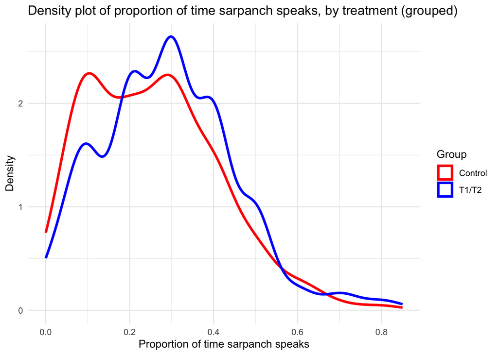

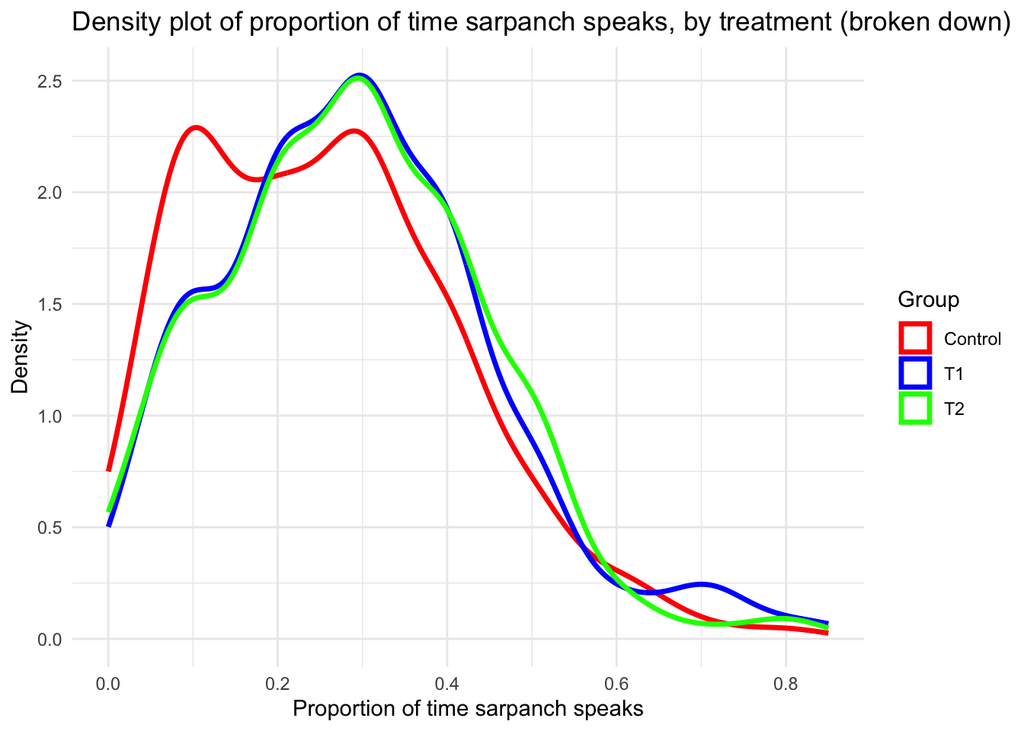

```
##
##  Asymptotic two-sample Kolmogorov-Smirnov test
##
## data:  df$proportion_time_spoken[df$treatment_1_2_together == 1] and df$proportion_time_spoken[df$treatment_1_2_together == 0]
## D = 0.11625, p-value = 0.05803
## alternative hypothesis: two-sided
```

### IC3 (H3.3): *Assignment to any treatment (T1 or T2, considered jointly) will improve institutional centrality at a higher rate if the sarpanch is from a disadvantaged group.*

- IC3 is assessed by regressing our primary measures of centrality (as specified immediately above in IC2) on a binary indicator of treatment (bundling T1 and T2 versus control), an indicator of the relevant dimension of disadvantage (including one regression using the index of disadvantage) and the multiplicative interaction between the two. For each of our 3 dependent variables, we run a regression interacting treatment status with indicators of the sarpanch’s gender and caste, as defined above. We also consider the alternate measures of disadvantage defined above. Our focus is on the interaction effects for each of these specifications. Cluster-corrected standard errors will be used at the administrative block level. We check the robustness of results with bivariate regressions on treatment status and a multivariate regression including a standard set of demographic controls. We also control for the potential presence of a sarpanch relative during the interview (“the interview” being here understood as the group interview), both separately and in interaction with the gender of the sarpanch.
- In additional analyses, we disentangle the impact of T1 and T2. We also run bivariate regressions, clustering at the taluka level, and we also include the series of individual and village level demographic controls presented in G2.
- Deviation 1: Living with in-laws and one’s own parents were planned to be included in the wealth index. We instead include them as separate controls, because they are not indicative of wealth.
- Deviation 2: We originally planned to use clustered standard errors at the taluka level. This was an error on our part: because the treatment assignment occurs at the level of each village council, we do not cluster standard errors in these analyses.
- Precision 1: Village-level controls were not presented in cell G2 of the PAP spreadsheet; instead, they were presented in cell H4. This was a typo on our part.
- Precision 2: We construct the index of disadvantage via all mentioned variables indicating disadvantage. We create an additive variable of disadvantage.

|  | DV: Sarpanch made final budget decision Unadjusted | DV: Sarpanch made final budget decision Adjusted, demographic controls | DV: Sarpanch made final budget decision Adjusted, demographic and village controls | DV: Sarpanch responded first to roles/resp. Unadjusted | DV: Sarpanch responded first to roles/resp. Adjusted, demographic controls | DV: Sarpanch responded first to roles/resp. Adjusted, demographic and village controls | DV: Proportion of time sarpanch spoke Unadjusted | DV: Proportion of time sarpanch spoke Adjusted, demographic controls | DV: Proportion of time sarpanch spoke Adjusted, demographic and village controls |
| --- | --- | --- | --- | --- | --- | --- | --- | --- | --- |
| (Intercept) | 0.333*** | 0.323*** | 0.435*** | 0.841*** | 0.762*** | 0.705*** | 0.354*** | 0.283*** | 0.304*** |
|  | (0.057) | (0.090) | (0.119) | (0.044) | (0.076) | (0.097) | (0.019) | (0.029) | (0.040) |
| Discussion rules | 0.132+ | 0.123+ | 0.144+ | 0.057 | 0.053 | 0.012 | 0.022 | 0.010 | 0.009 |
|  | (0.068) | (0.072) | (0.073) | (0.050) | (0.051) | (0.044) | (0.022) | (0.023) | (0.023) |
| Sarpanch woman | -0.220*** | -0.108 | -0.058 | -0.084 | -0.032 | -0.000 | -0.153*** | -0.105* | -0.079+ |
|  | (0.064) | (0.133) | (0.147) | (0.059) | (0.137) | (0.132) | (0.022) | (0.042) | (0.043) |
| Discussion rules:Sarpanch woman | -0.052 | -0.046 | -0.069 | -0.076 | -0.089 | -0.042 | -0.003 | 0.008 | 0.010 |
|  | (0.078) | (0.084) | (0.087) | (0.070) | (0.072) | (0.069) | (0.026) | (0.026) | (0.028) |
| Sarpanch relative present |  | 0.002 | -0.021 |  | 0.152*** | 0.130* |  | 0.025 | 0.012 |
|  |  | (0.224) | (0.227) |  | (0.037) | (0.050) |  | (0.127) | (0.127) |
| Sarpanch SC |  | -0.170+ | -0.181+ |  | -0.041 | 0.009 |  | 0.016 | 0.025 |
|  |  | (0.095) | (0.099) |  | (0.074) | (0.076) |  | (0.021) | (0.022) |
| Sarpanch OBC |  | -0.054 | -0.047 |  | 0.017 | 0.074 |  | 0.008 | 0.019 |
|  |  | (0.051) | (0.054) |  | (0.049) | (0.050) |  | (0.016) | (0.017) |
| Education above median |  | 0.106** | 0.121** |  | 0.122*** | 0.129*** |  | 0.081*** | 0.079*** |
|  |  | (0.040) | (0.041) |  | (0.034) | (0.035) |  | (0.012) | (0.013) |
| Wealth above median |  | -0.025 | -0.027 |  | 0.020 | 0.005 |  | 0.011 | 0.010 |
|  |  | (0.038) | (0.040) |  | (0.036) | (0.037) |  | (0.012) | (0.012) |
| Lives with in-laws |  | -0.109 | -0.119 |  | 0.088 | 0.032 |  | -0.006 | -0.013 |
|  |  | (0.107) | (0.119) |  | (0.117) | (0.115) |  | (0.035) | (0.036) |
| Lives with own parents |  | -0.017 | -0.041 |  | 0.013 | 0.003 |  | 0.026+ | 0.023 |
|  |  | (0.042) | (0.046) |  | (0.041) | (0.040) |  | (0.014) | (0.014) |
| Years as sarpanch |  | 0.006 | 0.009 |  | -0.015 | -0.009 |  | 0.005 | 0.004 |
|  |  | (0.013) | (0.013) |  | (0.012) | (0.012) |  | (0.004) | (0.004) |
| Gender quota |  | 0.006 | -0.015 |  | -0.111+ | -0.156* |  | -0.018 | -0.037+ |
|  |  | (0.057) | (0.064) |  | (0.063) | (0.065) |  | (0.018) | (0.019) |
| SC quota |  | 0.118 | 0.125 |  | 0.084 | 0.053 |  | -0.041* | -0.049* |
|  |  | (0.094) | (0.097) |  | (0.071) | (0.072) |  | (0.020) | (0.022) |
| OBC quota |  | 0.031 | 0.011 |  | 0.045 | 0.020 |  | 0.000 | -0.008 |
|  |  | (0.050) | (0.053) |  | (0.048) | (0.047) |  | (0.016) | (0.016) |
| Sarpanch woman:Sarpanch relative present |  | -0.055 | -0.037 |  | -0.316** | -0.314** |  | -0.103 | -0.103 |
|  |  | (0.231) | (0.235) |  | (0.098) | (0.107) |  | (0.129) | (0.129) |
| Percent of village land held by biggest landholding caste |  |  | -0.002* |  |  | 0.000 |  |  | -0.000 |
|  |  |  | (0.001) |  |  | (0.001) |  |  | (0.000) |
| Distance (km) from block center |  |  | 0.001 |  |  | 0.002* |  |  | -0.000 |
|  |  |  | (0.002) |  |  | (0.001) |  |  | (0.001) |
| Directly elected |  |  | 0.022 |  |  | 0.008 |  |  | 0.026* |
|  |  |  | (0.042) |  |  | (0.036) |  |  | (0.013) |
| Num.Obs. | 605 | 549 | 506 | 605 | 549 | 506 | 604 | 548 | 505 |
| R2 | 0.096 | 0.119 | 0.129 | 0.031 | 0.089 | 0.119 | 0.242 | 0.366 | 0.376 |

+ p < 0.1, * p < 0.05, ** p < 0.01, *** p < 0.001  
Each model is a linear regression of each outcome on an indicator for being assigned to discussion rules (1) versus not (0). Unadjusted and covariate-adjusted models presented. All regressions use robust standard errors.

|  | DV: Sarpanch made final budget decision Unadjusted | DV: Sarpanch made final budget decision Adjusted, demographic controls | DV: Sarpanch made final budget decision Adjusted, demographic and village controls | DV: Sarpanch responded first to roles/resp. Unadjusted | DV: Sarpanch responded first to roles/resp. Adjusted, demographic controls | DV: Sarpanch responded first to roles/resp. Adjusted, demographic and village controls | DV: Proportion of time sarpanch spoke Unadjusted | DV: Proportion of time sarpanch spoke Adjusted, demographic controls | DV: Proportion of time sarpanch spoke Adjusted, demographic and village controls |
| --- | --- | --- | --- | --- | --- | --- | --- | --- | --- |
| (Intercept) | 0.333*** | 0.341*** | 0.411** | 0.841*** | 0.760*** | 0.806*** | 0.354*** | 0.302*** | 0.337*** |
|  | (0.057) | (0.095) | (0.134) | (0.044) | (0.085) | (0.108) | (0.019) | (0.032) | (0.046) |
| T1 | 0.073 | 0.077 | 0.088 | 0.093+ | 0.084 | 0.035 | 0.034 | 0.012 | 0.009 |
|  | (0.077) | (0.080) | (0.082) | (0.052) | (0.054) | (0.048) | (0.025) | (0.025) | (0.025) |
| Sarpanch woman | -0.220*** | 0.022 | 0.021 | -0.084 | 0.085 | 0.070 | -0.153*** | -0.117** | -0.103* |
|  | (0.064) | (0.143) | (0.154) | (0.059) | (0.140) | (0.129) | (0.022) | (0.042) | (0.040) |
| T1:Sarpanch woman | -0.042 | -0.056 | -0.071 | -0.083 | -0.085 | -0.031 | -0.013 | 0.002 | 0.009 |
|  | (0.088) | (0.095) | (0.099) | (0.075) | (0.079) | (0.076) | (0.030) | (0.030) | (0.031) |
| Sarpanch relative present |  | -0.071 | -0.127 |  | 0.104 | 0.023 |  | -0.120 | -0.128 |
|  |  | (0.266) | (0.278) |  | (0.072) | (0.092) |  | (0.102) | (0.106) |
| Sarpanch SC |  | -0.149 | -0.155 |  | -0.013 | 0.026 |  | -0.008 | -0.005 |
|  |  | (0.098) | (0.103) |  | (0.090) | (0.093) |  | (0.027) | (0.030) |
| Sarpanch OBC |  | -0.066 | -0.057 |  | 0.044 | 0.084 |  | -0.000 | 0.009 |
|  |  | (0.057) | (0.060) |  | (0.057) | (0.058) |  | (0.020) | (0.021) |
| Education above median |  | 0.121** | 0.121* |  | 0.131** | 0.127** |  | 0.101*** | 0.097*** |
|  |  | (0.046) | (0.047) |  | (0.042) | (0.042) |  | (0.015) | (0.015) |
| Wealth above median |  | -0.036 | -0.026 |  | 0.008 | -0.003 |  | 0.005 | 0.004 |
|  |  | (0.043) | (0.046) |  | (0.043) | (0.045) |  | (0.014) | (0.014) |
| Lives with in-laws |  | -0.217+ | -0.208+ |  | -0.070 | -0.078 |  | 0.005 | 0.002 |
|  |  | (0.114) | (0.123) |  | (0.127) | (0.116) |  | (0.035) | (0.032) |
| Lives with own parents |  | -0.069 | -0.086 |  | -0.040 | -0.051 |  | 0.003 | -0.001 |
|  |  | (0.048) | (0.053) |  | (0.050) | (0.049) |  | (0.017) | (0.018) |
| Years as sarpanch |  | 0.017 | 0.022 |  | -0.007 | -0.004 |  | 0.006 | 0.005 |
|  |  | (0.015) | (0.016) |  | (0.014) | (0.014) |  | (0.005) | (0.005) |
| Gender quota |  | -0.059 | -0.040 |  | -0.103 | -0.155* |  | -0.030 | -0.043* |
|  |  | (0.066) | (0.073) |  | (0.069) | (0.066) |  | (0.021) | (0.021) |
| SC quota |  | 0.056 | 0.057 |  | 0.128 | 0.102 |  | -0.027 | -0.029 |
|  |  | (0.095) | (0.099) |  | (0.085) | (0.088) |  | (0.026) | (0.028) |
| OBC quota |  | 0.074 | 0.059 |  | 0.033 | 0.029 |  | 0.001 | -0.009 |
|  |  | (0.056) | (0.059) |  | (0.056) | (0.054) |  | (0.018) | (0.019) |
| Sarpanch woman:Sarpanch relative present |  | 0.028 | 0.067 |  | -0.264* | -0.207 |  | 0.040 | 0.032 |
|  |  | (0.274) | (0.286) |  | (0.129) | (0.142) |  | (0.105) | (0.109) |
| Percent of village land held by biggest landholding caste |  |  | -0.002* |  |  | -0.001 |  |  | -0.000 |
|  |  |  | (0.001) |  |  | (0.001) |  |  | (0.000) |
| Distance (km) from block center |  |  | 0.003 |  |  | 0.004* |  |  | -0.000 |
|  |  |  | (0.002) |  |  | (0.002) |  |  | (0.001) |
| Directly elected |  |  | 0.011 |  |  | 0.025 |  |  | 0.023 |
|  |  |  | (0.049) |  |  | (0.042) |  |  | (0.016) |
| Num.Obs. | 407 | 370 | 340 | 407 | 370 | 340 | 406 | 369 | 339 |
| R2 | 0.086 | 0.142 | 0.143 | 0.033 | 0.100 | 0.148 | 0.251 | 0.396 | 0.398 |

+ p < 0.1, * p < 0.05, ** p < 0.01, *** p < 0.001  
Each model is a linear regression of each outcome on an indicator for being assigned to T1 (1) versus control (0). Unadjusted and covariate-adjusted models presented. All regressions use robust standard errors.

|  | DV: Sarpanch made final budget decision Unadjusted | DV: Sarpanch made final budget decision Adjusted, demographic controls | DV: Sarpanch made final budget decision Adjusted, demographic and village controls | DV: Sarpanch responded first to roles/resp. Unadjusted | DV: Sarpanch responded first to roles/resp. Adjusted, demographic controls | DV: Sarpanch responded first to roles/resp. Adjusted, demographic and village controls | DV: Proportion of time sarpanch spoke Unadjusted | DV: Proportion of time sarpanch spoke Adjusted, demographic controls | DV: Proportion of time sarpanch spoke Adjusted, demographic and village controls |
| --- | --- | --- | --- | --- | --- | --- | --- | --- | --- |
| (Intercept) | 0.333*** | 0.303** | 0.504*** | 0.841*** | 0.782*** | 0.715*** | 0.354*** | 0.262*** | 0.288*** |
|  | (0.057) | (0.103) | (0.141) | (0.044) | (0.094) | (0.129) | (0.019) | (0.034) | (0.051) |
| t2 | 0.188* | 0.157+ | 0.189* | 0.021 | 0.024 | -0.019 | 0.010 | 0.003 | 0.002 |
|  | (0.077) | (0.083) | (0.084) | (0.057) | (0.058) | (0.052) | (0.024) | (0.025) | (0.026) |
| Sarpanch woman | -0.220*** | -0.201 | -0.115 | -0.084 | -0.131 | -0.103 | -0.153*** | -0.106+ | -0.075 |
|  | (0.064) | (0.165) | (0.193) | (0.059) | (0.158) | (0.164) | (0.022) | (0.056) | (0.060) |
| t2:Sarpanch woman | -0.052 | -0.029 | -0.062 | -0.075 | -0.110 | -0.062 | 0.007 | 0.016 | 0.018 |
|  | (0.093) | (0.100) | (0.102) | (0.082) | (0.085) | (0.083) | (0.030) | (0.030) | (0.031) |
| Sarpanch relative present |  | -0.135 | -0.143 |  | 0.193** | 0.150+ |  | 0.000 | -0.016 |
|  |  | (0.253) | (0.255) |  | (0.060) | (0.081) |  | (0.168) | (0.164) |
| Sarpanch SC |  | -0.176 | -0.184 |  | -0.011 | 0.039 |  | 0.027 | 0.040 |
|  |  | (0.132) | (0.132) |  | (0.102) | (0.104) |  | (0.025) | (0.026) |
| Sarpanch OBC |  | -0.051 | -0.058 |  | -0.020 | 0.057 |  | 0.008 | 0.018 |
|  |  | (0.066) | (0.071) |  | (0.070) | (0.073) |  | (0.020) | (0.021) |
| Education above median |  | 0.123* | 0.153** |  | 0.143** | 0.162*** |  | 0.071*** | 0.069*** |
|  |  | (0.051) | (0.052) |  | (0.045) | (0.047) |  | (0.015) | (0.016) |
| Wealth above median |  | -0.010 | -0.014 |  | -0.003 | -0.024 |  | 0.015 | 0.013 |
|  |  | (0.047) | (0.048) |  | (0.046) | (0.046) |  | (0.014) | (0.014) |
| Lives with in-laws |  | -0.003 | -0.025 |  | 0.131 | 0.077 |  | -0.013 | -0.025 |
|  |  | (0.141) | (0.166) |  | (0.128) | (0.136) |  | (0.051) | (0.056) |
| Lives with own parents |  | -0.002 | -0.031 |  | 0.027 | 0.010 |  | 0.048** | 0.043* |
|  |  | (0.056) | (0.058) |  | (0.054) | (0.051) |  | (0.017) | (0.017) |
| Years as sarpanch |  | 0.001 | -0.002 |  | -0.026 | -0.020 |  | 0.005 | 0.002 |
|  |  | (0.016) | (0.017) |  | (0.016) | (0.017) |  | (0.005) | (0.005) |
| Gender quota |  | 0.005 | -0.053 |  | -0.032 | -0.077 |  | 0.002 | -0.020 |
|  |  | (0.078) | (0.090) |  | (0.092) | (0.096) |  | (0.022) | (0.023) |
| SC quota |  | 0.172 | 0.155 |  | 0.036 | 0.019 |  | -0.033 | -0.048+ |
|  |  | (0.133) | (0.134) |  | (0.098) | (0.101) |  | (0.026) | (0.028) |
| OBC quota |  | 0.000 | -0.028 |  | 0.100 | 0.065 |  | 0.010 | 0.001 |
|  |  | (0.065) | (0.068) |  | (0.067) | (0.070) |  | (0.020) | (0.021) |
| Sarpanch woman:Sarpanch relative present |  | 0.108 | 0.122 |  | -0.335* | -0.310* |  | -0.072 | -0.062 |
|  |  | (0.265) | (0.267) |  | (0.131) | (0.145) |  | (0.170) | (0.166) |
| Percent of village land held by biggest landholding caste |  |  | -0.003* |  |  | 0.001 |  |  | -0.000 |
|  |  |  | (0.001) |  |  | (0.001) |  |  | (0.000) |
| Distance (km) from block center |  |  | -0.001 |  |  | 0.002 |  |  | -0.000 |
|  |  |  | (0.002) |  |  | (0.002) |  |  | (0.001) |
| Directly elected |  |  | 0.007 |  |  | 0.029 |  |  | 0.031+ |
|  |  |  | (0.052) |  |  | (0.048) |  |  | (0.016) |
| Num.Obs. | 390 | 351 | 325 | 390 | 351 | 325 | 390 | 351 | 325 |
| R2 | 0.114 | 0.136 | 0.160 | 0.024 | 0.097 | 0.130 | 0.231 | 0.366 | 0.377 |

+ p < 0.1, * p < 0.05, ** p < 0.01, *** p < 0.001  
Each model is a linear regression of each outcome on an indicator for being assigned to T2 (1) versus control (0). Unadjusted and covariate-adjusted models presented. All regressions use robust standard errors.

|  | DV: Sarpanch made final budget decision Unadjusted | DV: Sarpanch made final budget decision Adjusted, demographic controls | DV: Sarpanch made final budget decision Adjusted, demographic and village controls | DV: Sarpanch responded first to roles/resp. Unadjusted | DV: Sarpanch responded first to roles/resp. Adjusted, demographic controls | DV: Sarpanch responded first to roles/resp. Adjusted, demographic and village controls | DV: Proportion of time sarpanch spoke Unadjusted | DV: Proportion of time sarpanch spoke Adjusted, demographic controls | DV: Proportion of time sarpanch spoke Adjusted, demographic and village controls |
| --- | --- | --- | --- | --- | --- | --- | --- | --- | --- |
| (Intercept) | 0.203*** | 0.336*** | 0.468*** | 0.752*** | 0.779*** | 0.696*** | 0.261*** | 0.275*** | 0.295*** |
|  | (0.035) | (0.078) | (0.108) | (0.038) | (0.071) | (0.096) | (0.014) | (0.025) | (0.036) |
| Discussion rules | 0.133** | 0.108* | 0.107* | 0.062 | 0.035 | 0.025 | 0.041* | 0.021 | 0.020 |
|  | (0.045) | (0.045) | (0.048) | (0.044) | (0.044) | (0.044) | (0.018) | (0.015) | (0.016) |
| Sarpanch SC | -0.034 | -0.133 | -0.167 | 0.113+ | 0.052 | 0.104 | -0.017 | 0.032 | 0.035 |
|  | (0.060) | (0.104) | (0.107) | (0.059) | (0.090) | (0.089) | (0.022) | (0.027) | (0.028) |
| Discussion rules:Sarpanch SC | -0.025 | -0.050 | -0.019 | -0.131+ | -0.129+ | -0.135+ | -0.017 | -0.023 | -0.015 |
|  | (0.077) | (0.082) | (0.084) | (0.072) | (0.077) | (0.075) | (0.027) | (0.025) | (0.026) |
| Sarpanch woman |  | -0.141 | -0.107 |  | -0.096 | -0.032 |  | -0.100** | -0.072+ |
|  |  | (0.118) | (0.134) |  | (0.130) | (0.127) |  | (0.039) | (0.040) |
| Sarpanch relative present |  | -0.004 | -0.029 |  | 0.137** | 0.120+ |  | 0.024 | 0.012 |
|  |  | (0.227) | (0.232) |  | (0.051) | (0.067) |  | (0.127) | (0.126) |
| Sarpanch OBC |  | -0.055 | -0.047 |  | 0.017 | 0.074 |  | 0.008 | 0.019 |
|  |  | (0.051) | (0.054) |  | (0.049) | (0.049) |  | (0.016) | (0.017) |
| Education above median |  | 0.105** | 0.121** |  | 0.121*** | 0.128*** |  | 0.081*** | 0.079*** |
|  |  | (0.040) | (0.041) |  | (0.034) | (0.035) |  | (0.012) | (0.013) |
| Wealth above median |  | -0.023 | -0.026 |  | 0.022 | 0.003 |  | 0.011 | 0.010 |
|  |  | (0.038) | (0.039) |  | (0.036) | (0.037) |  | (0.012) | (0.012) |
| Lives with in-laws |  | -0.109 | -0.120 |  | 0.088 | 0.031 |  | -0.006 | -0.013 |
|  |  | (0.107) | (0.119) |  | (0.117) | (0.115) |  | (0.035) | (0.036) |
| Lives with own parents |  | -0.018 | -0.041 |  | 0.012 | 0.002 |  | 0.026+ | 0.023 |
|  |  | (0.042) | (0.046) |  | (0.041) | (0.039) |  | (0.014) | (0.014) |
| Years as sarpanch |  | 0.006 | 0.009 |  | -0.015 | -0.009 |  | 0.005 | 0.004 |
|  |  | (0.013) | (0.013) |  | (0.012) | (0.012) |  | (0.004) | (0.004) |
| Gender quota |  | 0.007 | -0.015 |  | -0.109+ | -0.153* |  | -0.018 | -0.036+ |
|  |  | (0.056) | (0.064) |  | (0.063) | (0.065) |  | (0.018) | (0.019) |
| SC quota |  | 0.115 | 0.122 |  | 0.077 | 0.049 |  | -0.041* | -0.048* |
|  |  | (0.093) | (0.096) |  | (0.071) | (0.071) |  | (0.020) | (0.022) |
| OBC quota |  | 0.028 | 0.009 |  | 0.039 | 0.016 |  | 0.000 | -0.008 |
|  |  | (0.050) | (0.053) |  | (0.048) | (0.047) |  | (0.016) | (0.016) |
| Sarpanch woman:Sarpanch relative present |  | -0.046 | -0.028 |  | -0.295** | -0.295* |  | -0.101 | -0.102 |
|  |  | (0.234) | (0.240) |  | (0.104) | (0.116) |  | (0.129) | (0.128) |
| Percent of village land held by biggest landholding caste |  |  | -0.002* |  |  | 0.001 |  |  | -0.000 |
|  |  |  | (0.001) |  |  | (0.001) |  |  | (0.000) |
| Distance (km) from block center |  |  | 0.000 |  |  | 0.003* |  |  | -0.000 |
|  |  |  | (0.002) |  |  | (0.001) |  |  | (0.001) |
| Directly elected |  |  | 0.022 |  |  | 0.006 |  |  | 0.026* |
|  |  |  | (0.042) |  |  | (0.036) |  |  | (0.013) |
| Num.Obs. | 603 | 549 | 506 | 603 | 549 | 506 | 602 | 548 | 505 |
| R2 | 0.020 | 0.119 | 0.128 | 0.006 | 0.091 | 0.124 | 0.018 | 0.366 | 0.376 |

+ p < 0.1, * p < 0.05, ** p < 0.01, *** p < 0.001  
Each model is a linear regression of each outcome on an indicator for being assigned to discussion rules (1) versus not (0). Unadjusted and covariate-adjusted models presented. All regressions use robust standard errors.

|  | DV: Sarpanch made final budget decision Unadjusted | DV: Sarpanch made final budget decision Adjusted, demographic controls | DV: Sarpanch made final budget decision Adjusted, demographic and village controls | DV: Sarpanch responded first to roles/resp. Unadjusted | DV: Sarpanch responded first to roles/resp. Adjusted, demographic controls | DV: Sarpanch responded first to roles/resp. Adjusted, demographic and village controls | DV: Proportion of time sarpanch spoke Unadjusted | DV: Proportion of time sarpanch spoke Adjusted, demographic controls | DV: Proportion of time sarpanch spoke Adjusted, demographic and village controls |
| --- | --- | --- | --- | --- | --- | --- | --- | --- | --- |
| (Intercept) | 0.203*** | 0.340*** | 0.420*** | 0.752*** | 0.783*** | 0.809*** | 0.261*** | 0.295*** | 0.325*** |
|  | (0.035) | (0.084) | (0.123) | (0.038) | (0.083) | (0.108) | (0.014) | (0.029) | (0.043) |
| T1 | 0.108* | 0.086+ | 0.081 | 0.072 | 0.055 | 0.035 | 0.049* | 0.026 | 0.026 |
|  | (0.052) | (0.051) | (0.055) | (0.049) | (0.048) | (0.048) | (0.020) | (0.017) | (0.018) |
| Sarpanch SC | -0.034 | -0.056 | -0.080 | 0.113+ | 0.037 | 0.065 | -0.017 | 0.020 | 0.019 |
|  | (0.060) | (0.107) | (0.111) | (0.059) | (0.100) | (0.103) | (0.022) | (0.030) | (0.033) |
| T1:Sarpanch SC | -0.141+ | -0.154+ | -0.127 | -0.073 | -0.080 | -0.067 | -0.036 | -0.048+ | -0.041 |
|  | (0.083) | (0.091) | (0.095) | (0.079) | (0.085) | (0.082) | (0.031) | (0.027) | (0.028) |
| Sarpanch woman |  | -0.003 | -0.016 |  | 0.040 | 0.054 |  | -0.113** | -0.096* |
|  |  | (0.125) | (0.136) |  | (0.134) | (0.124) |  | (0.040) | (0.039) |
| Sarpanch relative present |  | -0.097 | -0.151 |  | 0.082 | 0.012 |  | -0.126 | -0.130 |
|  |  | (0.273) | (0.286) |  | (0.075) | (0.101) |  | (0.104) | (0.107) |
| Sarpanch OBC |  | -0.067 | -0.057 |  | 0.043 | 0.084 |  | -0.000 | 0.009 |
|  |  | (0.057) | (0.060) |  | (0.057) | (0.058) |  | (0.020) | (0.020) |
| Education above median |  | 0.119** | 0.121* |  | 0.129** | 0.126** |  | 0.101*** | 0.097*** |
|  |  | (0.046) | (0.047) |  | (0.041) | (0.042) |  | (0.015) | (0.015) |
| Wealth above median |  | -0.034 | -0.026 |  | 0.011 | -0.003 |  | 0.005 | 0.003 |
|  |  | (0.043) | (0.045) |  | (0.043) | (0.044) |  | (0.014) | (0.014) |
| Lives with in-laws |  | -0.218* | -0.209+ |  | -0.071 | -0.078 |  | 0.005 | 0.002 |
|  |  | (0.111) | (0.119) |  | (0.125) | (0.115) |  | (0.037) | (0.034) |
| Lives with own parents |  | -0.072 | -0.090+ |  | -0.043 | -0.053 |  | 0.002 | -0.002 |
|  |  | (0.048) | (0.053) |  | (0.050) | (0.049) |  | (0.017) | (0.018) |
| Years as sarpanch |  | 0.017 | 0.023 |  | -0.007 | -0.004 |  | 0.006 | 0.006 |
|  |  | (0.015) | (0.016) |  | (0.014) | (0.014) |  | (0.005) | (0.005) |
| Gender quota |  | -0.063 | -0.041 |  | -0.103 | -0.156* |  | -0.032 | -0.044* |
|  |  | (0.066) | (0.072) |  | (0.069) | (0.066) |  | (0.021) | (0.021) |
| SC quota |  | 0.040 | 0.043 |  | 0.115 | 0.095 |  | -0.030 | -0.032 |
|  |  | (0.094) | (0.098) |  | (0.084) | (0.087) |  | (0.026) | (0.028) |
| OBC quota |  | 0.068 | 0.052 |  | 0.028 | 0.026 |  | -0.000 | -0.010 |
|  |  | (0.057) | (0.059) |  | (0.056) | (0.054) |  | (0.018) | (0.019) |
| Sarpanch woman:Sarpanch relative present |  | 0.057 | 0.094 |  | -0.242+ | -0.194 |  | 0.047 | 0.036 |
|  |  | (0.281) | (0.295) |  | (0.132) | (0.150) |  | (0.107) | (0.109) |
| Percent of village land held by biggest landholding caste |  |  | -0.002* |  |  | -0.001 |  |  | -0.000 |
|  |  |  | (0.001) |  |  | (0.001) |  |  | (0.000) |
| Distance (km) from block center |  |  | 0.002 |  |  | 0.004* |  |  | -0.000 |
|  |  |  | (0.002) |  |  | (0.002) |  |  | (0.001) |
| Directly elected |  |  | 0.009 |  |  | 0.024 |  |  | 0.023 |
|  |  |  | (0.049) |  |  | (0.042) |  |  | (0.016) |
| Num.Obs. | 406 | 370 | 340 | 406 | 370 | 340 | 405 | 369 | 339 |
| R2 | 0.026 | 0.148 | 0.145 | 0.014 | 0.099 | 0.149 | 0.027 | 0.400 | 0.401 |

+ p < 0.1, * p < 0.05, ** p < 0.01, *** p < 0.001  
Each model is a linear regression of each outcome on an indicator for being assigned to T1 (1) versus control (0). Unadjusted and covariate-adjusted models presented. All regressions use robust standard errors.

|  | DV: Sarpanch made final budget decision Unadjusted | DV: Sarpanch made final budget decision Adjusted, demographic controls | DV: Sarpanch made final budget decision Adjusted, demographic and village controls | DV: Sarpanch responded first to roles/resp. Unadjusted | DV: Sarpanch responded first to roles/resp. Adjusted, demographic controls | DV: Sarpanch responded first to roles/resp. Adjusted, demographic and village controls | DV: Proportion of time sarpanch spoke Unadjusted | DV: Proportion of time sarpanch spoke Adjusted, demographic controls | DV: Proportion of time sarpanch spoke Adjusted, demographic and village controls |
| --- | --- | --- | --- | --- | --- | --- | --- | --- | --- |
| (Intercept) | 0.203*** | 0.316** | 0.544*** | 0.752*** | 0.791*** | 0.701*** | 0.261*** | 0.256*** | 0.282*** |
|  | (0.035) | (0.097) | (0.135) | (0.038) | (0.090) | (0.127) | (0.014) | (0.032) | (0.049) |
| t2 | 0.162** | 0.134* | 0.132* | 0.050 | 0.011 | -0.001 | 0.032 | 0.013 | 0.010 |
|  | (0.055) | (0.057) | (0.060) | (0.052) | (0.052) | (0.053) | (0.020) | (0.018) | (0.019) |
| Sarpanch SC | -0.034 | -0.185 | -0.213 | 0.113+ | 0.076 | 0.127 | -0.017 | 0.027 | 0.037 |
|  | (0.060) | (0.130) | (0.130) | (0.059) | (0.109) | (0.108) | (0.022) | (0.029) | (0.031) |
| t2:Sarpanch SC | 0.077 | 0.022 | 0.065 | -0.182* | -0.173+ | -0.182* | 0.002 | -0.003 | 0.006 |
|  | (0.095) | (0.101) | (0.104) | (0.087) | (0.092) | (0.092) | (0.031) | (0.029) | (0.030) |
| Sarpanch woman |  | -0.213 | -0.139 |  | -0.201 | -0.146 |  | -0.098+ | -0.066 |
|  |  | (0.157) | (0.193) |  | (0.158) | (0.164) |  | (0.055) | (0.059) |
| Sarpanch relative present |  | -0.135 | -0.145 |  | 0.185* | 0.144 |  | 0.001 | -0.015 |
|  |  | (0.256) | (0.262) |  | (0.088) | (0.109) |  | (0.166) | (0.161) |
| Sarpanch OBC |  | -0.051 | -0.060 |  | -0.019 | 0.059 |  | 0.008 | 0.018 |
|  |  | (0.066) | (0.071) |  | (0.069) | (0.072) |  | (0.020) | (0.021) |
| Education above median |  | 0.123* | 0.154** |  | 0.144** | 0.163*** |  | 0.071*** | 0.069*** |
|  |  | (0.051) | (0.052) |  | (0.045) | (0.047) |  | (0.015) | (0.016) |
| Wealth above median |  | -0.009 | -0.011 |  | -0.002 | -0.028 |  | 0.015 | 0.012 |
|  |  | (0.046) | (0.048) |  | (0.046) | (0.046) |  | (0.014) | (0.014) |
| Lives with in-laws |  | -0.003 | -0.027 |  | 0.133 | 0.076 |  | -0.013 | -0.025 |
|  |  | (0.143) | (0.171) |  | (0.131) | (0.136) |  | (0.052) | (0.056) |
| Lives with own parents |  | -0.002 | -0.031 |  | 0.028 | 0.011 |  | 0.048** | 0.042* |
|  |  | (0.056) | (0.059) |  | (0.054) | (0.051) |  | (0.017) | (0.017) |
| Years as sarpanch |  | 0.001 | -0.002 |  | -0.024 | -0.019 |  | 0.005 | 0.002 |
|  |  | (0.016) | (0.017) |  | (0.016) | (0.017) |  | (0.005) | (0.005) |
| Gender quota |  | 0.003 | -0.061 |  | -0.022 | -0.065 |  | 0.003 | -0.020 |
|  |  | (0.078) | (0.091) |  | (0.090) | (0.094) |  | (0.022) | (0.023) |
| SC quota |  | 0.169 | 0.148 |  | 0.040 | 0.028 |  | -0.032 | -0.048+ |
|  |  | (0.133) | (0.133) |  | (0.099) | (0.101) |  | (0.026) | (0.028) |
| OBC quota |  | 0.000 | -0.026 |  | 0.091 | 0.057 |  | 0.010 | 0.002 |
|  |  | (0.065) | (0.069) |  | (0.066) | (0.069) |  | (0.020) | (0.021) |
| Sarpanch woman:Sarpanch relative present |  | 0.107 | 0.118 |  | -0.310* | -0.283+ |  | -0.073 | -0.064 |
|  |  | (0.267) | (0.274) |  | (0.146) | (0.163) |  | (0.167) | (0.162) |
| Percent of village land held by biggest landholding caste |  |  | -0.003* |  |  | 0.001 |  |  | -0.000 |
|  |  |  | (0.001) |  |  | (0.001) |  |  | (0.000) |
| Distance (km) from block center |  |  | -0.001 |  |  | 0.002 |  |  | -0.000 |
|  |  |  | (0.002) |  |  | (0.002) |  |  | (0.001) |
| Directly elected |  |  | 0.010 |  |  | 0.024 |  |  | 0.031+ |
|  |  |  | (0.052) |  |  | (0.047) |  |  | (0.016) |
| Num.Obs. | 389 | 351 | 325 | 389 | 351 | 325 | 389 | 351 | 325 |
| R2 | 0.045 | 0.135 | 0.160 | 0.011 | 0.102 | 0.139 | 0.013 | 0.366 | 0.376 |

+ p < 0.1, * p < 0.05, ** p < 0.01, *** p < 0.001  
Each model is a linear regression of each outcome on an indicator for being assigned to T2 (1) versus control (0). Unadjusted and covariate-adjusted models presented. All regressions use robust standard errors.

|  | DV: Sarpanch made final budget decision Unadjusted | DV: Sarpanch made final budget decision Adjusted, demographic controls | DV: Sarpanch made final budget decision Adjusted, demographic and village controls | DV: Sarpanch responded first to roles/resp. Unadjusted | DV: Sarpanch responded first to roles/resp. Adjusted, demographic controls | DV: Sarpanch responded first to roles/resp. Adjusted, demographic and village controls | DV: Proportion of time sarpanch spoke Unadjusted | DV: Proportion of time sarpanch spoke Adjusted, demographic controls | DV: Proportion of time sarpanch spoke Adjusted, demographic and village controls |
| --- | --- | --- | --- | --- | --- | --- | --- | --- | --- |
| (Intercept) | 0.333*** | 0.323*** | 0.435*** | 0.841*** | 0.762*** | 0.705*** | 0.354*** | 0.283*** | 0.304*** |
|  | (0.057) | (0.090) | (0.119) | (0.044) | (0.076) | (0.097) | (0.019) | (0.029) | (0.040) |
| Discussion rules | 0.132+ | 0.123+ | 0.144+ | 0.057 | 0.053 | 0.012 | 0.022 | 0.010 | 0.009 |
|  | (0.068) | (0.072) | (0.073) | (0.050) | (0.051) | (0.044) | (0.022) | (0.023) | (0.023) |
| Sarpanch woman | -0.220*** | -0.108 | -0.058 | -0.084 | -0.032 | -0.000 | -0.153*** | -0.105* | -0.079+ |
|  | (0.064) | (0.133) | (0.147) | (0.059) | (0.137) | (0.132) | (0.022) | (0.042) | (0.043) |
| Discussion rules:Sarpanch woman | -0.052 | -0.046 | -0.069 | -0.076 | -0.089 | -0.042 | -0.003 | 0.008 | 0.010 |
|  | (0.078) | (0.084) | (0.087) | (0.070) | (0.072) | (0.069) | (0.026) | (0.026) | (0.028) |
| Sarpanch relative present |  | 0.002 | -0.021 |  | 0.152*** | 0.130* |  | 0.025 | 0.012 |
|  |  | (0.224) | (0.227) |  | (0.037) | (0.050) |  | (0.127) | (0.127) |
| Sarpanch SC |  | -0.170+ | -0.181+ |  | -0.041 | 0.009 |  | 0.016 | 0.025 |
|  |  | (0.095) | (0.099) |  | (0.074) | (0.076) |  | (0.021) | (0.022) |
| Sarpanch OBC |  | -0.054 | -0.047 |  | 0.017 | 0.074 |  | 0.008 | 0.019 |
|  |  | (0.051) | (0.054) |  | (0.049) | (0.050) |  | (0.016) | (0.017) |
| Education above median |  | 0.106** | 0.121** |  | 0.122*** | 0.129*** |  | 0.081*** | 0.079*** |
|  |  | (0.040) | (0.041) |  | (0.034) | (0.035) |  | (0.012) | (0.013) |
| Wealth above median |  | -0.025 | -0.027 |  | 0.020 | 0.005 |  | 0.011 | 0.010 |
|  |  | (0.038) | (0.040) |  | (0.036) | (0.037) |  | (0.012) | (0.012) |
| Lives with in-laws |  | -0.109 | -0.119 |  | 0.088 | 0.032 |  | -0.006 | -0.013 |
|  |  | (0.107) | (0.119) |  | (0.117) | (0.115) |  | (0.035) | (0.036) |
| Lives with own parents |  | -0.017 | -0.041 |  | 0.013 | 0.003 |  | 0.026+ | 0.023 |
|  |  | (0.042) | (0.046) |  | (0.041) | (0.040) |  | (0.014) | (0.014) |
| Years as sarpanch |  | 0.006 | 0.009 |  | -0.015 | -0.009 |  | 0.005 | 0.004 |
|  |  | (0.013) | (0.013) |  | (0.012) | (0.012) |  | (0.004) | (0.004) |
| Gender quota |  | 0.006 | -0.015 |  | -0.111+ | -0.156* |  | -0.018 | -0.037+ |
|  |  | (0.057) | (0.064) |  | (0.063) | (0.065) |  | (0.018) | (0.019) |
| SC quota |  | 0.118 | 0.125 |  | 0.084 | 0.053 |  | -0.041* | -0.049* |
|  |  | (0.094) | (0.097) |  | (0.071) | (0.072) |  | (0.020) | (0.022) |
| OBC quota |  | 0.031 | 0.011 |  | 0.045 | 0.020 |  | 0.000 | -0.008 |
|  |  | (0.050) | (0.053) |  | (0.048) | (0.047) |  | (0.016) | (0.016) |
| Sarpanch woman:Sarpanch relative present |  | -0.055 | -0.037 |  | -0.316** | -0.314** |  | -0.103 | -0.103 |
|  |  | (0.231) | (0.235) |  | (0.098) | (0.107) |  | (0.129) | (0.129) |
| Percent of village land held by biggest landholding caste |  |  | -0.002* |  |  | 0.000 |  |  | -0.000 |
|  |  |  | (0.001) |  |  | (0.001) |  |  | (0.000) |
| Distance (km) from block center |  |  | 0.001 |  |  | 0.002* |  |  | -0.000 |
|  |  |  | (0.002) |  |  | (0.001) |  |  | (0.001) |
| Directly elected |  |  | 0.022 |  |  | 0.008 |  |  | 0.026* |
|  |  |  | (0.042) |  |  | (0.036) |  |  | (0.013) |
| Num.Obs. | 605 | 549 | 506 | 605 | 549 | 506 | 604 | 548 | 505 |
| R2 | 0.096 | 0.119 | 0.129 | 0.031 | 0.089 | 0.119 | 0.242 | 0.366 | 0.376 |

+ p < 0.1, * p < 0.05, ** p < 0.01, *** p < 0.001  
Each model is a linear regression of each outcome on an indicator for being assigned to discussion rules (1) versus not (0). Unadjusted and covariate-adjusted models presented. All regressions use robust standard errors.

|  | DV: Sarpanch made final budget decision Unadjusted | DV: Sarpanch made final budget decision Adjusted, demographic controls | DV: Sarpanch made final budget decision Adjusted, demographic and village controls | DV: Sarpanch responded first to roles/resp. Unadjusted | DV: Sarpanch responded first to roles/resp. Adjusted, demographic controls | DV: Sarpanch responded first to roles/resp. Adjusted, demographic and village controls | DV: Proportion of time sarpanch spoke Unadjusted | DV: Proportion of time sarpanch spoke Adjusted, demographic controls | DV: Proportion of time sarpanch spoke Adjusted, demographic and village controls |
| --- | --- | --- | --- | --- | --- | --- | --- | --- | --- |
| (Intercept) | 0.333*** | 0.341*** | 0.411** | 0.841*** | 0.760*** | 0.806*** | 0.354*** | 0.302*** | 0.337*** |
|  | (0.057) | (0.095) | (0.134) | (0.044) | (0.085) | (0.108) | (0.019) | (0.032) | (0.046) |
| T1 | 0.073 | 0.077 | 0.088 | 0.093+ | 0.084 | 0.035 | 0.034 | 0.012 | 0.009 |
|  | (0.077) | (0.080) | (0.082) | (0.052) | (0.054) | (0.048) | (0.025) | (0.025) | (0.025) |
| Sarpanch woman | -0.220*** | 0.022 | 0.021 | -0.084 | 0.085 | 0.070 | -0.153*** | -0.117** | -0.103* |
|  | (0.064) | (0.143) | (0.154) | (0.059) | (0.140) | (0.129) | (0.022) | (0.042) | (0.040) |
| T1:Sarpanch woman | -0.042 | -0.056 | -0.071 | -0.083 | -0.085 | -0.031 | -0.013 | 0.002 | 0.009 |
|  | (0.088) | (0.095) | (0.099) | (0.075) | (0.079) | (0.076) | (0.030) | (0.030) | (0.031) |
| Sarpanch relative present |  | -0.071 | -0.127 |  | 0.104 | 0.023 |  | -0.120 | -0.128 |
|  |  | (0.266) | (0.278) |  | (0.072) | (0.092) |  | (0.102) | (0.106) |
| Sarpanch SC |  | -0.149 | -0.155 |  | -0.013 | 0.026 |  | -0.008 | -0.005 |
|  |  | (0.098) | (0.103) |  | (0.090) | (0.093) |  | (0.027) | (0.030) |
| Sarpanch OBC |  | -0.066 | -0.057 |  | 0.044 | 0.084 |  | -0.000 | 0.009 |
|  |  | (0.057) | (0.060) |  | (0.057) | (0.058) |  | (0.020) | (0.021) |
| Education above median |  | 0.121** | 0.121* |  | 0.131** | 0.127** |  | 0.101*** | 0.097*** |
|  |  | (0.046) | (0.047) |  | (0.042) | (0.042) |  | (0.015) | (0.015) |
| Wealth above median |  | -0.036 | -0.026 |  | 0.008 | -0.003 |  | 0.005 | 0.004 |
|  |  | (0.043) | (0.046) |  | (0.043) | (0.045) |  | (0.014) | (0.014) |
| Lives with in-laws |  | -0.217+ | -0.208+ |  | -0.070 | -0.078 |  | 0.005 | 0.002 |
|  |  | (0.114) | (0.123) |  | (0.127) | (0.116) |  | (0.035) | (0.032) |
| Lives with own parents |  | -0.069 | -0.086 |  | -0.040 | -0.051 |  | 0.003 | -0.001 |
|  |  | (0.048) | (0.053) |  | (0.050) | (0.049) |  | (0.017) | (0.018) |
| Years as sarpanch |  | 0.017 | 0.022 |  | -0.007 | -0.004 |  | 0.006 | 0.005 |
|  |  | (0.015) | (0.016) |  | (0.014) | (0.014) |  | (0.005) | (0.005) |
| Gender quota |  | -0.059 | -0.040 |  | -0.103 | -0.155* |  | -0.030 | -0.043* |
|  |  | (0.066) | (0.073) |  | (0.069) | (0.066) |  | (0.021) | (0.021) |
| SC quota |  | 0.056 | 0.057 |  | 0.128 | 0.102 |  | -0.027 | -0.029 |
|  |  | (0.095) | (0.099) |  | (0.085) | (0.088) |  | (0.026) | (0.028) |
| OBC quota |  | 0.074 | 0.059 |  | 0.033 | 0.029 |  | 0.001 | -0.009 |
|  |  | (0.056) | (0.059) |  | (0.056) | (0.054) |  | (0.018) | (0.019) |
| Sarpanch woman:Sarpanch relative present |  | 0.028 | 0.067 |  | -0.264* | -0.207 |  | 0.040 | 0.032 |
|  |  | (0.274) | (0.286) |  | (0.129) | (0.142) |  | (0.105) | (0.109) |
| Percent of village land held by biggest landholding caste |  |  | -0.002* |  |  | -0.001 |  |  | -0.000 |
|  |  |  | (0.001) |  |  | (0.001) |  |  | (0.000) |
| Distance (km) from block center |  |  | 0.003 |  |  | 0.004* |  |  | -0.000 |
|  |  |  | (0.002) |  |  | (0.002) |  |  | (0.001) |
| Directly elected |  |  | 0.011 |  |  | 0.025 |  |  | 0.023 |
|  |  |  | (0.049) |  |  | (0.042) |  |  | (0.016) |
| Num.Obs. | 407 | 370 | 340 | 407 | 370 | 340 | 406 | 369 | 339 |
| R2 | 0.086 | 0.142 | 0.143 | 0.033 | 0.100 | 0.148 | 0.251 | 0.396 | 0.398 |

+ p < 0.1, * p < 0.05, ** p < 0.01, *** p < 0.001  
Each model is a linear regression of each outcome on an indicator for being assigned to T1 (1) versus control (0). Unadjusted and covariate-adjusted models presented. All regressions use robust standard errors.

|  | DV: Sarpanch made final budget decision Unadjusted | DV: Sarpanch made final budget decision Adjusted, demographic controls | DV: Sarpanch made final budget decision Adjusted, demographic and village controls | DV: Sarpanch responded first to roles/resp. Unadjusted | DV: Sarpanch responded first to roles/resp. Adjusted, demographic controls | DV: Sarpanch responded first to roles/resp. Adjusted, demographic and village controls | DV: Proportion of time sarpanch spoke Unadjusted | DV: Proportion of time sarpanch spoke Adjusted, demographic controls | DV: Proportion of time sarpanch spoke Adjusted, demographic and village controls |
| --- | --- | --- | --- | --- | --- | --- | --- | --- | --- |
| (Intercept) | 0.333*** | 0.303** | 0.504*** | 0.841*** | 0.782*** | 0.715*** | 0.354*** | 0.262*** | 0.288*** |
|  | (0.057) | (0.103) | (0.141) | (0.044) | (0.094) | (0.129) | (0.019) | (0.034) | (0.051) |
| t2 | 0.188* | 0.157+ | 0.189* | 0.021 | 0.024 | -0.019 | 0.010 | 0.003 | 0.002 |
|  | (0.077) | (0.083) | (0.084) | (0.057) | (0.058) | (0.052) | (0.024) | (0.025) | (0.026) |
| Sarpanch woman | -0.220*** | -0.201 | -0.115 | -0.084 | -0.131 | -0.103 | -0.153*** | -0.106+ | -0.075 |
|  | (0.064) | (0.165) | (0.193) | (0.059) | (0.158) | (0.164) | (0.022) | (0.056) | (0.060) |
| t2:Sarpanch woman | -0.052 | -0.029 | -0.062 | -0.075 | -0.110 | -0.062 | 0.007 | 0.016 | 0.018 |
|  | (0.093) | (0.100) | (0.102) | (0.082) | (0.085) | (0.083) | (0.030) | (0.030) | (0.031) |
| Sarpanch relative present |  | -0.135 | -0.143 |  | 0.193** | 0.150+ |  | 0.000 | -0.016 |
|  |  | (0.253) | (0.255) |  | (0.060) | (0.081) |  | (0.168) | (0.164) |
| Sarpanch SC |  | -0.176 | -0.184 |  | -0.011 | 0.039 |  | 0.027 | 0.040 |
|  |  | (0.132) | (0.132) |  | (0.102) | (0.104) |  | (0.025) | (0.026) |
| Sarpanch OBC |  | -0.051 | -0.058 |  | -0.020 | 0.057 |  | 0.008 | 0.018 |
|  |  | (0.066) | (0.071) |  | (0.070) | (0.073) |  | (0.020) | (0.021) |
| Education above median |  | 0.123* | 0.153** |  | 0.143** | 0.162*** |  | 0.071*** | 0.069*** |
|  |  | (0.051) | (0.052) |  | (0.045) | (0.047) |  | (0.015) | (0.016) |
| Wealth above median |  | -0.010 | -0.014 |  | -0.003 | -0.024 |  | 0.015 | 0.013 |
|  |  | (0.047) | (0.048) |  | (0.046) | (0.046) |  | (0.014) | (0.014) |
| Lives with in-laws |  | -0.003 | -0.025 |  | 0.131 | 0.077 |  | -0.013 | -0.025 |
|  |  | (0.141) | (0.166) |  | (0.128) | (0.136) |  | (0.051) | (0.056) |
| Lives with own parents |  | -0.002 | -0.031 |  | 0.027 | 0.010 |  | 0.048** | 0.043* |
|  |  | (0.056) | (0.058) |  | (0.054) | (0.051) |  | (0.017) | (0.017) |
| Years as sarpanch |  | 0.001 | -0.002 |  | -0.026 | -0.020 |  | 0.005 | 0.002 |
|  |  | (0.016) | (0.017) |  | (0.016) | (0.017) |  | (0.005) | (0.005) |
| Gender quota |  | 0.005 | -0.053 |  | -0.032 | -0.077 |  | 0.002 | -0.020 |
|  |  | (0.078) | (0.090) |  | (0.092) | (0.096) |  | (0.022) | (0.023) |
| SC quota |  | 0.172 | 0.155 |  | 0.036 | 0.019 |  | -0.033 | -0.048+ |
|  |  | (0.133) | (0.134) |  | (0.098) | (0.101) |  | (0.026) | (0.028) |
| OBC quota |  | 0.000 | -0.028 |  | 0.100 | 0.065 |  | 0.010 | 0.001 |
|  |  | (0.065) | (0.068) |  | (0.067) | (0.070) |  | (0.020) | (0.021) |
| Sarpanch woman:Sarpanch relative present |  | 0.108 | 0.122 |  | -0.335* | -0.310* |  | -0.072 | -0.062 |
|  |  | (0.265) | (0.267) |  | (0.131) | (0.145) |  | (0.170) | (0.166) |
| Percent of village land held by biggest landholding caste |  |  | -0.003* |  |  | 0.001 |  |  | -0.000 |
|  |  |  | (0.001) |  |  | (0.001) |  |  | (0.000) |
| Distance (km) from block center |  |  | -0.001 |  |  | 0.002 |  |  | -0.000 |
|  |  |  | (0.002) |  |  | (0.002) |  |  | (0.001) |
| Directly elected |  |  | 0.007 |  |  | 0.029 |  |  | 0.031+ |
|  |  |  | (0.052) |  |  | (0.048) |  |  | (0.016) |
| Num.Obs. | 390 | 351 | 325 | 390 | 351 | 325 | 390 | 351 | 325 |
| R2 | 0.114 | 0.136 | 0.160 | 0.024 | 0.097 | 0.130 | 0.231 | 0.366 | 0.377 |

+ p < 0.1, * p < 0.05, ** p < 0.01, *** p < 0.001  
Each model is a linear regression of each outcome on an indicator for being assigned to T2 (1) versus control (0). Unadjusted and covariate-adjusted models presented. All regressions use robust standard errors.

|  | DV: Sarpanch made final budget decision Unadjusted | DV: Sarpanch made final budget decision Adjusted, demographic controls | DV: Sarpanch made final budget decision Adjusted, demographic and village controls | DV: Sarpanch responded first to roles/resp. Unadjusted | DV: Sarpanch responded first to roles/resp. Adjusted, demographic controls | DV: Sarpanch responded first to roles/resp. Adjusted, demographic and village controls | DV: Proportion of time sarpanch spoke Unadjusted | DV: Proportion of time sarpanch spoke Adjusted, demographic controls | DV: Proportion of time sarpanch spoke Adjusted, demographic and village controls |
| --- | --- | --- | --- | --- | --- | --- | --- | --- | --- |
| (Intercept) | 0.412*** | 0.570*** | 0.681*** | 0.898*** | 0.987*** | 0.942*** | 0.434*** | 0.370*** | 0.368*** |
|  | (0.092) | (0.154) | (0.178) | (0.078) | (0.129) | (0.153) | (0.030) | (0.048) | (0.053) |
| Discussion rules | 0.176 | 0.158 | 0.146 | 0.123 | 0.118 | 0.076 | 0.017 | 0.006 | 0.006 |
|  | (0.108) | (0.106) | (0.111) | (0.088) | (0.087) | (0.082) | (0.035) | (0.033) | (0.034) |
| Disadvantage index | -0.081** | -0.097+ | -0.095+ | -0.042 | -0.084+ | -0.094+ | -0.064*** | -0.038* | -0.028+ |
|  | (0.029) | (0.051) | (0.054) | (0.028) | (0.050) | (0.052) | (0.010) | (0.015) | (0.016) |
| Discussion rules:Disadvantage index | -0.023 | -0.027 | -0.019 | -0.039 | -0.047 | -0.035 | 0.003 | 0.002 | 0.003 |
|  | (0.035) | (0.035) | (0.036) | (0.033) | (0.032) | (0.031) | (0.011) | (0.010) | (0.011) |
| Sarpanch woman |  | -0.025 | -0.016 |  | 0.043 | 0.099 |  | -0.061 | -0.046 |
|  |  | (0.124) | (0.140) |  | (0.130) | (0.131) |  | (0.041) | (0.043) |
| Sarpanch relative present |  | -0.008 | -0.030 |  | 0.137** | 0.117+ |  | 0.023 | 0.011 |
|  |  | (0.224) | (0.228) |  | (0.048) | (0.060) |  | (0.124) | (0.125) |
| Sarpanch SC |  | -0.086 | -0.104 |  | 0.109 | 0.161+ |  | 0.053+ | 0.053+ |
|  |  | (0.102) | (0.108) |  | (0.088) | (0.090) |  | (0.027) | (0.029) |
| Sarpanch OBC |  | -0.059 | -0.052 |  | 0.018 | 0.075 |  | 0.007 | 0.018 |
|  |  | (0.051) | (0.054) |  | (0.048) | (0.049) |  | (0.016) | (0.017) |
| Education above median |  | 0.057 | 0.078 |  | 0.070+ | 0.075+ |  | 0.064*** | 0.067*** |
|  |  | (0.046) | (0.047) |  | (0.038) | (0.039) |  | (0.014) | (0.015) |
| Wealth above median |  | -0.155* | -0.148* |  | -0.100+ | -0.119* |  | -0.028 | -0.019 |
|  |  | (0.063) | (0.067) |  | (0.056) | (0.058) |  | (0.019) | (0.020) |
| Lives with in-laws |  | -0.107 | -0.113 |  | 0.081 | 0.031 |  | -0.004 | -0.011 |
|  |  | (0.103) | (0.116) |  | (0.114) | (0.115) |  | (0.034) | (0.036) |
| Lives with own parents |  | -0.020 | -0.042 |  | -0.002 | -0.011 |  | 0.023+ | 0.021 |
|  |  | (0.042) | (0.046) |  | (0.041) | (0.040) |  | (0.014) | (0.014) |
| Years as sarpanch |  | 0.010 | 0.013 |  | -0.009 | -0.003 |  | 0.007+ | 0.006 |
|  |  | (0.013) | (0.014) |  | (0.012) | (0.013) |  | (0.004) | (0.004) |
| Gender quota |  | 0.014 | 0.005 |  | -0.110+ | -0.149* |  | -0.019 | -0.036+ |
|  |  | (0.055) | (0.062) |  | (0.063) | (0.065) |  | (0.018) | (0.019) |
| SC quota |  | 0.160+ | 0.163+ |  | 0.071 | 0.040 |  | -0.037+ | -0.046* |
|  |  | (0.090) | (0.094) |  | (0.072) | (0.072) |  | (0.021) | (0.023) |
| OBC quota |  | 0.037 | 0.017 |  | 0.038 | 0.012 |  | 0.002 | -0.007 |
|  |  | (0.049) | (0.052) |  | (0.047) | (0.046) |  | (0.016) | (0.017) |
| Sarpanch woman:Sarpanch relative present |  | -0.035 | -0.019 |  | -0.307** | -0.307** |  | -0.101 | -0.103 |
|  |  | (0.231) | (0.237) |  | (0.101) | (0.111) |  | (0.126) | (0.126) |
| Percent of village land held by biggest landholding caste |  |  | -0.002* |  |  | 0.000 |  |  | -0.000 |
|  |  |  | (0.001) |  |  | (0.001) |  |  | (0.000) |
| Distance (km) from block center |  |  | 0.001 |  |  | 0.003* |  |  | -0.000 |
|  |  |  | (0.002) |  |  | (0.001) |  |  | (0.001) |
| Directly elected |  |  | 0.012 |  |  | 0.008 |  |  | 0.025+ |
|  |  |  | (0.041) |  |  | (0.036) |  |  | (0.013) |
| Num.Obs. | 546 | 546 | 503 | 546 | 546 | 503 | 545 | 545 | 502 |
| R2 | 0.081 | 0.139 | 0.146 | 0.046 | 0.102 | 0.132 | 0.213 | 0.373 | 0.379 |

+ p < 0.1, * p < 0.05, ** p < 0.01, *** p < 0.001  
Each model is a linear regression of each outcome on an indicator for being assigned to discussion rules (1) versus not (0). Unadjusted and covariate-adjusted models presented. All regressions use robust standard errors.

|  | DV: Sarpanch made final budget decision Unadjusted | DV: Sarpanch made final budget decision Adjusted, demographic controls | DV: Sarpanch made final budget decision Adjusted, demographic and village controls | DV: Sarpanch responded first to roles/resp. Unadjusted | DV: Sarpanch responded first to roles/resp. Adjusted, demographic controls | DV: Sarpanch responded first to roles/resp. Adjusted, demographic and village controls | DV: Proportion of time sarpanch spoke Unadjusted | DV: Proportion of time sarpanch spoke Adjusted, demographic controls | DV: Proportion of time sarpanch spoke Adjusted, demographic and village controls |
| --- | --- | --- | --- | --- | --- | --- | --- | --- | --- |
| (Intercept) | 0.412*** | 0.557** | 0.709*** | 0.898*** | 1.074*** | 1.174*** | 0.434*** | 0.365*** | 0.387*** |
|  | (0.092) | (0.173) | (0.201) | (0.078) | (0.145) | (0.170) | (0.030) | (0.057) | (0.065) |
| T1 | 0.149 | 0.150 | 0.144 | 0.115 | 0.132 | 0.061 | 0.027 | 0.022 | 0.021 |
|  | (0.121) | (0.118) | (0.124) | (0.094) | (0.092) | (0.086) | (0.039) | (0.037) | (0.038) |
| Disadvantage index | -0.081** | -0.084 | -0.118+ | -0.042 | -0.122* | -0.140* | -0.064*** | -0.027 | -0.022 |
|  | (0.029) | (0.056) | (0.060) | (0.028) | (0.056) | (0.055) | (0.010) | (0.019) | (0.019) |
| T1:Disadvantage index | -0.031 | -0.043 | -0.041 | -0.022 | -0.038 | -0.017 | 0.000 | -0.004 | -0.003 |
|  | (0.038) | (0.038) | (0.040) | (0.036) | (0.034) | (0.033) | (0.012) | (0.012) | (0.012) |
| Sarpanch woman |  | 0.080 | 0.091 |  | 0.185 | 0.203 |  | -0.088* | -0.076+ |
|  |  | (0.131) | (0.140) |  | (0.134) | (0.127) |  | (0.044) | (0.042) |
| Sarpanch relative present |  | -0.071 | -0.125 |  | 0.105 | 0.028 |  | -0.117 | -0.126 |
|  |  | (0.259) | (0.271) |  | (0.100) | (0.111) |  | (0.102) | (0.104) |
| Sarpanch SC |  | -0.090 | -0.056 |  | 0.179+ | 0.223* |  | 0.020 | 0.019 |
|  |  | (0.101) | (0.109) |  | (0.101) | (0.100) |  | (0.035) | (0.038) |
| Sarpanch OBC |  | -0.073 | -0.062 |  | 0.047 | 0.088 |  | -0.000 | 0.009 |
|  |  | (0.057) | (0.060) |  | (0.056) | (0.057) |  | (0.020) | (0.021) |
| Education above median |  | 0.075 | 0.061 |  | 0.059 | 0.053 |  | 0.088*** | 0.087*** |
|  |  | (0.055) | (0.057) |  | (0.047) | (0.045) |  | (0.018) | (0.019) |
| Wealth above median |  | -0.159* | -0.183* |  | -0.139* | -0.159* |  | -0.028 | -0.022 |
|  |  | (0.071) | (0.076) |  | (0.062) | (0.061) |  | (0.025) | (0.025) |
| Lives with in-laws |  | -0.209+ | -0.200+ |  | -0.075 | -0.081 |  | 0.006 | 0.003 |
|  |  | (0.109) | (0.117) |  | (0.126) | (0.116) |  | (0.035) | (0.032) |
| Lives with own parents |  | -0.077 | -0.097+ |  | -0.069 | -0.079 |  | -0.001 | -0.005 |
|  |  | (0.049) | (0.053) |  | (0.050) | (0.049) |  | (0.018) | (0.018) |
| Years as sarpanch |  | 0.023 | 0.030+ |  | 0.003 | 0.006 |  | 0.008 | 0.007 |
|  |  | (0.015) | (0.016) |  | (0.014) | (0.014) |  | (0.005) | (0.005) |
| Gender quota |  | -0.048 | -0.017 |  | -0.091 | -0.141* |  | -0.030 | -0.042+ |
|  |  | (0.065) | (0.071) |  | (0.069) | (0.067) |  | (0.021) | (0.022) |
| SC quota |  | 0.113 | 0.111 |  | 0.112 | 0.087 |  | -0.019 | -0.023 |
|  |  | (0.081) | (0.086) |  | (0.085) | (0.088) |  | (0.027) | (0.030) |
| OBC quota |  | 0.085 | 0.069 |  | 0.026 | 0.020 |  | 0.002 | -0.008 |
|  |  | (0.055) | (0.058) |  | (0.055) | (0.053) |  | (0.019) | (0.019) |
| Sarpanch woman:Sarpanch relative present |  | 0.039 | 0.076 |  | -0.279+ | -0.227 |  | 0.037 | 0.029 |
|  |  | (0.268) | (0.281) |  | (0.147) | (0.156) |  | (0.104) | (0.106) |
| Percent of village land held by biggest landholding caste |  |  | -0.002* |  |  | -0.002 |  |  | -0.000 |
|  |  |  | (0.001) |  |  | (0.001) |  |  | (0.000) |
| Distance (km) from block center |  |  | 0.003 |  |  | 0.003* |  |  | -0.000 |
|  |  |  | (0.002) |  |  | (0.001) |  |  | (0.001) |
| Directly elected |  |  | -0.004 |  |  | 0.025 |  |  | 0.022 |
|  |  |  | (0.048) |  |  | (0.041) |  |  | (0.016) |
| Num.Obs. | 367 | 367 | 337 | 367 | 367 | 337 | 366 | 366 | 336 |
| R2 | 0.082 | 0.168 | 0.173 | 0.034 | 0.122 | 0.173 | 0.217 | 0.402 | 0.402 |

+ p < 0.1, * p < 0.05, ** p < 0.01, *** p < 0.001  
Each model is a linear regression of each outcome on an indicator for being assigned to T1 (1) versus control (0). Unadjusted and covariate-adjusted models presented. All regressions use robust standard errors.

|  | DV: Sarpanch made final budget decision Unadjusted | DV: Sarpanch made final budget decision Adjusted, demographic controls | DV: Sarpanch made final budget decision Adjusted, demographic and village controls | DV: Sarpanch responded first to roles/resp. Unadjusted | DV: Sarpanch responded first to roles/resp. Adjusted, demographic controls | DV: Sarpanch responded first to roles/resp. Adjusted, demographic and village controls | DV: Proportion of time sarpanch spoke Unadjusted | DV: Proportion of time sarpanch spoke Adjusted, demographic controls | DV: Proportion of time sarpanch spoke Adjusted, demographic and village controls |
| --- | --- | --- | --- | --- | --- | --- | --- | --- | --- |
| (Intercept) | 0.412*** | 0.480** | 0.623** | 0.898*** | 1.033*** | 0.943*** | 0.434*** | 0.385*** | 0.384*** |
|  | (0.092) | (0.180) | (0.214) | (0.078) | (0.160) | (0.200) | (0.030) | (0.054) | (0.065) |
| T2 | 0.203 | 0.184 | 0.164 | 0.133 | 0.110 | 0.072 | 0.005 | -0.012 | -0.012 |
|  | (0.124) | (0.127) | (0.134) | (0.101) | (0.102) | (0.099) | (0.038) | (0.038) | (0.039) |
| Disadvantage index | -0.081** | -0.071 | -0.042 | -0.042 | -0.096 | -0.097 | -0.064*** | -0.053** | -0.042* |
|  | (0.029) | (0.059) | (0.063) | (0.028) | (0.063) | (0.069) | (0.010) | (0.018) | (0.019) |
| T2:Disadvantage index | -0.013 | -0.017 | -0.004 | -0.059 | -0.061 | -0.052 | 0.006 | 0.007 | 0.008 |
|  | (0.040) | (0.042) | (0.044) | (0.039) | (0.038) | (0.038) | (0.012) | (0.012) | (0.013) |
| Sarpanch woman |  | -0.144 | -0.128 |  | -0.031 | -0.004 |  | -0.045 | -0.029 |
|  |  | (0.166) | (0.197) |  | (0.162) | (0.175) |  | (0.057) | (0.063) |
| Sarpanch relative present |  | -0.136 | -0.145 |  | 0.187* | 0.145 |  | -0.003 | -0.019 |
|  |  | (0.248) | (0.254) |  | (0.075) | (0.101) |  | (0.161) | (0.159) |
| Sarpanch SC |  | -0.100 | -0.143 |  | 0.123 | 0.169 |  | 0.079* | 0.081* |
|  |  | (0.145) | (0.147) |  | (0.120) | (0.126) |  | (0.032) | (0.035) |
| Sarpanch OBC |  | -0.056 | -0.065 |  | -0.020 | 0.055 |  | 0.005 | 0.014 |
|  |  | (0.066) | (0.071) |  | (0.068) | (0.072) |  | (0.020) | (0.021) |
| Education above median |  | 0.087 | 0.133* |  | 0.087+ | 0.106* |  | 0.046** | 0.050** |
|  |  | (0.057) | (0.058) |  | (0.050) | (0.052) |  | (0.017) | (0.018) |
| Wealth above median |  | -0.094 | -0.059 |  | -0.137+ | -0.158+ |  | -0.038+ | -0.028 |
|  |  | (0.078) | (0.083) |  | (0.076) | (0.083) |  | (0.022) | (0.024) |
| Lives with in-laws |  | -0.007 | -0.023 |  | 0.122 | 0.082 |  | -0.010 | -0.019 |
|  |  | (0.140) | (0.167) |  | (0.118) | (0.128) |  | (0.048) | (0.054) |
| Lives with own parents |  | 0.004 | -0.023 |  | 0.026 | 0.010 |  | 0.048** | 0.043* |
|  |  | (0.055) | (0.058) |  | (0.054) | (0.051) |  | (0.017) | (0.017) |
| Years as sarpanch |  | 0.001 | -0.003 |  | -0.023 | -0.018 |  | 0.006 | 0.003 |
|  |  | (0.016) | (0.017) |  | (0.016) | (0.017) |  | (0.005) | (0.005) |
| Gender quota |  | 0.032 | -0.020 |  | -0.031 | -0.065 |  | 0.002 | -0.019 |
|  |  | (0.073) | (0.086) |  | (0.093) | (0.098) |  | (0.022) | (0.024) |
| SC quota |  | 0.172 | 0.149 |  | 0.043 | 0.024 |  | -0.033 | -0.049+ |
|  |  | (0.136) | (0.136) |  | (0.102) | (0.104) |  | (0.027) | (0.029) |
| OBC quota |  | 0.001 | -0.026 |  | 0.093 | 0.059 |  | 0.013 | 0.004 |
|  |  | (0.064) | (0.068) |  | (0.066) | (0.069) |  | (0.020) | (0.021) |
| Sarpanch woman:Sarpanch relative present |  | 0.119 | 0.133 |  | -0.322* | -0.298+ |  | -0.069 | -0.061 |
|  |  | (0.260) | (0.266) |  | (0.137) | (0.157) |  | (0.163) | (0.160) |
| Percent of village land held by biggest landholding caste |  |  | -0.003* |  |  | 0.001 |  |  | -0.000 |
|  |  |  | (0.001) |  |  | (0.001) |  |  | (0.000) |
| Distance (km) from block center |  |  | -0.001 |  |  | 0.002 |  |  | -0.000 |
|  |  |  | (0.002) |  |  | (0.002) |  |  | (0.001) |
| Directly elected |  |  | 0.011 |  |  | 0.032 |  |  | 0.032* |
|  |  |  | (0.052) |  |  | (0.048) |  |  | (0.016) |
| Num.Obs. | 350 | 350 | 324 | 350 | 350 | 324 | 350 | 350 | 324 |
| R2 | 0.090 | 0.147 | 0.165 | 0.048 | 0.116 | 0.148 | 0.206 | 0.381 | 0.385 |

+ p < 0.1, * p < 0.05, ** p < 0.01, *** p < 0.001  
Each model is a linear regression of each outcome on an indicator for being assigned to T2 (1) versus control (0). Unadjusted and covariate-adjusted models presented. All regressions use robust standard errors.

### IC4 (H3.4): *Assignment to any treatment (T1 or T2, considered jointly) will improve institutional centrality at a higher rate if the gram sevak is from a disadvantaged group.*

- IC4 is assessed by regressing our two primary measures of centrality (as specified immediately above in IC2) on a binary indicator of treatment (bundling T1 and T2 versus control), an indicator of the gender of the gram sevak and the multiplicative interaction between the two. Our focus is on the interaction effects for each of these specifications. We also control for the potential presence of a sarpanch relative during the interview (“the interview” being here understood as the group interview), both separately and in interaction with the gender of the sarpanch. Cluster-corrected standard errors will be used at the administrative block level. We check the robustness of results with bivariate regressions on treatment status and a multivariate regression including a standard set of demographic controls.
- In additional analyses, we disentangle between T1 and T2. We also include the series of individual and village level controls presented in G2.
- Deviation 1: We originally planned to use clustered standard errors at the taluka level. This was an error on our part: because the treatment assignment occurs at the level of each village council, we do not cluster standard errors in these analyses.
- Precision 1: We originally said there were two primary measures of centrality. This was on error on our part: this should be three.

|  | DV: Sarpanch made final budget decision Unadjusted | DV: Sarpanch made final budget decision Adjusted, demographic controls | DV: Sarpanch made final budget decision Adjusted, demographic and village controls | DV: Sarpanch responded first to roles/resp. Unadjusted | DV: Sarpanch responded first to roles/resp. Adjusted, demographic controls | DV: Sarpanch responded first to roles/resp. Adjusted, demographic and village controls | DV: Proportion of time sarpanch spoke Unadjusted | DV: Proportion of time sarpanch spoke Adjusted, demographic controls | DV: Proportion of time sarpanch spoke Adjusted, demographic and village controls |
| --- | --- | --- | --- | --- | --- | --- | --- | --- | --- |
| (Intercept) | 0.195*** | 0.355*** | 0.473*** | 0.771*** | 0.774*** | 0.716*** | 0.253*** | 0.281*** | 0.302*** |
|  | (0.037) | (0.082) | (0.110) | (0.039) | (0.075) | (0.095) | (0.015) | (0.025) | (0.036) |
| Discussion rules | 0.130** | 0.097+ | 0.109* | 0.025 | 0.021 | -0.004 | 0.025 | 0.006 | 0.006 |
|  | (0.048) | (0.051) | (0.054) | (0.047) | (0.048) | (0.047) | (0.018) | (0.016) | (0.016) |
| Gram sevak woman | -0.006 | -0.021 | -0.008 | 0.040 | 0.073 | 0.034 | 0.006 | -0.005 | -0.009 |
|  | (0.059) | (0.059) | (0.061) | (0.060) | (0.063) | (0.064) | (0.023) | (0.020) | (0.021) |
| Discussion rules:Gram sevak woman | -0.017 | -0.003 | -0.018 | -0.012 | -0.059 | -0.026 | 0.019 | 0.020 | 0.022 |
|  | (0.075) | (0.075) | (0.078) | (0.072) | (0.074) | (0.074) | (0.028) | (0.024) | (0.025) |
| Sarpanch woman |  | -0.138 | -0.102 |  | -0.099 | -0.032 |  | -0.101** | -0.073+ |
|  |  | (0.120) | (0.135) |  | (0.130) | (0.127) |  | (0.039) | (0.040) |
| Sarpanch relative present |  | -0.001 | -0.026 |  | 0.154*** | 0.129* |  | 0.023 | 0.009 |
|  |  | (0.228) | (0.233) |  | (0.038) | (0.051) |  | (0.126) | (0.126) |
| Sarpanch SC |  | -0.167+ | -0.179+ |  | -0.040 | 0.008 |  | 0.015 | 0.024 |
|  |  | (0.095) | (0.098) |  | (0.074) | (0.076) |  | (0.021) | (0.022) |
| Sarpanch OBC |  | -0.053 | -0.045 |  | 0.016 | 0.072 |  | 0.007 | 0.018 |
|  |  | (0.051) | (0.054) |  | (0.049) | (0.050) |  | (0.016) | (0.017) |
| Education above median |  | 0.106** | 0.121** |  | 0.122*** | 0.129*** |  | 0.081*** | 0.079*** |
|  |  | (0.040) | (0.041) |  | (0.034) | (0.035) |  | (0.012) | (0.013) |
| Wealth above median |  | -0.023 | -0.026 |  | 0.022 | 0.006 |  | 0.011 | 0.010 |
|  |  | (0.038) | (0.039) |  | (0.036) | (0.037) |  | (0.012) | (0.012) |
| Lives with in-laws |  | -0.111 | -0.123 |  | 0.088 | 0.032 |  | -0.005 | -0.012 |
|  |  | (0.107) | (0.120) |  | (0.118) | (0.116) |  | (0.035) | (0.037) |
| Lives with own parents |  | -0.018 | -0.041 |  | 0.015 | 0.005 |  | 0.026+ | 0.022 |
|  |  | (0.042) | (0.046) |  | (0.041) | (0.040) |  | (0.014) | (0.014) |
| Years as sarpanch |  | 0.006 | 0.009 |  | -0.016 | -0.009 |  | 0.005 | 0.004 |
|  |  | (0.013) | (0.013) |  | (0.012) | (0.012) |  | (0.004) | (0.004) |
| Gender quota |  | 0.004 | -0.017 |  | -0.105+ | -0.152* |  | -0.018 | -0.037+ |
|  |  | (0.057) | (0.065) |  | (0.063) | (0.065) |  | (0.018) | (0.019) |
| SC quota |  | 0.111 | 0.118 |  | 0.083 | 0.053 |  | -0.039+ | -0.047* |
|  |  | (0.093) | (0.097) |  | (0.072) | (0.072) |  | (0.020) | (0.022) |
| OBC quota |  | 0.028 | 0.008 |  | 0.043 | 0.020 |  | 0.002 | -0.006 |
|  |  | (0.050) | (0.053) |  | (0.048) | (0.047) |  | (0.016) | (0.016) |
| Sarpanch woman:Sarpanch relative present |  | -0.053 | -0.035 |  | -0.316** | -0.313** |  | -0.099 | -0.099 |
|  |  | (0.236) | (0.242) |  | (0.098) | (0.107) |  | (0.128) | (0.127) |
| Percent of village land held by biggest landholding caste |  |  | -0.002* |  |  | 0.000 |  |  | -0.000 |
|  |  |  | (0.001) |  |  | (0.001) |  |  | (0.000) |
| Distance (km) from block center |  |  | 0.001 |  |  | 0.002* |  |  | -0.000 |
|  |  |  | (0.002) |  |  | (0.001) |  |  | (0.001) |
| Directly elected |  |  | 0.022 |  |  | 0.007 |  |  | 0.026* |
|  |  |  | (0.042) |  |  | (0.036) |  |  | (0.013) |
| Num.Obs. | 605 | 549 | 506 | 605 | 549 | 506 | 604 | 548 | 505 |
| R2 | 0.017 | 0.119 | 0.129 | 0.002 | 0.089 | 0.119 | 0.014 | 0.367 | 0.377 |

+ p < 0.1, * p < 0.05, ** p < 0.01, *** p < 0.001  
Each model is a linear regression of each outcome on an indicator for being assigned to discussion rules (1) versus not (0). Unadjusted and covariate-adjusted models presented. All regressions use robust standard errors.

|  | DV: Sarpanch made final budget decision Unadjusted | DV: Sarpanch made final budget decision Adjusted, demographic controls | DV: Sarpanch made final budget decision Adjusted, demographic and village controls | DV: Sarpanch responded first to roles/resp. Unadjusted | DV: Sarpanch responded first to roles/resp. Adjusted, demographic controls | DV: Sarpanch responded first to roles/resp. Adjusted, demographic and village controls | DV: Proportion of time sarpanch spoke Unadjusted | DV: Proportion of time sarpanch spoke Adjusted, demographic controls | DV: Proportion of time sarpanch spoke Adjusted, demographic and village controls |
| --- | --- | --- | --- | --- | --- | --- | --- | --- | --- |
| (Intercept) | 0.195*** | 0.381*** | 0.455*** | 0.771*** | 0.764*** | 0.810*** | 0.253*** | 0.307*** | 0.338*** |
|  | (0.037) | (0.089) | (0.125) | (0.039) | (0.087) | (0.105) | (0.015) | (0.030) | (0.043) |
| T1 | 0.057 | 0.024 | 0.031 | 0.066 | 0.067 | 0.034 | 0.026 | 0.002 | 0.002 |
|  | (0.054) | (0.057) | (0.061) | (0.051) | (0.051) | (0.050) | (0.022) | (0.018) | (0.019) |
| Gram sevak woman | -0.006 | -0.041 | -0.032 | 0.040 | 0.073 | 0.038 | 0.006 | -0.011 | -0.014 |
|  | (0.059) | (0.060) | (0.063) | (0.060) | (0.063) | (0.063) | (0.023) | (0.020) | (0.021) |
| T1:Gram sevak woman | 0.015 | 0.049 | 0.036 | -0.040 | -0.085 | -0.042 | 0.024 | 0.026 | 0.032 |
|  | (0.084) | (0.084) | (0.089) | (0.079) | (0.081) | (0.081) | (0.032) | (0.027) | (0.028) |
| Sarpanch woman |  | -0.011 | -0.019 |  | 0.035 | 0.050 |  | -0.120** | -0.102** |
|  |  | (0.133) | (0.144) |  | (0.136) | (0.124) |  | (0.039) | (0.038) |
| Sarpanch relative present |  | -0.089 | -0.146 |  | 0.109 | 0.026 |  | -0.121 | -0.128 |
|  |  | (0.279) | (0.292) |  | (0.071) | (0.090) |  | (0.105) | (0.108) |
| Sarpanch SC |  | -0.148 | -0.154 |  | -0.009 | 0.025 |  | -0.009 | -0.006 |
|  |  | (0.097) | (0.102) |  | (0.091) | (0.094) |  | (0.027) | (0.030) |
| Sarpanch OBC |  | -0.067 | -0.057 |  | 0.044 | 0.083 |  | -0.001 | 0.008 |
|  |  | (0.057) | (0.060) |  | (0.057) | (0.059) |  | (0.020) | (0.021) |
| Education above median |  | 0.120** | 0.121* |  | 0.130** | 0.126** |  | 0.101*** | 0.096*** |
|  |  | (0.046) | (0.047) |  | (0.042) | (0.042) |  | (0.015) | (0.015) |
| Wealth above median |  | -0.033 | -0.025 |  | 0.011 | -0.001 |  | 0.005 | 0.004 |
|  |  | (0.043) | (0.046) |  | (0.043) | (0.044) |  | (0.014) | (0.014) |
| Lives with in-laws |  | -0.216+ | -0.209+ |  | -0.072 | -0.079 |  | 0.008 | 0.005 |
|  |  | (0.116) | (0.125) |  | (0.127) | (0.116) |  | (0.035) | (0.032) |
| Lives with own parents |  | -0.073 | -0.090+ |  | -0.037 | -0.049 |  | 0.002 | -0.003 |
|  |  | (0.048) | (0.053) |  | (0.050) | (0.049) |  | (0.017) | (0.018) |
| Years as sarpanch |  | 0.017 | 0.022 |  | -0.008 | -0.005 |  | 0.006 | 0.005 |
|  |  | (0.015) | (0.015) |  | (0.014) | (0.014) |  | (0.005) | (0.005) |
| Gender quota |  | -0.059 | -0.041 |  | -0.094 | -0.150* |  | -0.029 | -0.043+ |
|  |  | (0.068) | (0.075) |  | (0.069) | (0.066) |  | (0.021) | (0.022) |
| SC quota |  | 0.049 | 0.051 |  | 0.124 | 0.102 |  | -0.026 | -0.028 |
|  |  | (0.094) | (0.099) |  | (0.086) | (0.089) |  | (0.026) | (0.028) |
| OBC quota |  | 0.072 | 0.057 |  | 0.030 | 0.028 |  | 0.002 | -0.007 |
|  |  | (0.057) | (0.059) |  | (0.057) | (0.055) |  | (0.019) | (0.019) |
| Sarpanch woman:Sarpanch relative present |  | 0.044 | 0.086 |  | -0.270* | -0.211 |  | 0.041 | 0.033 |
|  |  | (0.287) | (0.300) |  | (0.129) | (0.141) |  | (0.107) | (0.111) |
| Percent of village land held by biggest landholding caste |  |  | -0.002* |  |  | -0.001 |  |  | -0.000 |
|  |  |  | (0.001) |  |  | (0.001) |  |  | (0.000) |
| Distance (km) from block center |  |  | 0.002 |  |  | 0.004* |  |  | -0.000 |
|  |  |  | (0.002) |  |  | (0.001) |  |  | (0.001) |
| Directly elected |  |  | 0.011 |  |  | 0.023 |  |  | 0.024 |
|  |  |  | (0.049) |  |  | (0.042) |  |  | (0.016) |
| Num.Obs. | 407 | 370 | 340 | 407 | 370 | 340 | 406 | 369 | 339 |
| R2 | 0.006 | 0.142 | 0.142 | 0.005 | 0.101 | 0.149 | 0.018 | 0.397 | 0.400 |

+ p < 0.1, * p < 0.05, ** p < 0.01, *** p < 0.001  
Each model is a linear regression of each outcome on an indicator for being assigned to T1 (1) versus control (0). Unadjusted and covariate-adjusted models presented. All regressions use robust standard errors.

|  | DV: Sarpanch made final budget decision Unadjusted | DV: Sarpanch made final budget decision Adjusted, demographic controls | DV: Sarpanch made final budget decision Adjusted, demographic and village controls | DV: Sarpanch responded first to roles/resp. Unadjusted | DV: Sarpanch responded first to roles/resp. Adjusted, demographic controls | DV: Sarpanch responded first to roles/resp. Adjusted, demographic and village controls | DV: Proportion of time sarpanch spoke Unadjusted | DV: Proportion of time sarpanch spoke Adjusted, demographic controls | DV: Proportion of time sarpanch spoke Adjusted, demographic and village controls |
| --- | --- | --- | --- | --- | --- | --- | --- | --- | --- |
| (Intercept) | 0.195*** | 0.328** | 0.528*** | 0.771*** | 0.781*** | 0.728*** | 0.253*** | 0.254*** | 0.283*** |
|  | (0.037) | (0.101) | (0.134) | (0.039) | (0.094) | (0.128) | (0.015) | (0.032) | (0.048) |
| t2 | 0.212*** | 0.165* | 0.181** | -0.021 | -0.025 | -0.051 | 0.025 | 0.003 | 0.004 |
|  | (0.060) | (0.065) | (0.068) | (0.057) | (0.058) | (0.059) | (0.021) | (0.018) | (0.019) |
| Gram sevak woman | -0.006 | -0.015 | 0.002 | 0.040 | 0.080 | 0.041 | 0.006 | -0.001 | -0.005 |
|  | (0.059) | (0.060) | (0.063) | (0.060) | (0.064) | (0.065) | (0.023) | (0.021) | (0.021) |
| t2:Gram sevak woman | -0.057 | -0.051 | -0.064 | 0.021 | -0.045 | -0.017 | 0.013 | 0.019 | 0.018 |
|  | (0.091) | (0.094) | (0.097) | (0.084) | (0.089) | (0.091) | (0.032) | (0.028) | (0.029) |
| Sarpanch woman |  | -0.229 | -0.157 |  | -0.185 | -0.130 |  | -0.094+ | -0.063 |
|  |  | (0.159) | (0.192) |  | (0.160) | (0.170) |  | (0.055) | (0.060) |
| Sarpanch relative present |  | -0.119 | -0.128 |  | 0.194** | 0.147+ |  | -0.004 | -0.020 |
|  |  | (0.259) | (0.264) |  | (0.068) | (0.085) |  | (0.164) | (0.160) |
| Sarpanch SC |  | -0.175 | -0.182 |  | -0.008 | 0.039 |  | 0.026 | 0.040 |
|  |  | (0.133) | (0.132) |  | (0.100) | (0.103) |  | (0.025) | (0.027) |
| Sarpanch OBC |  | -0.050 | -0.057 |  | -0.022 | 0.055 |  | 0.007 | 0.017 |
|  |  | (0.066) | (0.071) |  | (0.069) | (0.073) |  | (0.020) | (0.020) |
| Education above median |  | 0.122* | 0.153** |  | 0.145** | 0.163*** |  | 0.071*** | 0.069*** |
|  |  | (0.051) | (0.052) |  | (0.045) | (0.047) |  | (0.015) | (0.016) |
| Wealth above median |  | -0.009 | -0.012 |  | -0.001 | -0.022 |  | 0.015 | 0.012 |
|  |  | (0.046) | (0.048) |  | (0.046) | (0.047) |  | (0.014) | (0.014) |
| Lives with in-laws |  | 0.003 | -0.022 |  | 0.126 | 0.073 |  | -0.015 | -0.026 |
|  |  | (0.142) | (0.168) |  | (0.134) | (0.140) |  | (0.052) | (0.056) |
| Lives with own parents |  | -0.005 | -0.031 |  | 0.033 | 0.013 |  | 0.049** | 0.042* |
|  |  | (0.055) | (0.058) |  | (0.054) | (0.051) |  | (0.017) | (0.018) |
| Years as sarpanch |  | 0.000 | -0.002 |  | -0.026+ | -0.021 |  | 0.005 | 0.002 |
|  |  | (0.016) | (0.017) |  | (0.016) | (0.017) |  | (0.005) | (0.005) |
| Gender quota |  | 0.009 | -0.049 |  | -0.028 | -0.076 |  | 0.001 | -0.022 |
|  |  | (0.081) | (0.094) |  | (0.092) | (0.098) |  | (0.022) | (0.023) |
| SC quota |  | 0.161 | 0.144 |  | 0.039 | 0.021 |  | -0.030 | -0.046 |
|  |  | (0.133) | (0.133) |  | (0.098) | (0.101) |  | (0.027) | (0.029) |
| OBC quota |  | -0.004 | -0.031 |  | 0.099 | 0.065 |  | 0.011 | 0.002 |
|  |  | (0.064) | (0.068) |  | (0.067) | (0.069) |  | (0.020) | (0.021) |
| Sarpanch woman:Sarpanch relative present |  | 0.088 | 0.101 |  | -0.329* | -0.303* |  | -0.066 | -0.057 |
|  |  | (0.270) | (0.277) |  | (0.138) | (0.150) |  | (0.166) | (0.162) |
| Percent of village land held by biggest landholding caste |  |  | -0.003* |  |  | 0.001 |  |  | -0.000 |
|  |  |  | (0.001) |  |  | (0.001) |  |  | (0.000) |
| Distance (km) from block center |  |  | -0.001 |  |  | 0.001 |  |  | -0.000 |
|  |  |  | (0.002) |  |  | (0.002) |  |  | (0.001) |
| Directly elected |  |  | 0.007 |  |  | 0.029 |  |  | 0.031+ |
|  |  |  | (0.052) |  |  | (0.048) |  |  | (0.016) |
| Num.Obs. | 390 | 351 | 325 | 390 | 351 | 325 | 390 | 351 | 325 |
| R2 | 0.045 | 0.138 | 0.161 | 0.004 | 0.098 | 0.131 | 0.012 | 0.367 | 0.377 |

+ p < 0.1, * p < 0.05, ** p < 0.01, *** p < 0.001  
Each model is a linear regression of each outcome on an indicator for being assigned to T2 (1) versus control (0). Unadjusted and covariate-adjusted models presented. All regressions use robust standard errors.

### IC5 (H3.5): *Assignment to any treatment (T1 or T2, considered jointly) will improve institutional centrality at a higher rate if the treatment also led to equal participation (IC1).*

- IC5 is assessed by regressing our primary measures of centrality on a binary indicator of treatment (bundling T1 and T2 versus control), indicators of equal participation (as described in IC 1 above) and the multiplicative interaction between the two. Our focus is on the interaction effects for each of these specifications. We also control for the potential presence of a sarpanch relative during the interview (“the interview” being here understood as the group interview), both separately and in interaction with the gender of the sarpanch. Cluster-corrected standard errors will be used at the administrative block level. We check the robustness of results with bivariate regressions on treatment status and a multivariate regression including a standard set of demographic controls.
- In additional analyses, we disentangle between T1 and T2. We also include the series of individual and village level controls presented in G2.
- Deviation 1: We originally planned to use clustered standard errors at the taluka level. This was an error on our part: because the treatment assignment occurs at the level of each village council, we do not cluster standard errors in these analyses.
- Deviation 2: This analysis may induce post-treatment bias through conditioning on a post-treatment variable (treatment take-up). We conduct the analysis as specified but in the main paper will report the estimation of complier average causal effects instead.
- Deviation 3: We initially specified using both indicators of equal participation, however we only include the indicator for whether or not the sarpanch spoke at all, as speaking first was not the prompt for T2.

|  | DV: Sarpanch made final budget decision Unadjusted | DV: Sarpanch made final budget decision Adjusted, demographic controls | DV: Sarpanch made final budget decision Adjusted, demographic and village controls | DV: Sarpanch responded first to roles/resp. Unadjusted | DV: Sarpanch responded first to roles/resp. Adjusted, demographic controls | DV: Sarpanch responded first to roles/resp. Adjusted, demographic and village controls | DV: Proportion of time sarpanch spoke Unadjusted | DV: Proportion of time sarpanch spoke Adjusted, demographic controls | DV: Proportion of time sarpanch spoke Adjusted, demographic and village controls |
| --- | --- | --- | --- | --- | --- | --- | --- | --- | --- |
| (Intercept) | 0.026 | 0.233** | 0.330** | 0.711*** | 0.805*** | 0.729*** | 0.145*** | 0.221*** | 0.239*** |
|  | (0.026) | (0.077) | (0.100) | (0.075) | (0.097) | (0.114) | (0.020) | (0.028) | (0.037) |
| Discussion rules | 0.075 | 0.034 | 0.109* | -0.100 | -0.156 | -0.179+ | 0.017 | -0.006 | -0.001 |
|  | (0.048) | (0.049) | (0.048) | (0.098) | (0.100) | (0.106) | (0.025) | (0.023) | (0.025) |
| Sarpanch spoke budget question | 0.207*** | 0.116* | 0.154*** | 0.095 | -0.024 | -0.040 | 0.138*** | 0.062** | 0.060** |
|  | (0.043) | (0.049) | (0.046) | (0.081) | (0.084) | (0.085) | (0.023) | (0.021) | (0.022) |
| Discussion rules:Sarpanch spoke budget question | 0.041 | 0.066 | -0.016 | 0.137 | 0.183+ | 0.196+ | 0.010 | 0.021 | 0.016 |
|  | (0.064) | (0.065) | (0.068) | (0.105) | (0.108) | (0.114) | (0.029) | (0.027) | (0.028) |
| Sarpanch woman |  | -0.136 | -0.113 |  | -0.088 | -0.028 |  | -0.097** | -0.074+ |
|  |  | (0.118) | (0.134) |  | (0.127) | (0.129) |  | (0.037) | (0.040) |
| Sarpanch relative present |  | 0.006 | -0.009 |  | 0.133** | 0.116* |  | 0.030 | 0.020 |
|  |  | (0.221) | (0.222) |  | (0.041) | (0.056) |  | (0.119) | (0.118) |
| Sarpanch SC |  | -0.172+ | -0.181+ |  | -0.045 | 0.007 |  | 0.014 | 0.024 |
|  |  | (0.094) | (0.098) |  | (0.075) | (0.076) |  | (0.020) | (0.022) |
| Sarpanch OBC |  | -0.051 | -0.046 |  | 0.018 | 0.075 |  | 0.010 | 0.020 |
|  |  | (0.051) | (0.054) |  | (0.048) | (0.050) |  | (0.016) | (0.017) |
| Education above median |  | 0.094* | 0.111** |  | 0.115*** | 0.123*** |  | 0.075*** | 0.074*** |
|  |  | (0.040) | (0.041) |  | (0.034) | (0.035) |  | (0.012) | (0.012) |
| Wealth above median |  | -0.033 | -0.033 |  | 0.016 | 0.000 |  | 0.007 | 0.006 |
|  |  | (0.038) | (0.040) |  | (0.036) | (0.036) |  | (0.011) | (0.012) |
| Lives with in-laws |  | -0.098 | -0.102 |  | 0.091 | 0.041 |  | -0.000 | -0.005 |
|  |  | (0.107) | (0.120) |  | (0.117) | (0.119) |  | (0.034) | (0.036) |
| Lives with own parents |  | -0.007 | -0.034 |  | 0.022 | 0.011 |  | 0.031* | 0.027+ |
|  |  | (0.043) | (0.046) |  | (0.041) | (0.039) |  | (0.013) | (0.014) |
| Years as sarpanch |  | 0.008 | 0.010 |  | -0.013 | -0.007 |  | 0.006+ | 0.005 |
|  |  | (0.012) | (0.013) |  | (0.012) | (0.012) |  | (0.004) | (0.004) |
| Gender quota |  | 0.018 | -0.001 |  | -0.102 | -0.149* |  | -0.013 | -0.030 |
|  |  | (0.055) | (0.063) |  | (0.063) | (0.064) |  | (0.018) | (0.020) |
| SC quota |  | 0.127 | 0.128 |  | 0.094 | 0.064 |  | -0.036+ | -0.044* |
|  |  | (0.092) | (0.096) |  | (0.072) | (0.073) |  | (0.019) | (0.021) |
| OBC quota |  | 0.016 | -0.004 |  | 0.036 | 0.014 |  | -0.006 | -0.014 |
|  |  | (0.050) | (0.053) |  | (0.047) | (0.047) |  | (0.016) | (0.016) |
| Sarpanch woman:Sarpanch relative present |  | -0.031 | -0.013 |  | -0.283** | -0.282* |  | -0.094 | -0.093 |
|  |  | (0.228) | (0.230) |  | (0.099) | (0.109) |  | (0.121) | (0.120) |
| Percent of village land held by biggest landholding caste |  |  | -0.002* |  |  | 0.001 |  |  | -0.000 |
|  |  |  | (0.001) |  |  | (0.001) |  |  | (0.000) |
| Distance (km) from block center |  |  | 0.000 |  |  | 0.002+ |  |  | -0.000 |
|  |  |  | (0.002) |  |  | (0.001) |  |  | (0.001) |
| Directly elected |  |  | 0.020 |  |  | 0.009 |  |  | 0.025* |
|  |  |  | (0.042) |  |  | (0.036) |  |  | (0.013) |
| Num.Obs. | 605 | 549 | 506 | 605 | 549 | 506 | 604 | 548 | 505 |
| R2 | 0.053 | 0.134 | 0.140 | 0.032 | 0.099 | 0.130 | 0.121 | 0.392 | 0.397 |

+ p < 0.1, * p < 0.05, ** p < 0.01, *** p < 0.001  
Each model is a linear regression of each outcome on an indicator for being assigned to discussion rules (1) versus not (0). Unadjusted and covariate-adjusted models presented. All regressions use robust standard errors.

|  | DV: Sarpanch made final budget decision Unadjusted | DV: Sarpanch made final budget decision Adjusted, demographic controls | DV: Sarpanch made final budget decision Adjusted, demographic and village controls | DV: Sarpanch responded first to roles/resp. Unadjusted | DV: Sarpanch responded first to roles/resp. Adjusted, demographic controls | DV: Sarpanch responded first to roles/resp. Adjusted, demographic and village controls | DV: Proportion of time sarpanch spoke Unadjusted | DV: Proportion of time sarpanch spoke Adjusted, demographic controls | DV: Proportion of time sarpanch spoke Adjusted, demographic and village controls |
| --- | --- | --- | --- | --- | --- | --- | --- | --- | --- |
| (Intercept) | 0.026 | 0.267** | 0.301* | 0.711*** | 0.803*** | 0.816*** | 0.145*** | 0.255*** | 0.277*** |
|  | (0.026) | (0.084) | (0.117) | (0.075) | (0.106) | (0.121) | (0.020) | (0.032) | (0.043) |
| T1 | -0.026 | -0.030 | 0.024 | -0.124 | -0.160 | -0.172 | 0.000 | -0.018 | -0.020 |
|  | (0.026) | (0.041) | (0.038) | (0.119) | (0.122) | (0.131) | (0.027) | (0.025) | (0.028) |
| Sarpanch spoke budget question | 0.207*** | 0.109* | 0.153** | 0.095 | -0.023 | -0.035 | 0.138*** | 0.053** | 0.053* |
|  | (0.043) | (0.049) | (0.047) | (0.081) | (0.082) | (0.082) | (0.023) | (0.020) | (0.021) |
| T1:Sarpanch spoke budget question | 0.088 | 0.080 | 0.016 | 0.195 | 0.226+ | 0.219 | 0.031 | 0.032 | 0.036 |
|  | (0.055) | (0.063) | (0.066) | (0.126) | (0.129) | (0.137) | (0.032) | (0.029) | (0.032) |
| Sarpanch woman |  | -0.017 | -0.023 |  | 0.031 | 0.057 |  | -0.118** | -0.098** |
|  |  | (0.128) | (0.137) |  | (0.139) | (0.129) |  | (0.037) | (0.037) |
| Sarpanch relative present |  | -0.044 | -0.087 |  | 0.089 | 0.024 |  | -0.103 | -0.106 |
|  |  | (0.264) | (0.271) |  | (0.074) | (0.105) |  | (0.091) | (0.093) |
| Sarpanch SC |  | -0.152 | -0.152 |  | -0.019 | 0.026 |  | -0.010 | -0.004 |
|  |  | (0.096) | (0.101) |  | (0.091) | (0.092) |  | (0.026) | (0.028) |
| Sarpanch OBC |  | -0.060 | -0.053 |  | 0.046 | 0.087 |  | 0.004 | 0.012 |
|  |  | (0.057) | (0.060) |  | (0.057) | (0.058) |  | (0.019) | (0.020) |
| Education above median |  | 0.102* | 0.105* |  | 0.118** | 0.120** |  | 0.093*** | 0.090*** |
|  |  | (0.046) | (0.048) |  | (0.042) | (0.043) |  | (0.015) | (0.015) |
| Wealth above median |  | -0.044 | -0.032 |  | 0.005 | -0.006 |  | 0.000 | 0.001 |
|  |  | (0.043) | (0.046) |  | (0.043) | (0.044) |  | (0.014) | (0.014) |
| Lives with in-laws |  | -0.201+ | -0.192 |  | -0.061 | -0.072 |  | 0.012 | 0.009 |
|  |  | (0.114) | (0.121) |  | (0.131) | (0.121) |  | (0.033) | (0.031) |
| Lives with own parents |  | -0.064 | -0.082 |  | -0.035 | -0.046 |  | 0.006 | 0.002 |
|  |  | (0.048) | (0.052) |  | (0.050) | (0.049) |  | (0.017) | (0.017) |
| Years as sarpanch |  | 0.016 | 0.022 |  | -0.007 | -0.004 |  | 0.006 | 0.005 |
|  |  | (0.014) | (0.015) |  | (0.014) | (0.014) |  | (0.005) | (0.005) |
| Gender quota |  | -0.040 | -0.023 |  | -0.085 | -0.150* |  | -0.023 | -0.038+ |
|  |  | (0.065) | (0.072) |  | (0.070) | (0.065) |  | (0.021) | (0.022) |
| SC quota |  | 0.064 | 0.055 |  | 0.142 | 0.111 |  | -0.021 | -0.027 |
|  |  | (0.092) | (0.097) |  | (0.087) | (0.087) |  | (0.024) | (0.026) |
| OBC quota |  | 0.061 | 0.042 |  | 0.028 | 0.026 |  | -0.004 | -0.014 |
|  |  | (0.056) | (0.059) |  | (0.055) | (0.053) |  | (0.018) | (0.019) |
| Sarpanch woman:Sarpanch relative present |  | 0.016 | 0.058 |  | -0.249+ | -0.201 |  | 0.031 | 0.024 |
|  |  | (0.272) | (0.280) |  | (0.131) | (0.152) |  | (0.094) | (0.096) |
| Percent of village land held by biggest landholding caste |  |  | -0.002+ |  |  | -0.001 |  |  | -0.000 |
|  |  |  | (0.001) |  |  | (0.001) |  |  | (0.000) |
| Distance (km) from block center |  |  | 0.002 |  |  | 0.003* |  |  | -0.000 |
|  |  |  | (0.002) |  |  | (0.002) |  |  | (0.001) |
| Directly elected |  |  | 0.004 |  |  | 0.023 |  |  | 0.021 |
|  |  |  | (0.048) |  |  | (0.041) |  |  | (0.015) |
| Num.Obs. | 407 | 370 | 340 | 407 | 370 | 340 | 406 | 369 | 339 |
| R2 | 0.055 | 0.156 | 0.156 | 0.043 | 0.112 | 0.160 | 0.136 | 0.417 | 0.418 |

+ p < 0.1, * p < 0.05, ** p < 0.01, *** p < 0.001  
Each model is a linear regression of each outcome on an indicator for being assigned to T1 (1) versus control (0). Unadjusted and covariate-adjusted models presented. All regressions use robust standard errors.

|  | DV: Sarpanch made final budget decision Unadjusted | DV: Sarpanch made final budget decision Adjusted, demographic controls | DV: Sarpanch made final budget decision Adjusted, demographic and village controls | DV: Sarpanch responded first to roles/resp. Unadjusted | DV: Sarpanch responded first to roles/resp. Adjusted, demographic controls | DV: Sarpanch responded first to roles/resp. Adjusted, demographic and village controls | DV: Proportion of time sarpanch spoke Unadjusted | DV: Proportion of time sarpanch spoke Adjusted, demographic controls | DV: Proportion of time sarpanch spoke Adjusted, demographic and village controls |
| --- | --- | --- | --- | --- | --- | --- | --- | --- | --- |
| (Intercept) | 0.026 | 0.191+ | 0.388** | 0.711*** | 0.825*** | 0.765*** | 0.145*** | 0.195*** | 0.226*** |
|  | (0.026) | (0.098) | (0.125) | (0.075) | (0.111) | (0.141) | (0.020) | (0.034) | (0.048) |
| t2 | 0.174* | 0.085 | 0.166* | -0.077 | -0.153 | -0.177 | 0.033 | -0.002 | 0.007 |
|  | (0.079) | (0.074) | (0.076) | (0.116) | (0.115) | (0.126) | (0.032) | (0.030) | (0.030) |
| Sarpanch spoke budget question | 0.207*** | 0.120* | 0.165*** | 0.095 | -0.027 | -0.052 | 0.138*** | 0.063** | 0.062** |
|  | (0.043) | (0.052) | (0.049) | (0.081) | (0.084) | (0.087) | (0.023) | (0.022) | (0.023) |
| t2:Sarpanch spoke budget question | 0.003 | 0.064 | -0.020 | 0.076 | 0.136 | 0.146 | -0.010 | 0.015 | 0.005 |
|  | (0.094) | (0.091) | (0.095) | (0.125) | (0.125) | (0.135) | (0.036) | (0.033) | (0.033) |
| Sarpanch woman |  | -0.199 | -0.158 |  | -0.174 | -0.129 |  | -0.092+ | -0.072 |
|  |  | (0.151) | (0.185) |  | (0.155) | (0.167) |  | (0.053) | (0.061) |
| Sarpanch relative present |  | -0.126 | -0.125 |  | 0.178* | 0.131 |  | 0.007 | -0.008 |
|  |  | (0.244) | (0.246) |  | (0.073) | (0.094) |  | (0.156) | (0.151) |
| Sarpanch SC |  | -0.170 | -0.180 |  | -0.007 | 0.040 |  | 0.028 | 0.041 |
|  |  | (0.132) | (0.130) |  | (0.102) | (0.104) |  | (0.026) | (0.027) |
| Sarpanch OBC |  | -0.046 | -0.058 |  | -0.021 | 0.057 |  | 0.010 | 0.018 |
|  |  | (0.066) | (0.070) |  | (0.069) | (0.073) |  | (0.019) | (0.020) |
| Education above median |  | 0.117* | 0.144** |  | 0.145** | 0.163*** |  | 0.068*** | 0.065*** |
|  |  | (0.050) | (0.051) |  | (0.046) | (0.048) |  | (0.015) | (0.016) |
| Wealth above median |  | -0.019 | -0.022 |  | -0.002 | -0.024 |  | 0.011 | 0.008 |
|  |  | (0.047) | (0.048) |  | (0.046) | (0.046) |  | (0.014) | (0.014) |
| Lives with in-laws |  | 0.009 | -0.001 |  | 0.128 | 0.078 |  | -0.007 | -0.014 |
|  |  | (0.137) | (0.164) |  | (0.131) | (0.140) |  | (0.050) | (0.056) |
| Lives with own parents |  | 0.008 | -0.024 |  | 0.033 | 0.015 |  | 0.052** | 0.046** |
|  |  | (0.056) | (0.059) |  | (0.054) | (0.051) |  | (0.017) | (0.017) |
| Years as sarpanch |  | 0.005 | 0.001 |  | -0.024 | -0.019 |  | 0.006 | 0.004 |
|  |  | (0.016) | (0.017) |  | (0.016) | (0.017) |  | (0.004) | (0.005) |
| Gender quota |  | 0.004 | -0.039 |  | -0.037 | -0.080 |  | 0.003 | -0.013 |
|  |  | (0.075) | (0.087) |  | (0.091) | (0.095) |  | (0.023) | (0.025) |
| SC quota |  | 0.171 | 0.151 |  | 0.035 | 0.023 |  | -0.033 | -0.047+ |
|  |  | (0.132) | (0.131) |  | (0.099) | (0.102) |  | (0.026) | (0.028) |
| OBC quota |  | -0.018 | -0.048 |  | 0.093 | 0.063 |  | 0.002 | -0.007 |
|  |  | (0.065) | (0.069) |  | (0.066) | (0.069) |  | (0.020) | (0.021) |
| Sarpanch woman:Sarpanch relative present |  | 0.140 | 0.152 |  | -0.306* | -0.283+ |  | -0.060 | -0.051 |
|  |  | (0.254) | (0.257) |  | (0.137) | (0.152) |  | (0.158) | (0.153) |
| Percent of village land held by biggest landholding caste |  |  | -0.003* |  |  | 0.001 |  |  | -0.000 |
|  |  |  | (0.001) |  |  | (0.001) |  |  | (0.000) |
| Distance (km) from block center |  |  | -0.002 |  |  | 0.001 |  |  | -0.000 |
|  |  |  | (0.002) |  |  | (0.002) |  |  | (0.001) |
| Directly elected |  |  | 0.005 |  |  | 0.033 |  |  | 0.030+ |
|  |  |  | (0.051) |  |  | (0.048) |  |  | (0.016) |
| Num.Obs. | 390 | 351 | 325 | 390 | 351 | 325 | 390 | 351 | 325 |
| R2 | 0.073 | 0.150 | 0.173 | 0.015 | 0.098 | 0.133 | 0.116 | 0.391 | 0.396 |

+ p < 0.1, * p < 0.05, ** p < 0.01, *** p < 0.001  
Each model is a linear regression of each outcome on an indicator for being assigned to T2 (1) versus control (0). Unadjusted and covariate-adjusted models presented. All regressions use robust standard errors.

### IC6 (H3.6a): *The sarpanch will indicate greater comfort, confidence and engagement, and less fear in her/his comportment for those assigned to treatment (T1 or T2, considered jointly) versus not (Control).*

- IC6 is assessed by regressing indicators of the sarpanch’s comfort, confidence and engagement during the group meeting on a binary indicator of treatment (bundling T1 and T2 versus control), and on the set of demographic controls defined in our online appendix. We also control for the potential presence of a sarpanch relative during the interview (“the interview” being here understood as the group interview), both separately and in interaction with the gender of the sarpanch. Cluster-corrected standard errors will be used at the administrative block level in both cases.
- In additional analyses, we disentangle between T1 and T2. We also include the series of individual and village level controls presented in G2.
- To measure the sarpanch’s comfort, confidence and engagement we rely on the following items from the group survey:
  - Q71: How loudly did the sarpanch speak, compared to others, during the interview? (Code volume as 1 if Sarpanch was either the loudest (1) or average, compared to everyone else (2). Code volume as 0 if the sarpanch was the quietest (3)). [Note: This is only coded if the sarpanch spoke at all during the entire interview, i.e. Q70 = 1.]
  - Q72: IF YES to sarpanch speaks above: Did the sarpanch speak in a way that implied inferior status/deference towards other participants to the meeting, or did they seek approval from others when speaking? (Code equal status as 1 if answer is 0 (No), 0 if answer is 1 (Yes)).
  - Q73: IF YES to sarpanch speaks above: Was the sarpanch’s speech hesitant (stuttering, slow, broken up, or interrogative) at times? (Code confidence as 1 if answer is 0 (No), 0 if answer is 1 (Yes)).
  - Q75: IF YES TO sarpanch speaks above: Did she/he ever attempt to move the discussion toward his/her opinion? For example - did she/he ever try to convince or persuade others of her opinion? (Code: Engaged decision making as 1 if answer is 1 (Yes), and 0 if answer is 0 (No)).
  - Q77: IF YES TO sarpanch speaks above: Did the sarpanch try to understand the opinion of others? For example, did the sarpanch actively ask the opinion or reasoning of other people in the room?(Code: Active listening as 1 if answer is 1 (Yes), and 0 if answer is 0 (No)).
  - Q78: IF YES TO sarpanch speaks above, did the sarpanch engage in consensus building with others, trying to come to an agreement? (Code Consensus building as 1 if answer is 1 (Yes), and 0 if answer is 0 (No)).
  - Q98.1-3: Overall, based on your own assessment and impressions, how would you characterize the body language of the sarpanch throughout the interview? Did her/his body language suggest…..Confidence/ Fear/Nervousness / Interest in the conversation? Code Confidence as 1 if Q98.1 answer is 1 (Definitely yes), 0 if answer is 2-3 (Maybe/ Definitely no). Code Fearless as 1 if Q98.2 answer is 2-3 (Maybe/ Definitely no), 0 if answer is 1 (Definitely yes). Code Interest as 1 if Q98.3 answer is 1 (Definitely yes), 0 if answer is 2-3 (Maybe/ Definitely no).
- Deviation 1: We originally planned to use clustered standard errors at the taluka level. This was an error on our part: because the treatment assignment occurs at the level of each village council, we do not cluster standard errors in these analyses.
- Precision 1: For the first six measures, we code sarpanches who did not speak at all as not exihibiting the measures of confidence.

|  | DV: Sarpanch loudest Unadjusted | DV: Sarpanch loudest Adjusted, demographic controls | DV: Sarpanch loudest Adjusted, demographic and village controls | DV: Sarpanch equal status. Unadjusted | DV: Sarpanch equal status. Adjusted, demographic controls | DV: Sarpanch equal status. Adjusted, demographic and village controls | DV: Sarpanch confidence speech Unadjusted | DV: Sarpanch confidence speech Adjusted, demographic controls | DV: Sarpanch confidence speech Adjusted, demographic and village controls | DV: Sarpanch engaged decision-making Unadjusted | DV: Sarpanch engaged decision-making Adjusted, demographic controls | DV: Sarpanch engaged decision-making Adjusted, demographic and village controls | DV: Sarpanch active listening Unadjusted | DV: Sarpanch active listening Adjusted, demographic controls | DV: Sarpanch active listening Adjusted, demographic and village controls | DV: Sarpanch consensus building Unadjusted | DV: Sarpanch consensus building Adjusted, demographic controls | DV: Sarpanch consensus building Adjusted, demographic and village controls | DV: Sarpanch body language confidence Unadjusted | DV: Sarpanch body language confidence Adjusted, demographic controls | DV: Sarpanch body language confidence Adjusted, demographic and village controls | DV: Sarpanch body language fearlessness Unadjusted | DV: Sarpanch body language fearlessness Adjusted, demographic controls | DV: Sarpanch body language fearlessness Adjusted, demographic and village controls | DV: Sarpanch body language interest Unadjusted | DV: Sarpanch body language interest Adjusted, demographic controls | DV: Sarpanch body language interest Adjusted, demographic and village controls |
| --- | --- | --- | --- | --- | --- | --- | --- | --- | --- | --- | --- | --- | --- | --- | --- | --- | --- | --- | --- | --- | --- | --- | --- | --- | --- | --- | --- |
| (Intercept) | 0.687*** | 0.699*** | 0.664*** | 0.458*** | 0.428*** | 0.467*** | 0.536*** | 0.537*** | 0.557*** | 0.417*** | 0.555*** | 0.606*** | 0.531*** | 0.619*** | 0.622*** | 0.734*** | 0.871*** | 0.849*** | 0.578*** | 0.628*** | 0.709*** | 0.771*** | 0.677*** | 0.698*** | 0.641*** | 0.685*** | 0.736*** |
|  | (0.034) | (0.075) | (0.102) | (0.036) | (0.087) | (0.120) | (0.036) | (0.077) | (0.110) | (0.036) | (0.080) | (0.116) | (0.036) | (0.087) | (0.120) | (0.032) | (0.081) | (0.107) | (0.036) | (0.078) | (0.110) | (0.030) | (0.068) | (0.090) | (0.035) | (0.076) | (0.110) |
| Discussion rules | 0.029 | -0.013 | -0.002 | -0.027 | -0.034 | -0.035 | 0.049 | 0.000 | -0.015 | -0.063 | -0.098* | -0.102* | 0.028 | 0.010 | 0.013 | -0.008 | -0.025 | -0.031 | 0.008 | -0.028 | -0.009 | 0.014 | 0.004 | -0.007 | 0.023 | -0.006 | -0.006 |
|  | (0.040) | (0.038) | (0.040) | (0.044) | (0.046) | (0.048) | (0.043) | (0.040) | (0.042) | (0.043) | (0.044) | (0.046) | (0.044) | (0.046) | (0.048) | (0.039) | (0.041) | (0.041) | (0.043) | (0.040) | (0.043) | (0.037) | (0.037) | (0.037) | (0.042) | (0.041) | (0.043) |
| Sarpanch woman |  | -0.160 | -0.168 |  | -0.213 | -0.137 |  | -0.219+ | -0.260+ |  | -0.166 | -0.118 |  | -0.154 | -0.208 |  | -0.157 | -0.193 |  | -0.381** | -0.286+ |  | -0.097 | -0.124 |  | -0.174 | -0.182 |
|  |  | (0.106) | (0.112) |  | (0.143) | (0.158) |  | (0.132) | (0.144) |  | (0.143) | (0.156) |  | (0.151) | (0.152) |  | (0.125) | (0.133) |  | (0.147) | (0.159) |  | (0.106) | (0.119) |  | (0.153) | (0.163) |
| Sarpanch relative present |  | 0.135* | 0.121+ |  | -0.108 | -0.123 |  | 0.202*** | 0.194*** |  | 0.116 | 0.079 |  | 0.218 | 0.221 |  | 0.243*** | 0.252*** |  | 0.017 | -0.025 |  | 0.105*** | 0.096+ |  | -0.002 | -0.000 |
|  |  | (0.054) | (0.064) |  | (0.248) | (0.254) |  | (0.045) | (0.042) |  | (0.263) | (0.254) |  | (0.206) | (0.181) |  | (0.050) | (0.059) |  | (0.202) | (0.192) |  | (0.029) | (0.050) |  | (0.203) | (0.209) |
| Sarpanch SC |  | 0.150* | 0.153* |  | -0.012 | -0.021 |  | 0.143+ | 0.139+ |  | 0.049 | 0.057 |  | 0.092 | 0.072 |  | 0.059 | 0.018 |  | 0.143+ | 0.138+ |  | 0.086 | 0.053 |  | 0.116 | 0.097 |
|  |  | (0.075) | (0.077) |  | (0.099) | (0.100) |  | (0.077) | (0.082) |  | (0.089) | (0.094) |  | (0.094) | (0.097) |  | (0.093) | (0.093) |  | (0.073) | (0.077) |  | (0.084) | (0.083) |  | (0.096) | (0.099) |
| Sarpanch OBC |  | -0.023 | 0.002 |  | -0.042 | -0.018 |  | 0.070 | 0.065 |  | -0.032 | -0.016 |  | -0.070 | -0.060 |  | -0.001 | -0.019 |  | 0.051 | 0.070 |  | 0.079+ | 0.056 |  | 0.002 | -0.011 |
|  |  | (0.049) | (0.051) |  | (0.059) | (0.064) |  | (0.055) | (0.059) |  | (0.061) | (0.064) |  | (0.060) | (0.063) |  | (0.052) | (0.054) |  | (0.056) | (0.059) |  | (0.047) | (0.047) |  | (0.057) | (0.060) |
| Education above median |  | 0.186*** | 0.212*** |  | -0.009 | -0.010 |  | 0.141*** | 0.137** |  | 0.088* | 0.080+ |  | 0.030 | 0.028 |  | 0.051 | 0.049 |  | 0.151*** | 0.159*** |  | 0.128*** | 0.143*** |  | 0.109** | 0.134** |
|  |  | (0.037) | (0.038) |  | (0.045) | (0.047) |  | (0.041) | (0.043) |  | (0.044) | (0.046) |  | (0.045) | (0.047) |  | (0.039) | (0.040) |  | (0.042) | (0.043) |  | (0.034) | (0.035) |  | (0.041) | (0.043) |
| Wealth above median |  | 0.021 | 0.006 |  | 0.013 | -0.024 |  | 0.036 | 0.037 |  | 0.045 | 0.052 |  | 0.128** | 0.144** |  | 0.073+ | 0.092* |  | 0.094* | 0.074+ |  | 0.038 | 0.049 |  | 0.045 | 0.060 |
|  |  | (0.038) | (0.038) |  | (0.044) | (0.046) |  | (0.040) | (0.042) |  | (0.043) | (0.045) |  | (0.044) | (0.046) |  | (0.039) | (0.041) |  | (0.041) | (0.043) |  | (0.035) | (0.036) |  | (0.041) | (0.043) |
| Lives with in-laws |  | -0.102 | -0.056 |  | 0.137 | 0.138 |  | -0.038 | -0.005 |  | -0.019 | -0.038 |  | 0.041 | 0.083 |  | 0.023 | 0.050 |  | 0.060 | 0.050 |  | 0.038 | 0.054 |  | -0.055 | -0.026 |
|  |  | (0.084) | (0.085) |  | (0.130) | (0.142) |  | (0.119) | (0.125) |  | (0.126) | (0.133) |  | (0.134) | (0.135) |  | (0.102) | (0.109) |  | (0.133) | (0.141) |  | (0.092) | (0.101) |  | (0.141) | (0.148) |
| Lives with own parents |  | 0.043 | 0.051 |  | -0.027 | -0.036 |  | 0.010 | 0.014 |  | 0.022 | 0.006 |  | -0.008 | 0.004 |  | -0.067 | -0.040 |  | 0.046 | 0.041 |  | 0.070+ | 0.082+ |  | 0.005 | -0.002 |
|  |  | (0.044) | (0.044) |  | (0.049) | (0.052) |  | (0.045) | (0.049) |  | (0.047) | (0.050) |  | (0.049) | (0.052) |  | (0.046) | (0.049) |  | (0.047) | (0.049) |  | (0.040) | (0.042) |  | (0.047) | (0.050) |
| Years as sarpanch |  | 0.017 | 0.018 |  | 0.051*** | 0.046** |  | 0.050*** | 0.045*** |  | -0.016 | -0.017 |  | -0.026+ | -0.027+ |  | -0.024+ | -0.020 |  | 0.005 | 0.003 |  | 0.020+ | 0.021+ |  | 0.010 | 0.009 |
|  |  | (0.013) | (0.013) |  | (0.014) | (0.016) |  | (0.013) | (0.013) |  | (0.014) | (0.015) |  | (0.014) | (0.015) |  | (0.013) | (0.013) |  | (0.013) | (0.014) |  | (0.011) | (0.012) |  | (0.014) | (0.015) |
| Gender quota |  | 0.016 | -0.008 |  | 0.015 | -0.045 |  | -0.135+ | -0.114 |  | -0.001 | -0.053 |  | -0.022 | -0.004 |  | 0.062 | 0.071 |  | 0.037 | -0.046 |  | -0.087 | -0.080 |  | -0.004 | -0.026 |
|  |  | (0.076) | (0.082) |  | (0.075) | (0.082) |  | (0.075) | (0.081) |  | (0.068) | (0.078) |  | (0.075) | (0.080) |  | (0.076) | (0.080) |  | (0.072) | (0.081) |  | (0.070) | (0.076) |  | (0.074) | (0.078) |
| SC quota |  | -0.118 | -0.108 |  | -0.023 | -0.020 |  | -0.127+ | -0.126 |  | -0.082 | -0.067 |  | -0.107 | -0.091 |  | -0.087 | -0.065 |  | -0.099 | -0.106 |  | -0.063 | -0.061 |  | -0.062 | -0.043 |
|  |  | (0.073) | (0.075) |  | (0.096) | (0.097) |  | (0.076) | (0.081) |  | (0.087) | (0.093) |  | (0.092) | (0.095) |  | (0.091) | (0.091) |  | (0.071) | (0.076) |  | (0.081) | (0.080) |  | (0.093) | (0.097) |
| OBC quota |  | 0.012 | 0.017 |  | -0.029 | -0.037 |  | -0.034 | -0.038 |  | -0.034 | -0.030 |  | 0.069 | 0.070 |  | -0.060 | -0.047 |  | -0.080 | -0.109+ |  | -0.045 | -0.033 |  | 0.007 | -0.007 |
|  |  | (0.049) | (0.050) |  | (0.058) | (0.063) |  | (0.055) | (0.059) |  | (0.060) | (0.063) |  | (0.060) | (0.063) |  | (0.052) | (0.054) |  | (0.055) | (0.058) |  | (0.046) | (0.045) |  | (0.057) | (0.061) |
| Sarpanch woman:Sarpanch relative present |  | -0.285** | -0.317** |  | -0.084 | -0.127 |  | -0.348*** | -0.379*** |  | -0.139 | -0.079 |  | -0.092 | -0.131 |  | -0.374*** | -0.429*** |  | -0.251 | -0.218 |  | -0.280** | -0.293** |  | -0.205 | -0.200 |
|  |  | (0.103) | (0.109) |  | (0.261) | (0.267) |  | (0.090) | (0.089) |  | (0.275) | (0.269) |  | (0.225) | (0.204) |  | (0.105) | (0.111) |  | (0.216) | (0.210) |  | (0.094) | (0.105) |  | (0.222) | (0.229) |
| Percent of village land held by biggest landholding caste |  |  | -0.001 |  |  | -0.001 |  |  | 0.000 |  |  | -0.000 |  |  | 0.001 |  |  | 0.001 |  |  | -0.002+ |  |  | -0.001 |  |  | -0.001 |
|  |  |  | (0.001) |  |  | (0.001) |  |  | (0.001) |  |  | (0.001) |  |  | (0.001) |  |  | (0.001) |  |  | (0.001) |  |  | (0.001) |  |  | (0.001) |
| Distance (km) from block center |  |  | 0.001 |  |  | -0.001 |  |  | -0.001 |  |  | -0.002 |  |  | -0.003+ |  |  | -0.002 |  |  | -0.000 |  |  | 0.002+ |  |  | -0.000 |
|  |  |  | (0.001) |  |  | (0.002) |  |  | (0.002) |  |  | (0.002) |  |  | (0.002) |  |  | (0.002) |  |  | (0.002) |  |  | (0.001) |  |  | (0.002) |
| Directly elected |  |  | 0.038 |  |  | 0.084+ |  |  | 0.043 |  |  | 0.071 |  |  | -0.028 |  |  | -0.066 |  |  | 0.079+ |  |  | -0.007 |  |  | -0.013 |
|  |  |  | (0.038) |  |  | (0.048) |  |  | (0.043) |  |  | (0.047) |  |  | (0.047) |  |  | (0.043) |  |  | (0.043) |  |  | (0.035) |  |  | (0.043) |
| Num.Obs. | 605 | 549 | 506 | 605 | 549 | 506 | 605 | 549 | 506 | 605 | 549 | 506 | 605 | 549 | 506 | 605 | 549 | 506 | 605 | 549 | 506 | 605 | 549 | 506 | 605 | 549 | 506 |
| R2 | 0.001 | 0.195 | 0.218 | 0.001 | 0.044 | 0.053 | 0.002 | 0.244 | 0.249 | 0.004 | 0.080 | 0.089 | 0.001 | 0.057 | 0.070 | 0.000 | 0.049 | 0.068 | 0.000 | 0.217 | 0.223 | 0.000 | 0.135 | 0.163 | 0.000 | 0.121 | 0.129 |

+ p < 0.1, * p < 0.05, ** p < 0.01, *** p < 0.001  
Each model is a linear regression of each outcome on an indicator for being assigned to discussion rules (1) versus not (0). Unadjusted and covariate-adjusted models presented. All regressions use robust standard errors.

|  | DV: Sarpanch loudest Unadjusted | DV: Sarpanch loudest Adjusted, demographic controls | DV: Sarpanch loudest Adjusted, demographic and village controls | DV: Sarpanch equal status. Unadjusted | DV: Sarpanch equal status. Adjusted, demographic controls | DV: Sarpanch equal status. Adjusted, demographic and village controls | DV: Sarpanch confidence speech Unadjusted | DV: Sarpanch confidence speech Adjusted, demographic controls | DV: Sarpanch confidence speech Adjusted, demographic and village controls | DV: Sarpanch engaged decision-making Unadjusted | DV: Sarpanch engaged decision-making Adjusted, demographic controls | DV: Sarpanch engaged decision-making Adjusted, demographic and village controls | DV: Sarpanch active listening Unadjusted | DV: Sarpanch active listening Adjusted, demographic controls | DV: Sarpanch active listening Adjusted, demographic and village controls | DV: Sarpanch consensus building Unadjusted | DV: Sarpanch consensus building Adjusted, demographic controls | DV: Sarpanch consensus building Adjusted, demographic and village controls | DV: Sarpanch body language confidence Unadjusted | DV: Sarpanch body language confidence Adjusted, demographic controls | DV: Sarpanch body language confidence Adjusted, demographic and village controls | DV: Sarpanch body language fearlessness Unadjusted | DV: Sarpanch body language fearlessness Adjusted, demographic controls | DV: Sarpanch body language fearlessness Adjusted, demographic and village controls | DV: Sarpanch body language interest Unadjusted | DV: Sarpanch body language interest Adjusted, demographic controls | DV: Sarpanch body language interest Adjusted, demographic and village controls |
| --- | --- | --- | --- | --- | --- | --- | --- | --- | --- | --- | --- | --- | --- | --- | --- | --- | --- | --- | --- | --- | --- | --- | --- | --- | --- | --- | --- |
| (Intercept) | 0.688*** | 0.728*** | 0.736*** | 0.458*** | 0.377*** | 0.403** | 0.536*** | 0.578*** | 0.674*** | 0.417*** | 0.533*** | 0.491*** | 0.531*** | 0.650*** | 0.731*** | 0.734*** | 0.833*** | 0.826*** | 0.578*** | 0.667*** | 0.776*** | 0.771*** | 0.656*** | 0.781*** | 0.641*** | 0.645*** | 0.727*** |
|  | (0.034) | (0.089) | (0.123) | (0.036) | (0.102) | (0.147) | (0.036) | (0.088) | (0.130) | (0.036) | (0.096) | (0.141) | (0.036) | (0.101) | (0.144) | (0.032) | (0.094) | (0.126) | (0.036) | (0.089) | (0.131) | (0.030) | (0.078) | (0.106) | (0.035) | (0.084) | (0.128) |
| T1 | 0.033 | -0.004 | 0.011 | -0.035 | -0.046 | -0.043 | 0.031 | -0.027 | -0.034 | -0.026 | -0.058 | -0.058 | 0.008 | -0.010 | -0.006 | -0.018 | -0.029 | -0.039 | -0.006 | -0.046 | -0.019 | 0.025 | 0.010 | -0.003 | 0.052 | 0.017 | 0.017 |
|  | (0.045) | (0.043) | (0.046) | (0.049) | (0.052) | (0.055) | (0.049) | (0.045) | (0.048) | (0.049) | (0.051) | (0.054) | (0.050) | (0.053) | (0.055) | (0.044) | (0.047) | (0.048) | (0.049) | (0.046) | (0.049) | (0.041) | (0.042) | (0.043) | (0.047) | (0.045) | (0.048) |
| Sarpanch woman |  | -0.205 | -0.173 |  | -0.191 | -0.180 |  | -0.362* | -0.369* |  | -0.138 | -0.076 |  | -0.187 | -0.150 |  | -0.282+ | -0.264+ |  | -0.481** | -0.420* |  | -0.158 | -0.165 |  | -0.272 | -0.243 |
|  |  | (0.125) | (0.131) |  | (0.190) | (0.196) |  | (0.165) | (0.169) |  | (0.198) | (0.197) |  | (0.176) | (0.181) |  | (0.147) | (0.152) |  | (0.173) | (0.175) |  | (0.139) | (0.140) |  | (0.175) | (0.180) |
| Sarpanch relative present |  | 0.051 | 0.016 |  | 0.116 | 0.122 |  | 0.133*** | 0.114+ |  | -0.215 | -0.198 |  | 0.054 | 0.062 |  | 0.208** | 0.217* |  | -0.205 | -0.226 |  | 0.073+ | 0.002 |  | -0.251 | -0.276 |
|  |  | (0.084) | (0.108) |  | (0.352) | (0.325) |  | (0.039) | (0.060) |  | (0.290) | (0.293) |  | (0.332) | (0.257) |  | (0.080) | (0.098) |  | (0.295) | (0.300) |  | (0.044) | (0.058) |  | (0.300) | (0.301) |
| Sarpanch SC |  | 0.096 | 0.095 |  | 0.069 | 0.056 |  | 0.055 | 0.034 |  | 0.125 | 0.135 |  | 0.032 | -0.006 |  | 0.030 | -0.019 |  | 0.056 | 0.029 |  | 0.038 | -0.018 |  | 0.029 | -0.001 |
|  |  | (0.089) | (0.092) |  | (0.115) | (0.119) |  | (0.093) | (0.100) |  | (0.110) | (0.120) |  | (0.114) | (0.118) |  | (0.113) | (0.113) |  | (0.086) | (0.095) |  | (0.102) | (0.099) |  | (0.110) | (0.113) |
| Sarpanch OBC |  | -0.054 | -0.009 |  | -0.071 | -0.043 |  | 0.059 | 0.052 |  | -0.019 | -0.008 |  | -0.076 | -0.068 |  | -0.025 | -0.041 |  | 0.003 | 0.027 |  | 0.061 | 0.040 |  | -0.041 | -0.047 |
|  |  | (0.059) | (0.061) |  | (0.071) | (0.077) |  | (0.067) | (0.072) |  | (0.074) | (0.076) |  | (0.073) | (0.077) |  | (0.064) | (0.064) |  | (0.067) | (0.071) |  | (0.060) | (0.058) |  | (0.066) | (0.070) |
| Education above median |  | 0.204*** | 0.210*** |  | -0.020 | -0.023 |  | 0.173*** | 0.168** |  | 0.127* | 0.121* |  | 0.041 | 0.047 |  | 0.080+ | 0.085+ |  | 0.185*** | 0.189*** |  | 0.127** | 0.148*** |  | 0.170*** | 0.182*** |
|  |  | (0.045) | (0.046) |  | (0.054) | (0.057) |  | (0.051) | (0.053) |  | (0.055) | (0.057) |  | (0.056) | (0.058) |  | (0.048) | (0.049) |  | (0.052) | (0.054) |  | (0.042) | (0.043) |  | (0.049) | (0.052) |
| Wealth above median |  | 0.039 | 0.018 |  | 0.019 | -0.041 |  | 0.011 | 0.005 |  | 0.045 | 0.063 |  | 0.121* | 0.136* |  | 0.095* | 0.107* |  | 0.091+ | 0.061 |  | 0.013 | 0.015 |  | 0.098* | 0.108* |
|  |  | (0.046) | (0.047) |  | (0.053) | (0.057) |  | (0.048) | (0.051) |  | (0.054) | (0.057) |  | (0.055) | (0.057) |  | (0.048) | (0.050) |  | (0.050) | (0.052) |  | (0.042) | (0.044) |  | (0.048) | (0.051) |
| Lives with in-laws |  | -0.092 | -0.073 |  | 0.055 | 0.066 |  | 0.055 | 0.059 |  | -0.038 | -0.044 |  | 0.090 | 0.072 |  | 0.165 | 0.168 |  | 0.107 | 0.122 |  | 0.082 | 0.094 |  | -0.017 | -0.013 |
|  |  | (0.102) | (0.104) |  | (0.177) | (0.182) |  | (0.153) | (0.152) |  | (0.183) | (0.176) |  | (0.164) | (0.164) |  | (0.126) | (0.128) |  | (0.158) | (0.154) |  | (0.125) | (0.126) |  | (0.163) | (0.166) |
| Lives with own parents |  | 0.029 | 0.041 |  | 0.007 | -0.010 |  | 0.004 | -0.001 |  | 0.024 | 0.003 |  | -0.012 | -0.002 |  | -0.041 | -0.028 |  | 0.023 | 0.028 |  | 0.085+ | 0.082 |  | -0.027 | -0.039 |
|  |  | (0.054) | (0.055) |  | (0.060) | (0.062) |  | (0.057) | (0.060) |  | (0.059) | (0.061) |  | (0.060) | (0.063) |  | (0.055) | (0.058) |  | (0.056) | (0.059) |  | (0.048) | (0.051) |  | (0.055) | (0.058) |
| Years as sarpanch |  | 0.011 | 0.010 |  | 0.069*** | 0.061** |  | 0.047** | 0.042** |  | -0.032+ | -0.032+ |  | -0.036* | -0.029 |  | -0.021 | -0.015 |  | 0.005 | 0.000 |  | 0.026+ | 0.024 |  | 0.022 | 0.020 |
|  |  | (0.015) | (0.016) |  | (0.017) | (0.019) |  | (0.015) | (0.016) |  | (0.018) | (0.019) |  | (0.018) | (0.019) |  | (0.016) | (0.017) |  | (0.016) | (0.017) |  | (0.014) | (0.015) |  | (0.016) | (0.017) |
| Gender quota |  | 0.025 | -0.005 |  | 0.065 | 0.043 |  | -0.112 | -0.098 |  | 0.012 | -0.057 |  | -0.029 | -0.041 |  | 0.073 | 0.056 |  | 0.038 | -0.011 |  | -0.048 | -0.063 |  | 0.003 | -0.026 |
|  |  | (0.089) | (0.095) |  | (0.087) | (0.094) |  | (0.087) | (0.092) |  | (0.079) | (0.090) |  | (0.086) | (0.094) |  | (0.089) | (0.093) |  | (0.083) | (0.095) |  | (0.083) | (0.088) |  | (0.083) | (0.087) |
| SC quota |  | -0.031 | -0.038 |  | -0.092 | -0.093 |  | -0.023 | -0.020 |  | -0.094 | -0.064 |  | -0.051 | -0.025 |  | -0.067 | -0.048 |  | -0.022 | 0.002 |  | 0.034 | 0.056 |  | 0.054 | 0.074 |
|  |  | (0.087) | (0.090) |  | (0.110) | (0.114) |  | (0.091) | (0.098) |  | (0.110) | (0.119) |  | (0.112) | (0.116) |  | (0.110) | (0.111) |  | (0.084) | (0.092) |  | (0.096) | (0.094) |  | (0.107) | (0.111) |
| OBC quota |  | 0.002 | -0.004 |  | -0.038 | -0.042 |  | -0.035 | -0.053 |  | 0.021 | 0.047 |  | 0.049 | 0.046 |  | -0.090 | -0.080 |  | -0.026 | -0.038 |  | -0.037 | -0.034 |  | 0.060 | 0.035 |
|  |  | (0.058) | (0.059) |  | (0.069) | (0.074) |  | (0.065) | (0.070) |  | (0.072) | (0.075) |  | (0.073) | (0.076) |  | (0.065) | (0.066) |  | (0.065) | (0.068) |  | (0.059) | (0.056) |  | (0.065) | (0.069) |
| Sarpanch woman:Sarpanch relative present |  | -0.175 | -0.218 |  | -0.227 | -0.312 |  | -0.327*** | -0.391*** |  | 0.181 | 0.196 |  | 0.120 | 0.063 |  | -0.301* | -0.374* |  | -0.023 | -0.024 |  | -0.320** | -0.290* |  | 0.058 | 0.075 |
|  |  | (0.133) | (0.149) |  | (0.366) | (0.341) |  | (0.094) | (0.096) |  | (0.305) | (0.311) |  | (0.350) | (0.281) |  | (0.134) | (0.150) |  | (0.308) | (0.315) |  | (0.114) | (0.123) |  | (0.318) | (0.321) |
| Percent of village land held by biggest landholding caste |  |  | -0.002 |  |  | -0.000 |  |  | -0.001 |  |  | 0.001 |  |  | 0.000 |  |  | 0.001 |  |  | -0.002 |  |  | -0.002+ |  |  | -0.001 |
|  |  |  | (0.001) |  |  | (0.001) |  |  | (0.001) |  |  | (0.001) |  |  | (0.001) |  |  | (0.001) |  |  | (0.001) |  |  | (0.001) |  |  | (0.001) |
| Distance (km) from block center |  |  | 0.003 |  |  | 0.001 |  |  | -0.001 |  |  | -0.002 |  |  | -0.006* |  |  | -0.002 |  |  | -0.001 |  |  | 0.001 |  |  | -0.000 |
|  |  |  | (0.002) |  |  | (0.002) |  |  | (0.002) |  |  | (0.002) |  |  | (0.002) |  |  | (0.002) |  |  | (0.002) |  |  | (0.002) |  |  | (0.002) |
| Directly elected |  |  | 0.061 |  |  | 0.111+ |  |  | 0.038 |  |  | 0.072 |  |  | -0.038 |  |  | -0.026 |  |  | 0.066 |  |  | 0.022 |  |  | 0.000 |
|  |  |  | (0.047) |  |  | (0.059) |  |  | (0.052) |  |  | (0.059) |  |  | (0.059) |  |  | (0.052) |  |  | (0.052) |  |  | (0.043) |  |  | (0.051) |
| Num.Obs. | 407 | 370 | 340 | 407 | 370 | 340 | 407 | 370 | 340 | 407 | 370 | 340 | 407 | 370 | 340 | 407 | 370 | 340 | 407 | 370 | 340 | 407 | 370 | 340 | 407 | 370 | 340 |
| R2 | 0.001 | 0.217 | 0.235 | 0.001 | 0.071 | 0.083 | 0.001 | 0.269 | 0.280 | 0.001 | 0.086 | 0.090 | 0.000 | 0.058 | 0.073 | 0.000 | 0.067 | 0.083 | 0.000 | 0.255 | 0.242 | 0.001 | 0.150 | 0.182 | 0.003 | 0.191 | 0.192 |

+ p < 0.1, * p < 0.05, ** p < 0.01, *** p < 0.001  
Each model is a linear regression of each outcome on an indicator for being assigned to T1 (1) versus not (0). Unadjusted and covariate-adjusted models presented. All regressions use robust standard errors.

|  | DV: Sarpanch loudest Unadjusted | DV: Sarpanch loudest Adjusted, demographic controls | DV: Sarpanch loudest Adjusted, demographic and village controls | DV: Sarpanch equal status. Unadjusted | DV: Sarpanch equal status. Adjusted, demographic controls | DV: Sarpanch equal status. Adjusted, demographic and village controls | DV: Sarpanch confidence speech Unadjusted | DV: Sarpanch confidence speech Adjusted, demographic controls | DV: Sarpanch confidence speech Adjusted, demographic and village controls | DV: Sarpanch engaged decision-making Unadjusted | DV: Sarpanch engaged decision-making Adjusted, demographic controls | DV: Sarpanch engaged decision-making Adjusted, demographic and village controls | DV: Sarpanch active listening Unadjusted | DV: Sarpanch active listening Adjusted, demographic controls | DV: Sarpanch active listening Adjusted, demographic and village controls | DV: Sarpanch consensus building Unadjusted | DV: Sarpanch consensus building Adjusted, demographic controls | DV: Sarpanch consensus building Adjusted, demographic and village controls | DV: Sarpanch body language confidence Unadjusted | DV: Sarpanch body language confidence Adjusted, demographic controls | DV: Sarpanch body language confidence Adjusted, demographic and village controls | DV: Sarpanch body language fearlessness Unadjusted | DV: Sarpanch body language fearlessness Adjusted, demographic controls | DV: Sarpanch body language fearlessness Adjusted, demographic and village controls | DV: Sarpanch body language interest Unadjusted | DV: Sarpanch body language interest Adjusted, demographic controls | DV: Sarpanch body language interest Adjusted, demographic and village controls |
| --- | --- | --- | --- | --- | --- | --- | --- | --- | --- | --- | --- | --- | --- | --- | --- | --- | --- | --- | --- | --- | --- | --- | --- | --- | --- | --- | --- |
| (Intercept) | 0.687*** | 0.654*** | 0.585*** | 0.458*** | 0.461*** | 0.465** | 0.536*** | 0.604*** | 0.649*** | 0.417*** | 0.568*** | 0.742*** | 0.531*** | 0.624*** | 0.704*** | 0.734*** | 0.867*** | 0.893*** | 0.578*** | 0.631*** | 0.784*** | 0.771*** | 0.722*** | 0.721*** | 0.641*** | 0.782*** | 0.897*** |
|  | (0.034) | (0.090) | (0.131) | (0.036) | (0.109) | (0.155) | (0.036) | (0.094) | (0.141) | (0.036) | (0.097) | (0.144) | (0.036) | (0.106) | (0.154) | (0.032) | (0.098) | (0.131) | (0.036) | (0.097) | (0.142) | (0.030) | (0.087) | (0.115) | (0.035) | (0.095) | (0.139) |
| T2 | 0.025 | -0.024 | -0.020 | -0.019 | -0.023 | -0.028 | 0.070 | 0.030 | 0.005 | -0.104* | -0.156** | -0.160** | 0.050 | 0.038 | 0.044 | 0.003 | -0.015 | -0.015 | 0.023 | -0.015 | -0.005 | 0.002 | -0.002 | -0.014 | -0.009 | -0.041 | -0.048 |
|  | (0.047) | (0.045) | (0.047) | (0.050) | (0.054) | (0.056) | (0.050) | (0.048) | (0.050) | (0.049) | (0.050) | (0.053) | (0.050) | (0.054) | (0.055) | (0.045) | (0.048) | (0.049) | (0.050) | (0.048) | (0.050) | (0.043) | (0.043) | (0.043) | (0.049) | (0.049) | (0.052) |
| Sarpanch woman |  | -0.056 | -0.065 |  | -0.170 | -0.020 |  | -0.245 | -0.304 |  | -0.212 | -0.211 |  | -0.052 | -0.130 |  | -0.058 | -0.095 |  | -0.515** | -0.433+ |  | -0.192 | -0.246 |  | -0.192 | -0.226 |
|  |  | (0.127) | (0.141) |  | (0.188) | (0.212) |  | (0.183) | (0.200) |  | (0.157) | (0.175) |  | (0.209) | (0.218) |  | (0.159) | (0.171) |  | (0.198) | (0.224) |  | (0.152) | (0.172) |  | (0.226) | (0.256) |
| Sarpanch relative present |  | 0.153* | 0.148 |  | 0.037 | 0.030 |  | 0.213*** | 0.181*** |  | 0.281 | 0.216 |  | 0.214 | 0.214 |  | 0.312*** | 0.321*** |  | -0.039 | -0.091 |  | 0.135** | 0.116+ |  | -0.053 | -0.056 |
|  |  | (0.077) | (0.096) |  | (0.286) | (0.300) |  | (0.049) | (0.054) |  | (0.281) | (0.282) |  | (0.272) | (0.233) |  | (0.055) | (0.075) |  | (0.238) | (0.226) |  | (0.044) | (0.069) |  | (0.247) | (0.257) |
| Sarpanch SC |  | 0.156 | 0.186+ |  | -0.136 | -0.101 |  | 0.211* | 0.228* |  | -0.044 | -0.030 |  | 0.192+ | 0.153 |  | 0.053 | -0.011 |  | 0.197* | 0.234* |  | 0.075 | 0.069 |  | 0.151 | 0.150 |
|  |  | (0.100) | (0.103) |  | (0.131) | (0.131) |  | (0.101) | (0.108) |  | (0.107) | (0.114) |  | (0.115) | (0.117) |  | (0.119) | (0.117) |  | (0.093) | (0.094) |  | (0.099) | (0.098) |  | (0.136) | (0.140) |
| Sarpanch OBC |  | -0.025 | -0.010 |  | -0.080 | -0.040 |  | 0.012 | 0.004 |  | -0.061 | -0.037 |  | -0.115 | -0.120 |  | -0.050 | -0.067 |  | 0.054 | 0.055 |  | 0.074 | 0.053 |  | 0.014 | 0.001 |
|  |  | (0.063) | (0.067) |  | (0.078) | (0.082) |  | (0.071) | (0.076) |  | (0.077) | (0.081) |  | (0.077) | (0.081) |  | (0.064) | (0.065) |  | (0.073) | (0.078) |  | (0.063) | (0.062) |  | (0.072) | (0.079) |
| Education above median |  | 0.195*** | 0.233*** |  | 0.010 | 0.006 |  | 0.138** | 0.122* |  | 0.072 | 0.068 |  | 0.053 | 0.047 |  | 0.075 | 0.061 |  | 0.136** | 0.154** |  | 0.121** | 0.144** |  | 0.074 | 0.111* |
|  |  | (0.047) | (0.048) |  | (0.058) | (0.060) |  | (0.051) | (0.054) |  | (0.055) | (0.057) |  | (0.057) | (0.058) |  | (0.048) | (0.049) |  | (0.052) | (0.055) |  | (0.044) | (0.046) |  | (0.053) | (0.056) |
| Wealth above median |  | -0.011 | -0.019 |  | -0.042 | -0.053 |  | -0.017 | -0.017 |  | 0.069 | 0.069 |  | 0.133* | 0.149** |  | 0.064 | 0.087+ |  | 0.056 | 0.049 |  | 0.064 | 0.079+ |  | -0.011 | -0.006 |
|  |  | (0.047) | (0.048) |  | (0.056) | (0.058) |  | (0.048) | (0.050) |  | (0.052) | (0.055) |  | (0.054) | (0.057) |  | (0.049) | (0.051) |  | (0.051) | (0.053) |  | (0.045) | (0.046) |  | (0.051) | (0.054) |
| Lives with in-laws |  | -0.164+ | -0.114 |  | 0.200 | 0.175 |  | -0.021 | 0.029 |  | -0.094 | -0.115 |  | -0.094 | -0.066 |  | -0.121 | -0.124 |  | 0.135 | 0.122 |  | 0.001 | 0.048 |  | -0.129 | -0.080 |
|  |  | (0.094) | (0.098) |  | (0.168) | (0.185) |  | (0.164) | (0.169) |  | (0.142) | (0.152) |  | (0.183) | (0.190) |  | (0.125) | (0.136) |  | (0.186) | (0.203) |  | (0.123) | (0.132) |  | (0.209) | (0.231) |
| Lives with own parents |  | 0.057 | 0.040 |  | -0.052 | -0.071 |  | 0.020 | 0.016 |  | -0.000 | -0.015 |  | -0.020 | -0.017 |  | -0.083 | -0.044 |  | 0.045 | 0.009 |  | 0.008 | 0.032 |  | -0.001 | -0.018 |
|  |  | (0.056) | (0.056) |  | (0.063) | (0.067) |  | (0.058) | (0.061) |  | (0.059) | (0.063) |  | (0.063) | (0.067) |  | (0.059) | (0.062) |  | (0.061) | (0.063) |  | (0.050) | (0.053) |  | (0.061) | (0.066) |
| Years as sarpanch |  | 0.026 | 0.025 |  | 0.045* | 0.043* |  | 0.047** | 0.035* |  | -0.008 | -0.013 |  | -0.028 | -0.033+ |  | -0.022 | -0.014 |  | 0.011 | 0.006 |  | 0.021 | 0.020 |  | 0.002 | -0.004 |
|  |  | (0.016) | (0.017) |  | (0.019) | (0.020) |  | (0.016) | (0.018) |  | (0.017) | (0.018) |  | (0.018) | (0.019) |  | (0.016) | (0.017) |  | (0.017) | (0.018) |  | (0.015) | (0.016) |  | (0.018) | (0.019) |
| Gender quota |  | -0.001 | -0.042 |  | -0.066 | -0.176+ |  | -0.121 | -0.111 |  | 0.087 | 0.074 |  | 0.020 | 0.033 |  | 0.124 | 0.129 |  | 0.121 | 0.028 |  | 0.040 | 0.040 |  | 0.071 | 0.049 |
|  |  | (0.098) | (0.104) |  | (0.100) | (0.105) |  | (0.099) | (0.108) |  | (0.079) | (0.084) |  | (0.103) | (0.107) |  | (0.102) | (0.104) |  | (0.092) | (0.102) |  | (0.104) | (0.113) |  | (0.101) | (0.107) |
| SC quota |  | -0.097 | -0.092 |  | 0.086 | 0.076 |  | -0.255* | -0.261* |  | 0.054 | 0.040 |  | -0.227* | -0.185 |  | -0.120 | -0.069 |  | -0.112 | -0.175+ |  | -0.063 | -0.073 |  | -0.108 | -0.105 |
|  |  | (0.099) | (0.102) |  | (0.130) | (0.131) |  | (0.100) | (0.107) |  | (0.106) | (0.114) |  | (0.114) | (0.117) |  | (0.118) | (0.115) |  | (0.093) | (0.095) |  | (0.094) | (0.095) |  | (0.134) | (0.138) |
| OBC quota |  | 0.030 | 0.055 |  | 0.018 | 0.020 |  | -0.025 | -0.012 |  | -0.028 | -0.048 |  | 0.103 | 0.123 |  | 0.002 | 0.032 |  | -0.121+ | -0.158* |  | -0.066 | -0.032 |  | -0.029 | -0.038 |
|  |  | (0.063) | (0.067) |  | (0.076) | (0.081) |  | (0.071) | (0.077) |  | (0.075) | (0.080) |  | (0.075) | (0.080) |  | (0.063) | (0.064) |  | (0.073) | (0.077) |  | (0.062) | (0.061) |  | (0.073) | (0.080) |
| Sarpanch woman:Sarpanch relative present |  | -0.377** | -0.399** |  | -0.258 | -0.307 |  | -0.330** | -0.284* |  | -0.385 | -0.297 |  | -0.052 | -0.059 |  | -0.383** | -0.401** |  | -0.191 | -0.132 |  | -0.361** | -0.312* |  | -0.170 | -0.130 |
|  |  | (0.133) | (0.144) |  | (0.304) | (0.317) |  | (0.110) | (0.119) |  | (0.295) | (0.297) |  | (0.293) | (0.256) |  | (0.125) | (0.132) |  | (0.260) | (0.250) |  | (0.129) | (0.140) |  | (0.272) | (0.284) |
| Percent of village land held by biggest landholding caste |  |  | 0.000 |  |  | -0.000 |  |  | 0.000 |  |  | -0.001 |  |  | 0.001 |  |  | 0.001 |  |  | -0.002* |  |  | -0.001 |  |  | -0.001 |
|  |  |  | (0.001) |  |  | (0.001) |  |  | (0.001) |  |  | (0.001) |  |  | (0.001) |  |  | (0.001) |  |  | (0.001) |  |  | (0.001) |  |  | (0.001) |
| Distance (km) from block center |  |  | 0.000 |  |  | -0.001 |  |  | -0.002 |  |  | -0.004* |  |  | -0.004 |  |  | -0.003 |  |  | -0.000 |  |  | 0.002 |  |  | -0.001 |
|  |  |  | (0.002) |  |  | (0.002) |  |  | (0.002) |  |  | (0.002) |  |  | (0.003) |  |  | (0.002) |  |  | (0.002) |  |  | (0.002) |  |  | (0.002) |
| Directly elected |  |  | 0.050 |  |  | 0.054 |  |  | 0.098+ |  |  | 0.070 |  |  | -0.069 |  |  | -0.136* |  |  | 0.111* |  |  | 0.026 |  |  | 0.022 |
|  |  |  | (0.049) |  |  | (0.062) |  |  | (0.054) |  |  | (0.059) |  |  | (0.058) |  |  | (0.053) |  |  | (0.054) |  |  | (0.044) |  |  | (0.056) |
| Num.Obs. | 390 | 351 | 325 | 390 | 351 | 325 | 390 | 351 | 325 | 390 | 351 | 325 | 390 | 351 | 325 | 390 | 351 | 325 | 390 | 351 | 325 | 390 | 351 | 325 | 390 | 351 | 325 |
| R2 | 0.001 | 0.206 | 0.237 | 0.000 | 0.044 | 0.057 | 0.005 | 0.250 | 0.254 | 0.012 | 0.123 | 0.150 | 0.002 | 0.069 | 0.098 | 0.000 | 0.048 | 0.085 | 0.001 | 0.207 | 0.233 | 0.000 | 0.132 | 0.166 | 0.000 | 0.117 | 0.127 |

+ p < 0.1, * p < 0.05, ** p < 0.01, *** p < 0.001  
Each model is a linear regression of each outcome on an indicator for being assigned to T2 (1) versus not (0). Unadjusted and covariate-adjusted models presented. All regressions use robust standard errors.

### IC6b (H3.6b): *We additionally expect this effect to be driven by sarpanches from disadvantaged groups.*

- IC6b is assessed by running the same model, plus an interaction between treatment (bundling T1 and T2 versus control) and a binary indicator of the disadvantaged status of sarpanch (with sarpanches from disadvantaged groups primarily either understood as women, Scheduled castes or both in separate models). We also control for the potential presence of a sarpanch relative during the interview (“the interview” being here understood as the group interview), both separately and in interaction with the gender of the sarpanch. Cluster-corrected standard errors will be used at the administrative block level in both cases.
- In additional analyses, we disentangle between T1 and T2. We also include the series of individual and village level controls presented in G2.
- The same measures are used as in IC6a.
- Deviation 1: We originally planned to use clustered standard errors at the taluka level. This was an error on our part: because the treatment assignment occurs at the level of each village council, we do not cluster standard errors in these analyses.
- Precision 1: For the first six measures, we code sarpanches who did not speak at all as not exihibiting the measures of confidence.
- Precision 2: For each outcome, we run one regression interacting a female indicator with treatment status, as well as a regression interacting an indicator for SC with treatment status.

|  | DV: Sarpanch loudest Unadjusted | DV: Sarpanch loudest Adjusted, demographic controls | DV: Sarpanch loudest Adjusted, demographic and village controls | DV: Sarpanch equal status. Unadjusted | DV: Sarpanch equal status. Adjusted, demographic controls | DV: Sarpanch equal status. Adjusted, demographic and village controls | DV: Sarpanch confidence speech Unadjusted | DV: Sarpanch confidence speech Adjusted, demographic controls | DV: Sarpanch confidence speech Adjusted, demographic and village controls | DV: Sarpanch engaged decision-making Unadjusted | DV: Sarpanch engaged decision-making Adjusted, demographic controls | DV: Sarpanch engaged decision-making Adjusted, demographic and village controls | DV: Sarpanch active listening Unadjusted | DV: Sarpanch active listening Adjusted, demographic controls | DV: Sarpanch active listening Adjusted, demographic and village controls | DV: Sarpanch consensus building Unadjusted | DV: Sarpanch consensus building Adjusted, demographic controls | DV: Sarpanch consensus building Adjusted, demographic and village controls | DV: Sarpanch body language confidence Unadjusted | DV: Sarpanch body language confidence Adjusted, demographic controls | DV: Sarpanch body language confidence Adjusted, demographic and village controls | DV: Sarpanch body language fearlessness Unadjusted | DV: Sarpanch body language fearlessness Adjusted, demographic controls | DV: Sarpanch body language fearlessness Adjusted, demographic and village controls | DV: Sarpanch body language interest Unadjusted | DV: Sarpanch body language interest Adjusted, demographic controls | DV: Sarpanch body language interest Adjusted, demographic and village controls |
| --- | --- | --- | --- | --- | --- | --- | --- | --- | --- | --- | --- | --- | --- | --- | --- | --- | --- | --- | --- | --- | --- | --- | --- | --- | --- | --- | --- |
| (Intercept) | 0.899*** | 0.711*** | 0.672*** | 0.478*** | 0.405*** | 0.464*** | 0.841*** | 0.594*** | 0.614*** | 0.580*** | 0.590*** | 0.637*** | 0.580*** | 0.578*** | 0.596*** | 0.754*** | 0.838*** | 0.832*** | 0.841*** | 0.671*** | 0.750*** | 0.899*** | 0.665*** | 0.694*** | 0.884*** | 0.768*** | 0.823*** |
|  | (0.037) | (0.077) | (0.109) | (0.061) | (0.099) | (0.130) | (0.044) | (0.079) | (0.110) | (0.060) | (0.094) | (0.129) | (0.060) | (0.098) | (0.130) | (0.052) | (0.086) | (0.112) | (0.044) | (0.082) | (0.117) | (0.037) | (0.072) | (0.095) | (0.039) | (0.077) | (0.115) |
| Discussion rules | -0.001 | -0.028 | -0.011 | 0.003 | -0.004 | -0.031 | -0.041 | -0.073 | -0.081 | -0.109 | -0.143+ | -0.138+ | 0.074 | 0.063 | 0.043 | 0.025 | 0.018 | -0.012 | -0.051 | -0.084 | -0.056 | 0.020 | 0.019 | -0.002 | -0.100* | -0.113* | -0.106+ |
|  | (0.043) | (0.045) | (0.049) | (0.071) | (0.075) | (0.077) | (0.053) | (0.052) | (0.054) | (0.070) | (0.075) | (0.079) | (0.069) | (0.073) | (0.074) | (0.061) | (0.061) | (0.059) | (0.054) | (0.055) | (0.058) | (0.042) | (0.044) | (0.041) | (0.049) | (0.051) | (0.056) |
| Sarpanch woman | -0.329*** | -0.178 | -0.178 | -0.031 | -0.178 | -0.133 | -0.475*** | -0.304* | -0.335* | -0.255*** | -0.218 | -0.159 | -0.076 | -0.092 | -0.174 | -0.030 | -0.107 | -0.171 | -0.410*** | -0.446** | -0.339* | -0.199*** | -0.079 | -0.118 | -0.380*** | -0.298+ | -0.295+ |
|  | (0.058) | (0.115) | (0.122) | (0.075) | (0.159) | (0.172) | (0.062) | (0.141) | (0.151) | (0.073) | (0.159) | (0.171) | (0.075) | (0.165) | (0.167) | (0.066) | (0.139) | (0.145) | (0.063) | (0.153) | (0.165) | (0.055) | (0.122) | (0.133) | (0.060) | (0.166) | (0.179) |
| Discussion rules:Sarpanch woman | 0.002 | 0.025 | 0.014 | -0.060 | -0.049 | -0.006 | 0.087 | 0.120 | 0.108 | 0.043 | 0.074 | 0.059 | -0.096 | -0.087 | -0.049 | -0.064 | -0.070 | -0.031 | 0.042 | 0.091 | 0.076 | -0.044 | -0.025 | -0.008 | 0.162* | 0.175* | 0.163* |
|  | (0.070) | (0.071) | (0.076) | (0.090) | (0.095) | (0.098) | (0.076) | (0.077) | (0.080) | (0.087) | (0.093) | (0.097) | (0.089) | (0.094) | (0.096) | (0.079) | (0.081) | (0.081) | (0.077) | (0.079) | (0.083) | (0.067) | (0.070) | (0.069) | (0.075) | (0.078) | (0.082) |
| Sarpanch relative present |  | 0.133* | 0.120+ |  | -0.104 | -0.122 |  | 0.192*** | 0.184*** |  | 0.110 | 0.073 |  | 0.225 | 0.226 |  | 0.248*** | 0.255*** |  | 0.010 | -0.032 |  | 0.107*** | 0.097+ |  | -0.015 | -0.016 |
|  |  | (0.055) | (0.065) |  | (0.255) | (0.255) |  | (0.053) | (0.048) |  | (0.267) | (0.258) |  | (0.198) | (0.177) |  | (0.052) | (0.060) |  | (0.211) | (0.201) |  | (0.028) | (0.050) |  | (0.221) | (0.226) |
| Sarpanch SC |  | 0.150* | 0.153* |  | -0.013 | -0.021 |  | 0.146+ | 0.140+ |  | 0.051 | 0.058 |  | 0.090 | 0.072 |  | 0.057 | 0.018 |  | 0.145* | 0.139+ |  | 0.085 | 0.053 |  | 0.121 | 0.099 |
|  |  | (0.075) | (0.077) |  | (0.099) | (0.100) |  | (0.076) | (0.082) |  | (0.089) | (0.094) |  | (0.095) | (0.097) |  | (0.093) | (0.093) |  | (0.073) | (0.077) |  | (0.084) | (0.083) |  | (0.097) | (0.100) |
| Sarpanch OBC |  | -0.024 | 0.002 |  | -0.042 | -0.018 |  | 0.070 | 0.064 |  | -0.033 | -0.017 |  | -0.070 | -0.060 |  | -0.001 | -0.019 |  | 0.051 | 0.069 |  | 0.079+ | 0.056 |  | 0.001 | -0.013 |
|  |  | (0.049) | (0.051) |  | (0.059) | (0.064) |  | (0.055) | (0.059) |  | (0.061) | (0.064) |  | (0.060) | (0.063) |  | (0.052) | (0.054) |  | (0.056) | (0.059) |  | (0.047) | (0.047) |  | (0.056) | (0.060) |
| Education above median |  | 0.186*** | 0.212*** |  | -0.009 | -0.010 |  | 0.141*** | 0.137** |  | 0.087* | 0.080+ |  | 0.030 | 0.028 |  | 0.052 | 0.049 |  | 0.151*** | 0.158*** |  | 0.128*** | 0.143*** |  | 0.108** | 0.134** |
|  |  | (0.037) | (0.038) |  | (0.045) | (0.047) |  | (0.041) | (0.043) |  | (0.044) | (0.046) |  | (0.045) | (0.047) |  | (0.039) | (0.040) |  | (0.042) | (0.043) |  | (0.034) | (0.035) |  | (0.041) | (0.043) |
| Wealth above median |  | 0.022 | 0.006 |  | 0.012 | -0.025 |  | 0.040 | 0.040 |  | 0.047 | 0.054 |  | 0.125** | 0.143** |  | 0.071+ | 0.091* |  | 0.096* | 0.076+ |  | 0.038 | 0.049 |  | 0.050 | 0.064 |
|  |  | (0.038) | (0.038) |  | (0.044) | (0.046) |  | (0.040) | (0.042) |  | (0.043) | (0.045) |  | (0.044) | (0.046) |  | (0.039) | (0.041) |  | (0.041) | (0.043) |  | (0.035) | (0.036) |  | (0.041) | (0.043) |
| Lives with in-laws |  | -0.103 | -0.056 |  | 0.138 | 0.138 |  | -0.039 | -0.006 |  | -0.020 | -0.039 |  | 0.042 | 0.084 |  | 0.024 | 0.051 |  | 0.059 | 0.049 |  | 0.038 | 0.054 |  | -0.057 | -0.028 |
|  |  | (0.084) | (0.086) |  | (0.130) | (0.142) |  | (0.117) | (0.124) |  | (0.128) | (0.134) |  | (0.134) | (0.134) |  | (0.102) | (0.109) |  | (0.133) | (0.140) |  | (0.092) | (0.101) |  | (0.143) | (0.150) |
| Lives with own parents |  | 0.043 | 0.051 |  | -0.026 | -0.036 |  | 0.009 | 0.014 |  | 0.021 | 0.005 |  | -0.006 | 0.004 |  | -0.066 | -0.040 |  | 0.045 | 0.040 |  | 0.070+ | 0.082+ |  | 0.002 | -0.003 |
|  |  | (0.044) | (0.044) |  | (0.049) | (0.052) |  | (0.045) | (0.048) |  | (0.047) | (0.050) |  | (0.049) | (0.052) |  | (0.046) | (0.049) |  | (0.047) | (0.049) |  | (0.040) | (0.042) |  | (0.046) | (0.049) |
| Years as sarpanch |  | 0.016 | 0.018 |  | 0.051*** | 0.046** |  | 0.050*** | 0.045** |  | -0.017 | -0.017 |  | -0.026+ | -0.027+ |  | -0.023+ | -0.020 |  | 0.005 | 0.003 |  | 0.020+ | 0.021+ |  | 0.010 | 0.008 |
|  |  | (0.013) | (0.013) |  | (0.014) | (0.016) |  | (0.013) | (0.013) |  | (0.014) | (0.015) |  | (0.014) | (0.015) |  | (0.013) | (0.014) |  | (0.013) | (0.014) |  | (0.011) | (0.012) |  | (0.013) | (0.015) |
| Gender quota |  | 0.017 | -0.008 |  | 0.014 | -0.045 |  | -0.133+ | -0.114 |  | 0.000 | -0.053 |  | -0.024 | -0.004 |  | 0.061 | 0.071 |  | 0.038 | -0.046 |  | -0.087 | -0.080 |  | -0.001 | -0.025 |
|  |  | (0.076) | (0.082) |  | (0.075) | (0.082) |  | (0.074) | (0.081) |  | (0.067) | (0.077) |  | (0.075) | (0.080) |  | (0.076) | (0.081) |  | (0.072) | (0.080) |  | (0.070) | (0.076) |  | (0.073) | (0.078) |
| SC quota |  | -0.119 | -0.109 |  | -0.020 | -0.020 |  | -0.134+ | -0.131 |  | -0.086 | -0.069 |  | -0.102 | -0.088 |  | -0.083 | -0.064 |  | -0.104 | -0.109 |  | -0.062 | -0.061 |  | -0.072 | -0.050 |
|  |  | (0.073) | (0.075) |  | (0.096) | (0.097) |  | (0.075) | (0.080) |  | (0.088) | (0.093) |  | (0.093) | (0.095) |  | (0.091) | (0.091) |  | (0.072) | (0.076) |  | (0.080) | (0.080) |  | (0.095) | (0.098) |
| OBC quota |  | 0.012 | 0.017 |  | -0.028 | -0.037 |  | -0.037 | -0.040 |  | -0.037 | -0.031 |  | 0.071 | 0.071 |  | -0.058 | -0.047 |  | -0.083 | -0.110+ |  | -0.044 | -0.032 |  | 0.002 | -0.010 |
|  |  | (0.049) | (0.050) |  | (0.058) | (0.063) |  | (0.055) | (0.059) |  | (0.060) | (0.063) |  | (0.060) | (0.063) |  | (0.052) | (0.054) |  | (0.056) | (0.058) |  | (0.046) | (0.045) |  | (0.057) | (0.061) |
| Sarpanch woman:Sarpanch relative present |  | -0.282** | -0.315** |  | -0.088 | -0.127 |  | -0.338*** | -0.368*** |  | -0.133 | -0.073 |  | -0.100 | -0.136 |  | -0.380*** | -0.432*** |  | -0.243 | -0.210 |  | -0.282** | -0.294** |  | -0.190 | -0.183 |
|  |  | (0.104) | (0.110) |  | (0.267) | (0.267) |  | (0.094) | (0.092) |  | (0.279) | (0.272) |  | (0.218) | (0.201) |  | (0.105) | (0.112) |  | (0.225) | (0.218) |  | (0.094) | (0.105) |  | (0.239) | (0.245) |
| Percent of village land held by biggest landholding caste |  |  | -0.001 |  |  | -0.001 |  |  | 0.000 |  |  | -0.000 |  |  | 0.001 |  |  | 0.001 |  |  | -0.002+ |  |  | -0.001 |  |  | -0.001 |
|  |  |  | (0.001) |  |  | (0.001) |  |  | (0.001) |  |  | (0.001) |  |  | (0.001) |  |  | (0.001) |  |  | (0.001) |  |  | (0.001) |  |  | (0.001) |
| Distance (km) from block center |  |  | 0.001 |  |  | -0.001 |  |  | -0.001 |  |  | -0.002 |  |  | -0.003+ |  |  | -0.001 |  |  | -0.000 |  |  | 0.002+ |  |  | -0.001 |
|  |  |  | (0.002) |  |  | (0.002) |  |  | (0.002) |  |  | (0.002) |  |  | (0.002) |  |  | (0.002) |  |  | (0.002) |  |  | (0.001) |  |  | (0.002) |
| Directly elected |  |  | 0.038 |  |  | 0.084+ |  |  | 0.043 |  |  | 0.071 |  |  | -0.028 |  |  | -0.066 |  |  | 0.079+ |  |  | -0.007 |  |  | -0.013 |
|  |  |  | (0.038) |  |  | (0.048) |  |  | (0.043) |  |  | (0.047) |  |  | (0.047) |  |  | (0.043) |  |  | (0.043) |  |  | (0.035) |  |  | (0.043) |
| Num.Obs. | 605 | 549 | 506 | 605 | 549 | 506 | 605 | 549 | 506 | 605 | 549 | 506 | 605 | 549 | 506 | 605 | 549 | 506 | 605 | 549 | 506 | 605 | 549 | 506 | 605 | 549 | 506 |
| R2 | 0.126 | 0.195 | 0.218 | 0.007 | 0.045 | 0.053 | 0.173 | 0.246 | 0.251 | 0.056 | 0.081 | 0.090 | 0.022 | 0.059 | 0.070 | 0.008 | 0.050 | 0.068 | 0.145 | 0.219 | 0.224 | 0.076 | 0.135 | 0.163 | 0.083 | 0.127 | 0.134 |

+ p < 0.1, * p < 0.05, ** p < 0.01, *** p < 0.001  
Each model is a linear regression of each outcome on an indicator for being assigned to discussion rules (1) versus not (0). Unadjusted and covariate-adjusted models presented. All regressions use robust standard errors.

|  | DV: Sarpanch loudest Unadjusted | DV: Sarpanch loudest Adjusted, demographic controls | DV: Sarpanch loudest Adjusted, demographic and village controls | DV: Sarpanch equal status. Unadjusted | DV: Sarpanch equal status. Adjusted, demographic controls | DV: Sarpanch equal status. Adjusted, demographic and village controls | DV: Sarpanch confidence speech Unadjusted | DV: Sarpanch confidence speech Adjusted, demographic controls | DV: Sarpanch confidence speech Adjusted, demographic and village controls | DV: Sarpanch engaged decision-making Unadjusted | DV: Sarpanch engaged decision-making Adjusted, demographic controls | DV: Sarpanch engaged decision-making Adjusted, demographic and village controls | DV: Sarpanch active listening Unadjusted | DV: Sarpanch active listening Adjusted, demographic controls | DV: Sarpanch active listening Adjusted, demographic and village controls | DV: Sarpanch consensus building Unadjusted | DV: Sarpanch consensus building Adjusted, demographic controls | DV: Sarpanch consensus building Adjusted, demographic and village controls | DV: Sarpanch body language confidence Unadjusted | DV: Sarpanch body language confidence Adjusted, demographic controls | DV: Sarpanch body language confidence Adjusted, demographic and village controls | DV: Sarpanch body language fearlessness Unadjusted | DV: Sarpanch body language fearlessness Adjusted, demographic controls | DV: Sarpanch body language fearlessness Adjusted, demographic and village controls | DV: Sarpanch body language interest Unadjusted | DV: Sarpanch body language interest Adjusted, demographic controls | DV: Sarpanch body language interest Adjusted, demographic and village controls |
| --- | --- | --- | --- | --- | --- | --- | --- | --- | --- | --- | --- | --- | --- | --- | --- | --- | --- | --- | --- | --- | --- | --- | --- | --- | --- | --- | --- |
| (Intercept) | 0.899*** | 0.725*** | 0.731*** | 0.478*** | 0.329** | 0.348* | 0.841*** | 0.609*** | 0.710*** | 0.580*** | 0.586*** | 0.551*** | 0.580*** | 0.618*** | 0.732*** | 0.754*** | 0.798*** | 0.816*** | 0.841*** | 0.682*** | 0.802*** | 0.899*** | 0.641*** | 0.782*** | 0.884*** | 0.698*** | 0.794*** |
|  | (0.037) | (0.091) | (0.130) | (0.061) | (0.112) | (0.156) | (0.044) | (0.089) | (0.130) | (0.060) | (0.106) | (0.151) | (0.060) | (0.111) | (0.154) | (0.052) | (0.099) | (0.133) | (0.044) | (0.094) | (0.138) | (0.037) | (0.082) | (0.112) | (0.039) | (0.087) | (0.133) |
| T1 | 0.014 | 0.001 | 0.017 | 0.027 | 0.025 | 0.025 | -0.038 | -0.072 | -0.079 | -0.085 | -0.135 | -0.133 | 0.058 | 0.036 | -0.008 | 0.027 | 0.022 | -0.026 | -0.027 | -0.068 | -0.052 | 0.036 | 0.033 | -0.004 | -0.038 | -0.061 | -0.065 |
|  | (0.047) | (0.049) | (0.052) | (0.080) | (0.084) | (0.086) | (0.061) | (0.060) | (0.061) | (0.080) | (0.085) | (0.089) | (0.078) | (0.082) | (0.084) | (0.068) | (0.067) | (0.067) | (0.060) | (0.062) | (0.065) | (0.045) | (0.047) | (0.046) | (0.054) | (0.058) | (0.063) |
| Sarpanch woman | -0.329*** | -0.200 | -0.168 | -0.031 | -0.123 | -0.114 | -0.475*** | -0.406* | -0.413* | -0.255*** | -0.214 | -0.148 | -0.076 | -0.142 | -0.152 | -0.030 | -0.232 | -0.252 | -0.410*** | -0.502** | -0.452* | -0.199*** | -0.135 | -0.167 | -0.380*** | -0.347+ | -0.322 |
|  | (0.058) | (0.131) | (0.135) | (0.075) | (0.200) | (0.206) | (0.062) | (0.172) | (0.176) | (0.073) | (0.209) | (0.208) | (0.075) | (0.187) | (0.193) | (0.066) | (0.159) | (0.163) | (0.063) | (0.178) | (0.178) | (0.055) | (0.152) | (0.154) | (0.060) | (0.189) | (0.196) |
| T1:Sarpanch woman | -0.002 | -0.009 | -0.010 | -0.111 | -0.117 | -0.116 | 0.068 | 0.075 | 0.076 | 0.075 | 0.129 | 0.126 | -0.094 | -0.077 | 0.002 | -0.081 | -0.085 | -0.021 | -0.008 | 0.036 | 0.055 | -0.041 | -0.038 | 0.003 | 0.114 | 0.129 | 0.138 |
|  | (0.079) | (0.081) | (0.086) | (0.102) | (0.108) | (0.112) | (0.087) | (0.088) | (0.091) | (0.100) | (0.106) | (0.111) | (0.101) | (0.107) | (0.111) | (0.090) | (0.092) | (0.094) | (0.087) | (0.090) | (0.096) | (0.074) | (0.077) | (0.078) | (0.084) | (0.088) | (0.093) |
| Sarpanch relative present |  | 0.052 | 0.018 |  | 0.134 | 0.142 |  | 0.122** | 0.101+ |  | -0.234 | -0.220 |  | 0.066 | 0.061 |  | 0.221* | 0.221* |  | -0.211 | -0.236 |  | 0.079+ | 0.002 |  | -0.270 | -0.300 |
|  |  | (0.085) | (0.109) |  | (0.375) | (0.347) |  | (0.037) | (0.058) |  | (0.280) | (0.287) |  | (0.328) | (0.257) |  | (0.093) | (0.102) |  | (0.299) | (0.306) |  | (0.044) | (0.059) |  | (0.311) | (0.314) |
| Sarpanch SC |  | 0.096 | 0.095 |  | 0.065 | 0.056 |  | 0.058 | 0.034 |  | 0.129 | 0.136 |  | 0.030 | -0.006 |  | 0.027 | -0.019 |  | 0.057 | 0.029 |  | 0.036 | -0.018 |  | 0.033 | -0.001 |
|  |  | (0.089) | (0.092) |  | (0.114) | (0.118) |  | (0.093) | (0.100) |  | (0.110) | (0.119) |  | (0.115) | (0.118) |  | (0.112) | (0.113) |  | (0.086) | (0.095) |  | (0.102) | (0.099) |  | (0.112) | (0.115) |
| Sarpanch OBC |  | -0.054 | -0.009 |  | -0.071 | -0.042 |  | 0.058 | 0.051 |  | -0.019 | -0.009 |  | -0.076 | -0.068 |  | -0.025 | -0.041 |  | 0.003 | 0.027 |  | 0.061 | 0.040 |  | -0.042 | -0.048 |
|  |  | (0.059) | (0.061) |  | (0.071) | (0.077) |  | (0.067) | (0.072) |  | (0.073) | (0.076) |  | (0.073) | (0.077) |  | (0.064) | (0.064) |  | (0.067) | (0.071) |  | (0.060) | (0.058) |  | (0.066) | (0.070) |
| Education above median |  | 0.204*** | 0.210*** |  | -0.018 | -0.022 |  | 0.172*** | 0.167** |  | 0.125* | 0.120* |  | 0.043 | 0.047 |  | 0.082+ | 0.085+ |  | 0.184*** | 0.188*** |  | 0.128** | 0.148*** |  | 0.168*** | 0.181*** |
|  |  | (0.045) | (0.046) |  | (0.054) | (0.057) |  | (0.051) | (0.053) |  | (0.055) | (0.057) |  | (0.056) | (0.058) |  | (0.047) | (0.049) |  | (0.052) | (0.054) |  | (0.042) | (0.043) |  | (0.050) | (0.052) |
| Wealth above median |  | 0.039 | 0.017 |  | 0.014 | -0.044 |  | 0.014 | 0.007 |  | 0.049 | 0.067 |  | 0.118* | 0.136* |  | 0.091+ | 0.106* |  | 0.093+ | 0.063 |  | 0.012 | 0.015 |  | 0.103* | 0.112* |
|  |  | (0.046) | (0.047) |  | (0.053) | (0.057) |  | (0.048) | (0.051) |  | (0.054) | (0.057) |  | (0.055) | (0.058) |  | (0.048) | (0.050) |  | (0.050) | (0.052) |  | (0.042) | (0.044) |  | (0.048) | (0.051) |
| Lives with in-laws |  | -0.092 | -0.073 |  | 0.057 | 0.067 |  | 0.054 | 0.058 |  | -0.040 | -0.046 |  | 0.090 | 0.072 |  | 0.166 | 0.168 |  | 0.107 | 0.121 |  | 0.083 | 0.094 |  | -0.018 | -0.015 |
|  |  | (0.102) | (0.104) |  | (0.178) | (0.183) |  | (0.152) | (0.151) |  | (0.187) | (0.179) |  | (0.162) | (0.164) |  | (0.125) | (0.128) |  | (0.158) | (0.153) |  | (0.125) | (0.126) |  | (0.166) | (0.168) |
| Lives with own parents |  | 0.029 | 0.041 |  | 0.010 | -0.008 |  | 0.002 | -0.002 |  | 0.021 | 0.001 |  | -0.010 | -0.002 |  | -0.039 | -0.027 |  | 0.022 | 0.027 |  | 0.086+ | 0.082 |  | -0.030 | -0.041 |
|  |  | (0.054) | (0.055) |  | (0.060) | (0.063) |  | (0.057) | (0.060) |  | (0.059) | (0.062) |  | (0.060) | (0.063) |  | (0.055) | (0.059) |  | (0.056) | (0.059) |  | (0.049) | (0.051) |  | (0.055) | (0.058) |
| Years as sarpanch |  | 0.011 | 0.010 |  | 0.070*** | 0.062** |  | 0.046** | 0.041* |  | -0.033+ | -0.032+ |  | -0.035+ | -0.029 |  | -0.020 | -0.015 |  | 0.005 | 0.000 |  | 0.026+ | 0.024 |  | 0.020 | 0.019 |
|  |  | (0.015) | (0.016) |  | (0.017) | (0.019) |  | (0.015) | (0.016) |  | (0.018) | (0.019) |  | (0.018) | (0.019) |  | (0.016) | (0.017) |  | (0.016) | (0.017) |  | (0.014) | (0.015) |  | (0.016) | (0.017) |
| Gender quota |  | 0.024 | -0.005 |  | 0.060 | 0.040 |  | -0.109 | -0.095 |  | 0.018 | -0.053 |  | -0.032 | -0.041 |  | 0.069 | 0.055 |  | 0.039 | -0.009 |  | -0.050 | -0.063 |  | 0.008 | -0.022 |
|  |  | (0.089) | (0.095) |  | (0.087) | (0.093) |  | (0.087) | (0.093) |  | (0.078) | (0.088) |  | (0.086) | (0.094) |  | (0.089) | (0.094) |  | (0.083) | (0.094) |  | (0.084) | (0.089) |  | (0.082) | (0.086) |
| SC quota |  | -0.030 | -0.037 |  | -0.082 | -0.086 |  | -0.030 | -0.024 |  | -0.105 | -0.072 |  | -0.044 | -0.025 |  | -0.059 | -0.046 |  | -0.025 | -0.002 |  | 0.037 | 0.055 |  | 0.043 | 0.066 |
|  |  | (0.087) | (0.089) |  | (0.110) | (0.114) |  | (0.091) | (0.098) |  | (0.110) | (0.119) |  | (0.113) | (0.116) |  | (0.108) | (0.110) |  | (0.085) | (0.093) |  | (0.096) | (0.094) |  | (0.109) | (0.113) |
| OBC quota |  | 0.003 | -0.004 |  | -0.033 | -0.039 |  | -0.038 | -0.056 |  | 0.016 | 0.043 |  | 0.052 | 0.046 |  | -0.086 | -0.080 |  | -0.027 | -0.040 |  | -0.036 | -0.034 |  | 0.055 | 0.031 |
|  |  | (0.058) | (0.059) |  | (0.069) | (0.073) |  | (0.065) | (0.069) |  | (0.072) | (0.075) |  | (0.073) | (0.077) |  | (0.065) | (0.066) |  | (0.065) | (0.068) |  | (0.059) | (0.056) |  | (0.065) | (0.069) |
| Sarpanch woman:Sarpanch relative present |  | -0.176 | -0.219 |  | -0.243 | -0.330 |  | -0.317*** | -0.379*** |  | 0.198 | 0.215 |  | 0.110 | 0.064 |  | -0.312* | -0.377* |  | -0.019 | -0.016 |  | -0.325** | -0.289* |  | 0.075 | 0.096 |
|  |  | (0.134) | (0.150) |  | (0.388) | (0.361) |  | (0.093) | (0.094) |  | (0.295) | (0.305) |  | (0.345) | (0.282) |  | (0.142) | (0.152) |  | (0.311) | (0.321) |  | (0.115) | (0.124) |  | (0.328) | (0.334) |
| Percent of village land held by biggest landholding caste |  |  | -0.002 |  |  | -0.000 |  |  | -0.001 |  |  | 0.000 |  |  | 0.000 |  |  | 0.001 |  |  | -0.002 |  |  | -0.002+ |  |  | -0.001 |
|  |  |  | (0.001) |  |  | (0.001) |  |  | (0.001) |  |  | (0.001) |  |  | (0.001) |  |  | (0.001) |  |  | (0.001) |  |  | (0.001) |  |  | (0.001) |
| Distance (km) from block center |  |  | 0.003 |  |  | 0.001 |  |  | -0.001 |  |  | -0.002 |  |  | -0.006* |  |  | -0.002 |  |  | -0.001 |  |  | 0.001 |  |  | -0.000 |
|  |  |  | (0.002) |  |  | (0.002) |  |  | (0.002) |  |  | (0.002) |  |  | (0.002) |  |  | (0.002) |  |  | (0.002) |  |  | (0.002) |  |  | (0.002) |
| Directly elected |  |  | 0.061 |  |  | 0.112+ |  |  | 0.037 |  |  | 0.071 |  |  | -0.038 |  |  | -0.026 |  |  | 0.066 |  |  | 0.022 |  |  | -0.001 |
|  |  |  | (0.047) |  |  | (0.059) |  |  | (0.052) |  |  | (0.059) |  |  | (0.059) |  |  | (0.052) |  |  | (0.053) |  |  | (0.043) |  |  | (0.052) |
| Num.Obs. | 407 | 370 | 340 | 407 | 370 | 340 | 407 | 370 | 340 | 407 | 370 | 340 | 407 | 370 | 340 | 407 | 370 | 340 | 407 | 370 | 340 | 407 | 370 | 340 | 407 | 370 | 340 |
| R2 | 0.126 | 0.218 | 0.235 | 0.012 | 0.074 | 0.086 | 0.186 | 0.271 | 0.281 | 0.047 | 0.090 | 0.093 | 0.017 | 0.060 | 0.073 | 0.009 | 0.070 | 0.083 | 0.167 | 0.256 | 0.242 | 0.070 | 0.150 | 0.182 | 0.115 | 0.195 | 0.197 |

+ p < 0.1, * p < 0.05, ** p < 0.01, *** p < 0.001  
Each model is a linear regression of each outcome on an indicator for being assigned to T1 (1) versus not (0). Unadjusted and covariate-adjusted models presented. All regressions use robust standard errors.

|  | DV: Sarpanch loudest Unadjusted | DV: Sarpanch loudest Adjusted, demographic controls | DV: Sarpanch loudest Adjusted, demographic and village controls | DV: Sarpanch equal status. Unadjusted | DV: Sarpanch equal status. Adjusted, demographic controls | DV: Sarpanch equal status. Adjusted, demographic and village controls | DV: Sarpanch confidence speech Unadjusted | DV: Sarpanch confidence speech Adjusted, demographic controls | DV: Sarpanch confidence speech Adjusted, demographic and village controls | DV: Sarpanch engaged decision-making Unadjusted | DV: Sarpanch engaged decision-making Adjusted, demographic controls | DV: Sarpanch engaged decision-making Adjusted, demographic and village controls | DV: Sarpanch active listening Unadjusted | DV: Sarpanch active listening Adjusted, demographic controls | DV: Sarpanch active listening Adjusted, demographic and village controls | DV: Sarpanch consensus building Unadjusted | DV: Sarpanch consensus building Adjusted, demographic controls | DV: Sarpanch consensus building Adjusted, demographic and village controls | DV: Sarpanch body language confidence Unadjusted | DV: Sarpanch body language confidence Adjusted, demographic controls | DV: Sarpanch body language confidence Adjusted, demographic and village controls | DV: Sarpanch body language fearlessness Unadjusted | DV: Sarpanch body language fearlessness Adjusted, demographic controls | DV: Sarpanch body language fearlessness Adjusted, demographic and village controls | DV: Sarpanch body language interest Unadjusted | DV: Sarpanch body language interest Adjusted, demographic controls | DV: Sarpanch body language interest Adjusted, demographic and village controls |
| --- | --- | --- | --- | --- | --- | --- | --- | --- | --- | --- | --- | --- | --- | --- | --- | --- | --- | --- | --- | --- | --- | --- | --- | --- | --- | --- | --- |
| (Intercept) | 0.899*** | 0.672*** | 0.600*** | 0.478*** | 0.463*** | 0.502** | 0.841*** | 0.660*** | 0.710*** | 0.580*** | 0.571*** | 0.734*** | 0.580*** | 0.595*** | 0.671*** | 0.754*** | 0.850*** | 0.881*** | 0.841*** | 0.681*** | 0.828*** | 0.899*** | 0.714*** | 0.712*** | 0.884*** | 0.855*** | 0.978*** |
|  | (0.037) | (0.093) | (0.137) | (0.061) | (0.115) | (0.161) | (0.044) | (0.094) | (0.140) | (0.060) | (0.106) | (0.156) | (0.060) | (0.112) | (0.160) | (0.052) | (0.100) | (0.133) | (0.044) | (0.097) | (0.145) | (0.037) | (0.089) | (0.119) | (0.039) | (0.091) | (0.142) |
| T2 | -0.016 | -0.056 | -0.041 | -0.021 | -0.026 | -0.081 | -0.043 | -0.068 | -0.084 | -0.133+ | -0.161+ | -0.148+ | 0.091 | 0.088 | 0.092 | 0.023 | 0.014 | 0.002 | -0.075 | -0.105 | -0.070 | 0.006 | 0.012 | -0.001 | -0.161** | -0.169** | -0.165* |
|  | (0.050) | (0.054) | (0.059) | (0.080) | (0.085) | (0.088) | (0.061) | (0.060) | (0.063) | (0.079) | (0.084) | (0.089) | (0.077) | (0.082) | (0.083) | (0.068) | (0.071) | (0.068) | (0.062) | (0.065) | (0.068) | (0.048) | (0.049) | (0.046) | (0.060) | (0.063) | (0.068) |
| Sarpanch woman | -0.329*** | -0.085 | -0.081 | -0.031 | -0.173 | -0.061 | -0.475*** | -0.331+ | -0.373+ | -0.255*** | -0.216 | -0.202 | -0.076 | -0.008 | -0.093 | -0.030 | -0.033 | -0.081 | -0.410*** | -0.593** | -0.483* | -0.199*** | -0.179 | -0.235 | -0.380*** | -0.303 | -0.318 |
|  | (0.058) | (0.132) | (0.145) | (0.075) | (0.199) | (0.220) | (0.062) | (0.186) | (0.201) | (0.073) | (0.170) | (0.184) | (0.075) | (0.215) | (0.222) | (0.066) | (0.170) | (0.178) | (0.063) | (0.199) | (0.223) | (0.055) | (0.160) | (0.177) | (0.060) | (0.233) | (0.266) |
| T2:Sarpanch woman | 0.004 | 0.056 | 0.035 | -0.003 | 0.005 | 0.090 | 0.110 | 0.168+ | 0.150 | 0.000 | 0.008 | -0.020 | -0.095 | -0.086 | -0.081 | -0.045 | -0.050 | -0.030 | 0.096 | 0.153 | 0.108 | -0.051 | -0.024 | -0.023 | 0.205* | 0.218* | 0.198+ |
|  | (0.083) | (0.085) | (0.090) | (0.104) | (0.110) | (0.113) | (0.089) | (0.090) | (0.094) | (0.098) | (0.104) | (0.109) | (0.102) | (0.107) | (0.110) | (0.091) | (0.094) | (0.094) | (0.091) | (0.094) | (0.098) | (0.079) | (0.082) | (0.082) | (0.090) | (0.095) | (0.101) |
| Sarpanch relative present |  | 0.151+ | 0.146 |  | 0.037 | 0.025 |  | 0.208** | 0.174** |  | 0.281 | 0.217 |  | 0.216 | 0.218 |  | 0.313*** | 0.323*** |  | -0.044 | -0.097 |  | 0.136** | 0.117+ |  | -0.060 | -0.066 |
|  |  | (0.082) | (0.099) |  | (0.286) | (0.285) |  | (0.064) | (0.054) |  | (0.283) | (0.280) |  | (0.263) | (0.225) |  | (0.052) | (0.073) |  | (0.257) | (0.242) |  | (0.042) | (0.066) |  | (0.274) | (0.284) |
| Sarpanch SC |  | 0.158 | 0.187+ |  | -0.136 | -0.098 |  | 0.217* | 0.233* |  | -0.043 | -0.031 |  | 0.189 | 0.151 |  | 0.051 | -0.012 |  | 0.203* | 0.237* |  | 0.074 | 0.068 |  | 0.159 | 0.156 |
|  |  | (0.100) | (0.103) |  | (0.131) | (0.132) |  | (0.099) | (0.107) |  | (0.107) | (0.114) |  | (0.116) | (0.118) |  | (0.119) | (0.117) |  | (0.092) | (0.093) |  | (0.099) | (0.098) |  | (0.139) | (0.142) |
| Sarpanch OBC |  | -0.026 | -0.011 |  | -0.080 | -0.041 |  | 0.010 | 0.002 |  | -0.061 | -0.036 |  | -0.114 | -0.119 |  | -0.050 | -0.067 |  | 0.053 | 0.053 |  | 0.074 | 0.054 |  | 0.012 | -0.002 |
|  |  | (0.063) | (0.067) |  | (0.078) | (0.082) |  | (0.070) | (0.076) |  | (0.077) | (0.081) |  | (0.077) | (0.081) |  | (0.065) | (0.066) |  | (0.072) | (0.078) |  | (0.063) | (0.063) |  | (0.072) | (0.078) |
| Education above median |  | 0.196*** | 0.234*** |  | 0.010 | 0.007 |  | 0.140** | 0.124* |  | 0.072 | 0.068 |  | 0.052 | 0.046 |  | 0.074 | 0.061 |  | 0.138** | 0.156** |  | 0.121** | 0.144** |  | 0.076 | 0.113* |
|  |  | (0.047) | (0.048) |  | (0.058) | (0.060) |  | (0.051) | (0.054) |  | (0.055) | (0.057) |  | (0.057) | (0.058) |  | (0.048) | (0.049) |  | (0.052) | (0.055) |  | (0.044) | (0.046) |  | (0.053) | (0.056) |
| Wealth above median |  | -0.009 | -0.018 |  | -0.042 | -0.051 |  | -0.012 | -0.014 |  | 0.069 | 0.069 |  | 0.131* | 0.147** |  | 0.063 | 0.086+ |  | 0.060 | 0.051 |  | 0.063 | 0.078+ |  | -0.005 | -0.002 |
|  |  | (0.047) | (0.048) |  | (0.056) | (0.058) |  | (0.048) | (0.051) |  | (0.052) | (0.055) |  | (0.054) | (0.057) |  | (0.049) | (0.051) |  | (0.051) | (0.053) |  | (0.045) | (0.046) |  | (0.051) | (0.054) |
| Lives with in-laws |  | -0.164+ | -0.116 |  | 0.200 | 0.172 |  | -0.022 | 0.024 |  | -0.095 | -0.114 |  | -0.094 | -0.064 |  | -0.121 | -0.123 |  | 0.134 | 0.118 |  | 0.001 | 0.049 |  | -0.131 | -0.087 |
|  |  | (0.096) | (0.100) |  | (0.168) | (0.185) |  | (0.162) | (0.168) |  | (0.142) | (0.151) |  | (0.184) | (0.190) |  | (0.126) | (0.137) |  | (0.184) | (0.201) |  | (0.123) | (0.132) |  | (0.212) | (0.235) |
| Lives with own parents |  | 0.057 | 0.040 |  | -0.052 | -0.071 |  | 0.020 | 0.016 |  | -0.000 | -0.015 |  | -0.019 | -0.017 |  | -0.083 | -0.044 |  | 0.045 | 0.010 |  | 0.008 | 0.032 |  | -0.002 | -0.017 |
|  |  | (0.056) | (0.056) |  | (0.063) | (0.067) |  | (0.058) | (0.061) |  | (0.059) | (0.063) |  | (0.063) | (0.067) |  | (0.059) | (0.062) |  | (0.061) | (0.063) |  | (0.050) | (0.053) |  | (0.061) | (0.065) |
| Years as sarpanch |  | 0.026 | 0.025 |  | 0.045* | 0.043* |  | 0.047** | 0.035* |  | -0.008 | -0.013 |  | -0.029 | -0.033+ |  | -0.022 | -0.014 |  | 0.012 | 0.006 |  | 0.021 | 0.020 |  | 0.003 | -0.003 |
|  |  | (0.016) | (0.017) |  | (0.019) | (0.020) |  | (0.016) | (0.018) |  | (0.017) | (0.019) |  | (0.018) | (0.019) |  | (0.016) | (0.017) |  | (0.017) | (0.018) |  | (0.015) | (0.016) |  | (0.017) | (0.019) |
| Gender quota |  | -0.002 | -0.043 |  | -0.066 | -0.180+ |  | -0.123 | -0.117 |  | 0.086 | 0.074 |  | 0.021 | 0.037 |  | 0.124 | 0.130 |  | 0.119 | 0.023 |  | 0.040 | 0.041 |  | 0.068 | 0.040 |
|  |  | (0.098) | (0.104) |  | (0.100) | (0.104) |  | (0.098) | (0.108) |  | (0.079) | (0.085) |  | (0.103) | (0.107) |  | (0.103) | (0.104) |  | (0.091) | (0.101) |  | (0.105) | (0.113) |  | (0.099) | (0.106) |
| SC quota |  | -0.100 | -0.094 |  | 0.086 | 0.071 |  | -0.265** | -0.269* |  | 0.053 | 0.041 |  | -0.222+ | -0.181 |  | -0.117 | -0.067 |  | -0.121 | -0.181+ |  | -0.062 | -0.071 |  | -0.121 | -0.115 |
|  |  | (0.099) | (0.102) |  | (0.130) | (0.131) |  | (0.098) | (0.105) |  | (0.107) | (0.115) |  | (0.116) | (0.118) |  | (0.118) | (0.116) |  | (0.092) | (0.094) |  | (0.094) | (0.095) |  | (0.136) | (0.140) |
| OBC quota |  | 0.029 | 0.055 |  | 0.018 | 0.019 |  | -0.029 | -0.013 |  | -0.028 | -0.048 |  | 0.106 | 0.123 |  | 0.003 | 0.032 |  | -0.125+ | -0.159* |  | -0.065 | -0.032 |  | -0.035 | -0.040 |
|  |  | (0.063) | (0.067) |  | (0.077) | (0.081) |  | (0.071) | (0.077) |  | (0.075) | (0.080) |  | (0.075) | (0.080) |  | (0.063) | (0.064) |  | (0.073) | (0.077) |  | (0.062) | (0.061) |  | (0.073) | (0.079) |
| Sarpanch woman:Sarpanch relative present |  | -0.374** | -0.397** |  | -0.257 | -0.301 |  | -0.321** | -0.273* |  | -0.384 | -0.298 |  | -0.057 | -0.064 |  | -0.386** | -0.403** |  | -0.182 | -0.125 |  | -0.363** | -0.313* |  | -0.157 | -0.116 |
|  |  | (0.137) | (0.146) |  | (0.304) | (0.303) |  | (0.116) | (0.118) |  | (0.297) | (0.296) |  | (0.285) | (0.249) |  | (0.123) | (0.131) |  | (0.277) | (0.265) |  | (0.129) | (0.140) |  | (0.297) | (0.309) |
| Percent of village land held by biggest landholding caste |  |  | 0.000 |  |  | -0.000 |  |  | 0.000 |  |  | -0.001 |  |  | 0.001 |  |  | 0.001 |  |  | -0.002* |  |  | -0.001 |  |  | -0.002 |
|  |  |  | (0.001) |  |  | (0.001) |  |  | (0.001) |  |  | (0.001) |  |  | (0.001) |  |  | (0.001) |  |  | (0.001) |  |  | (0.001) |  |  | (0.001) |
| Distance (km) from block center |  |  | 0.000 |  |  | -0.001 |  |  | -0.003 |  |  | -0.004* |  |  | -0.004 |  |  | -0.003 |  |  | -0.000 |  |  | 0.002 |  |  | -0.001 |
|  |  |  | (0.002) |  |  | (0.002) |  |  | (0.002) |  |  | (0.002) |  |  | (0.002) |  |  | (0.002) |  |  | (0.002) |  |  | (0.002) |  |  | (0.002) |
| Directly elected |  |  | 0.050 |  |  | 0.054 |  |  | 0.099+ |  |  | 0.070 |  |  | -0.069 |  |  | -0.136* |  |  | 0.112* |  |  | 0.026 |  |  | 0.023 |
|  |  |  | (0.050) |  |  | (0.061) |  |  | (0.054) |  |  | (0.059) |  |  | (0.059) |  |  | (0.053) |  |  | (0.054) |  |  | (0.044) |  |  | (0.056) |
| Num.Obs. | 390 | 351 | 325 | 390 | 351 | 325 | 390 | 351 | 325 | 390 | 351 | 325 | 390 | 351 | 325 | 390 | 351 | 325 | 390 | 351 | 325 | 390 | 351 | 325 | 390 | 351 | 325 |
| R2 | 0.123 | 0.207 | 0.237 | 0.001 | 0.044 | 0.059 | 0.178 | 0.257 | 0.259 | 0.079 | 0.123 | 0.150 | 0.020 | 0.071 | 0.099 | 0.004 | 0.049 | 0.085 | 0.131 | 0.213 | 0.236 | 0.071 | 0.132 | 0.166 | 0.088 | 0.129 | 0.137 |

+ p < 0.1, * p < 0.05, ** p < 0.01, *** p < 0.001  
Each model is a linear regression of each outcome on an indicator for being assigned to T2 (1) versus not (0). Unadjusted and covariate-adjusted models presented. All regressions use robust standard errors.

|  | DV: Sarpanch loudest Unadjusted | DV: Sarpanch loudest Adjusted, demographic controls | DV: Sarpanch loudest Adjusted, demographic and village controls | DV: Sarpanch equal status. Unadjusted | DV: Sarpanch equal status. Adjusted, demographic controls | DV: Sarpanch equal status. Adjusted, demographic and village controls | DV: Sarpanch confidence speech Unadjusted | DV: Sarpanch confidence speech Adjusted, demographic controls | DV: Sarpanch confidence speech Adjusted, demographic and village controls | DV: Sarpanch engaged decision-making Unadjusted | DV: Sarpanch engaged decision-making Adjusted, demographic controls | DV: Sarpanch engaged decision-making Adjusted, demographic and village controls | DV: Sarpanch active listening Unadjusted | DV: Sarpanch active listening Adjusted, demographic controls | DV: Sarpanch active listening Adjusted, demographic and village controls | DV: Sarpanch consensus building Unadjusted | DV: Sarpanch consensus building Adjusted, demographic controls | DV: Sarpanch consensus building Adjusted, demographic and village controls | DV: Sarpanch body language confidence Unadjusted | DV: Sarpanch body language confidence Adjusted, demographic controls | DV: Sarpanch body language confidence Adjusted, demographic and village controls | DV: Sarpanch body language fearlessness Unadjusted | DV: Sarpanch body language fearlessness Adjusted, demographic controls | DV: Sarpanch body language fearlessness Adjusted, demographic and village controls | DV: Sarpanch body language interest Unadjusted | DV: Sarpanch body language interest Adjusted, demographic controls | DV: Sarpanch body language interest Adjusted, demographic and village controls |
| --- | --- | --- | --- | --- | --- | --- | --- | --- | --- | --- | --- | --- | --- | --- | --- | --- | --- | --- | --- | --- | --- | --- | --- | --- | --- | --- | --- |
| (Intercept) | 0.647*** | 0.667*** | 0.630*** | 0.459*** | 0.417*** | 0.453*** | 0.549*** | 0.535*** | 0.551*** | 0.376*** | 0.510*** | 0.559*** | 0.534*** | 0.614*** | 0.612*** | 0.759*** | 0.887*** | 0.876*** | 0.534*** | 0.602*** | 0.678*** | 0.752*** | 0.656*** | 0.669*** | 0.624*** | 0.682*** | 0.734*** |
|  | (0.042) | (0.077) | (0.103) | (0.043) | (0.089) | (0.123) | (0.043) | (0.079) | (0.113) | (0.042) | (0.083) | (0.119) | (0.043) | (0.089) | (0.122) | (0.037) | (0.082) | (0.109) | (0.043) | (0.080) | (0.113) | (0.038) | (0.071) | (0.091) | (0.042) | (0.079) | (0.113) |
| Discussion rules | 0.076 | 0.034 | 0.040 | -0.013 | -0.018 | -0.017 | 0.042 | 0.004 | -0.008 | -0.007 | -0.034 | -0.043 | 0.021 | 0.016 | 0.025 | -0.033 | -0.047 | -0.064 | 0.057 | 0.009 | 0.029 | 0.051 | 0.033 | 0.030 | 0.026 | -0.002 | -0.003 |
|  | (0.050) | (0.045) | (0.047) | (0.053) | (0.053) | (0.056) | (0.053) | (0.047) | (0.051) | (0.051) | (0.052) | (0.055) | (0.053) | (0.054) | (0.056) | (0.046) | (0.047) | (0.048) | (0.053) | (0.048) | (0.052) | (0.045) | (0.045) | (0.045) | (0.051) | (0.048) | (0.051) |
| Sarpanch SC | 0.133+ | 0.268** | 0.257** | -0.001 | 0.030 | 0.022 | -0.040 | 0.152 | 0.156 | 0.133+ | 0.211+ | 0.199+ | -0.008 | 0.109 | 0.101 | -0.081 | 0.001 | -0.062 | 0.144+ | 0.235* | 0.232* | 0.062 | 0.159 | 0.143 | 0.054 | 0.127 | 0.103 |
|  | (0.069) | (0.096) | (0.098) | (0.078) | (0.125) | (0.126) | (0.079) | (0.099) | (0.103) | (0.078) | (0.113) | (0.118) | (0.079) | (0.115) | (0.118) | (0.072) | (0.112) | (0.113) | (0.075) | (0.093) | (0.098) | (0.063) | (0.099) | (0.099) | (0.074) | (0.117) | (0.122) |
| Discussion rules:Sarpanch SC | -0.140+ | -0.168* | -0.148+ | -0.043 | -0.059 | -0.062 | 0.033 | -0.013 | -0.024 | -0.173+ | -0.230* | -0.203* | 0.016 | -0.024 | -0.042 | 0.085 | 0.082 | 0.115 | -0.151+ | -0.131 | -0.134 | -0.105 | -0.104 | -0.128 | -0.003 | -0.015 | -0.008 |
|  | (0.083) | (0.085) | (0.087) | (0.094) | (0.104) | (0.107) | (0.094) | (0.089) | (0.092) | (0.093) | (0.097) | (0.101) | (0.094) | (0.101) | (0.104) | (0.086) | (0.091) | (0.092) | (0.091) | (0.089) | (0.092) | (0.077) | (0.078) | (0.079) | (0.089) | (0.093) | (0.097) |
| Sarpanch woman |  | -0.162 | -0.170 |  | -0.214 | -0.138 |  | -0.219+ | -0.261+ |  | -0.168 | -0.122 |  | -0.154 | -0.209 |  | -0.157 | -0.191 |  | -0.382* | -0.289+ |  | -0.097 | -0.126 |  | -0.174 | -0.182 |
|  |  | (0.106) | (0.114) |  | (0.143) | (0.159) |  | (0.132) | (0.144) |  | (0.148) | (0.160) |  | (0.151) | (0.152) |  | (0.124) | (0.132) |  | (0.150) | (0.163) |  | (0.108) | (0.123) |  | (0.154) | (0.164) |
| Sarpanch relative present |  | 0.125+ | 0.114 |  | -0.111 | -0.125 |  | 0.201*** | 0.193*** |  | 0.102 | 0.070 |  | 0.216 | 0.219 |  | 0.248*** | 0.257*** |  | 0.009 | -0.031 |  | 0.099** | 0.091 |  | -0.003 | -0.001 |
|  |  | (0.069) | (0.079) |  | (0.246) | (0.252) |  | (0.045) | (0.043) |  | (0.259) | (0.248) |  | (0.209) | (0.186) |  | (0.047) | (0.061) |  | (0.197) | (0.187) |  | (0.036) | (0.059) |  | (0.203) | (0.209) |
| Sarpanch OBC |  | -0.023 | 0.003 |  | -0.042 | -0.018 |  | 0.070 | 0.065 |  | -0.032 | -0.016 |  | -0.070 | -0.060 |  | -0.001 | -0.019 |  | 0.051 | 0.070 |  | 0.079+ | 0.057 |  | 0.002 | -0.011 |
|  |  | (0.049) | (0.051) |  | (0.059) | (0.064) |  | (0.055) | (0.059) |  | (0.061) | (0.064) |  | (0.060) | (0.063) |  | (0.052) | (0.054) |  | (0.056) | (0.059) |  | (0.047) | (0.047) |  | (0.057) | (0.060) |
| Education above median |  | 0.186*** | 0.212*** |  | -0.009 | -0.011 |  | 0.141*** | 0.137** |  | 0.087* | 0.079+ |  | 0.030 | 0.028 |  | 0.052 | 0.049 |  | 0.150*** | 0.158*** |  | 0.128*** | 0.143*** |  | 0.109** | 0.134** |
|  |  | (0.037) | (0.038) |  | (0.045) | (0.047) |  | (0.041) | (0.043) |  | (0.044) | (0.045) |  | (0.045) | (0.047) |  | (0.039) | (0.040) |  | (0.042) | (0.043) |  | (0.034) | (0.035) |  | (0.041) | (0.043) |
| Wealth above median |  | 0.020 | 0.003 |  | 0.013 | -0.025 |  | 0.036 | 0.037 |  | 0.044 | 0.049 |  | 0.128** | 0.143** |  | 0.073+ | 0.094* |  | 0.093* | 0.072+ |  | 0.038 | 0.047 |  | 0.045 | 0.060 |
|  |  | (0.038) | (0.038) |  | (0.044) | (0.046) |  | (0.040) | (0.042) |  | (0.043) | (0.045) |  | (0.044) | (0.046) |  | (0.039) | (0.041) |  | (0.041) | (0.043) |  | (0.035) | (0.036) |  | (0.041) | (0.043) |
| Lives with in-laws |  | -0.101 | -0.056 |  | 0.138 | 0.138 |  | -0.037 | -0.005 |  | -0.018 | -0.039 |  | 0.042 | 0.083 |  | 0.022 | 0.051 |  | 0.061 | 0.050 |  | 0.038 | 0.054 |  | -0.055 | -0.026 |
|  |  | (0.086) | (0.088) |  | (0.131) | (0.142) |  | (0.119) | (0.126) |  | (0.133) | (0.138) |  | (0.135) | (0.135) |  | (0.102) | (0.108) |  | (0.138) | (0.146) |  | (0.095) | (0.106) |  | (0.142) | (0.148) |
| Lives with own parents |  | 0.043 | 0.050 |  | -0.027 | -0.036 |  | 0.010 | 0.014 |  | 0.021 | 0.004 |  | -0.008 | 0.003 |  | -0.067 | -0.039 |  | 0.046 | 0.040 |  | 0.069+ | 0.081+ |  | 0.005 | -0.002 |
|  |  | (0.044) | (0.044) |  | (0.049) | (0.052) |  | (0.045) | (0.049) |  | (0.047) | (0.049) |  | (0.049) | (0.052) |  | (0.046) | (0.049) |  | (0.047) | (0.049) |  | (0.040) | (0.042) |  | (0.047) | (0.050) |
| Years as sarpanch |  | 0.018 | 0.019 |  | 0.052*** | 0.046** |  | 0.050*** | 0.045*** |  | -0.015 | -0.016 |  | -0.026+ | -0.027+ |  | -0.024+ | -0.021 |  | 0.006 | 0.004 |  | 0.021+ | 0.021+ |  | 0.010 | 0.009 |
|  |  | (0.013) | (0.013) |  | (0.014) | (0.016) |  | (0.013) | (0.013) |  | (0.014) | (0.015) |  | (0.014) | (0.015) |  | (0.013) | (0.014) |  | (0.013) | (0.014) |  | (0.011) | (0.012) |  | (0.014) | (0.015) |
| Gender quota |  | 0.018 | -0.005 |  | 0.015 | -0.043 |  | -0.135+ | -0.113 |  | 0.000 | -0.048 |  | -0.022 | -0.003 |  | 0.062 | 0.068 |  | 0.038 | -0.043 |  | -0.086 | -0.077 |  | -0.004 | -0.026 |
|  |  | (0.076) | (0.081) |  | (0.075) | (0.082) |  | (0.075) | (0.081) |  | (0.067) | (0.077) |  | (0.075) | (0.080) |  | (0.076) | (0.080) |  | (0.072) | (0.080) |  | (0.070) | (0.076) |  | (0.074) | (0.078) |
| SC quota |  | -0.120 | -0.110 |  | -0.024 | -0.021 |  | -0.127+ | -0.127 |  | -0.084 | -0.069 |  | -0.107 | -0.091 |  | -0.086 | -0.064 |  | -0.100 | -0.108 |  | -0.064 | -0.063 |  | -0.062 | -0.043 |
|  |  | (0.074) | (0.076) |  | (0.096) | (0.097) |  | (0.076) | (0.081) |  | (0.088) | (0.093) |  | (0.092) | (0.095) |  | (0.092) | (0.092) |  | (0.072) | (0.076) |  | (0.081) | (0.081) |  | (0.093) | (0.097) |
| OBC quota |  | 0.008 | 0.013 |  | -0.030 | -0.039 |  | -0.034 | -0.039 |  | -0.040 | -0.036 |  | 0.068 | 0.069 |  | -0.058 | -0.044 |  | -0.083 | -0.113+ |  | -0.047 | -0.036 |  | 0.007 | -0.007 |
|  |  | (0.049) | (0.050) |  | (0.058) | (0.063) |  | (0.055) | (0.059) |  | (0.060) | (0.063) |  | (0.060) | (0.063) |  | (0.052) | (0.054) |  | (0.055) | (0.058) |  | (0.046) | (0.045) |  | (0.057) | (0.061) |
| Sarpanch woman:Sarpanch relative present |  | -0.268* | -0.301* |  | -0.078 | -0.120 |  | -0.347*** | -0.376*** |  | -0.116 | -0.058 |  | -0.090 | -0.127 |  | -0.382*** | -0.441*** |  | -0.238 | -0.203 |  | -0.270** | -0.280* |  | -0.203 | -0.199 |
|  |  | (0.110) | (0.118) |  | (0.259) | (0.265) |  | (0.091) | (0.090) |  | (0.272) | (0.264) |  | (0.227) | (0.208) |  | (0.104) | (0.113) |  | (0.212) | (0.205) |  | (0.097) | (0.110) |  | (0.223) | (0.230) |
| Percent of village land held by biggest landholding caste |  |  | -0.001 |  |  | -0.001 |  |  | 0.000 |  |  | -0.000 |  |  | 0.001 |  |  | 0.001 |  |  | -0.001 |  |  | -0.001 |  |  | -0.001 |
|  |  |  | (0.001) |  |  | (0.001) |  |  | (0.001) |  |  | (0.001) |  |  | (0.001) |  |  | (0.001) |  |  | (0.001) |  |  | (0.001) |  |  | (0.001) |
| Distance (km) from block center |  |  | 0.001 |  |  | -0.001 |  |  | -0.001 |  |  | -0.002 |  |  | -0.003+ |  |  | -0.002 |  |  | -0.000 |  |  | 0.002+ |  |  | -0.000 |
|  |  |  | (0.001) |  |  | (0.002) |  |  | (0.002) |  |  | (0.002) |  |  | (0.002) |  |  | (0.002) |  |  | (0.002) |  |  | (0.001) |  |  | (0.002) |
| Directly elected |  |  | 0.036 |  |  | 0.084+ |  |  | 0.043 |  |  | 0.068 |  |  | -0.028 |  |  | -0.065 |  |  | 0.077+ |  |  | -0.009 |  |  | -0.013 |
|  |  |  | (0.038) |  |  | (0.048) |  |  | (0.043) |  |  | (0.046) |  |  | (0.047) |  |  | (0.043) |  |  | (0.043) |  |  | (0.035) |  |  | (0.043) |
| Num.Obs. | 603 | 549 | 506 | 603 | 549 | 506 | 603 | 549 | 506 | 603 | 549 | 506 | 603 | 549 | 506 | 603 | 549 | 506 | 603 | 549 | 506 | 603 | 549 | 506 | 603 | 549 | 506 |
| R2 | 0.007 | 0.201 | 0.222 | 0.002 | 0.045 | 0.053 | 0.003 | 0.244 | 0.249 | 0.010 | 0.090 | 0.097 | 0.001 | 0.057 | 0.070 | 0.002 | 0.050 | 0.071 | 0.006 | 0.220 | 0.226 | 0.004 | 0.137 | 0.168 | 0.003 | 0.121 | 0.129 |

+ p < 0.1, * p < 0.05, ** p < 0.01, *** p < 0.001  
Each model is a linear regression of each outcome on an indicator for being assigned to discussion rules (1) versus not (0). Unadjusted and covariate-adjusted models presented. All regressions use robust standard errors.

|  | DV: Sarpanch loudest Unadjusted | DV: Sarpanch loudest Adjusted, demographic controls | DV: Sarpanch loudest Adjusted, demographic and village controls | DV: Sarpanch equal status. Unadjusted | DV: Sarpanch equal status. Adjusted, demographic controls | DV: Sarpanch equal status. Adjusted, demographic and village controls | DV: Sarpanch confidence speech Unadjusted | DV: Sarpanch confidence speech Adjusted, demographic controls | DV: Sarpanch confidence speech Adjusted, demographic and village controls | DV: Sarpanch engaged decision-making Unadjusted | DV: Sarpanch engaged decision-making Adjusted, demographic controls | DV: Sarpanch engaged decision-making Adjusted, demographic and village controls | DV: Sarpanch active listening Unadjusted | DV: Sarpanch active listening Adjusted, demographic controls | DV: Sarpanch active listening Adjusted, demographic and village controls | DV: Sarpanch consensus building Unadjusted | DV: Sarpanch consensus building Adjusted, demographic controls | DV: Sarpanch consensus building Adjusted, demographic and village controls | DV: Sarpanch body language confidence Unadjusted | DV: Sarpanch body language confidence Adjusted, demographic controls | DV: Sarpanch body language confidence Adjusted, demographic and village controls | DV: Sarpanch body language fearlessness Unadjusted | DV: Sarpanch body language fearlessness Adjusted, demographic controls | DV: Sarpanch body language fearlessness Adjusted, demographic and village controls | DV: Sarpanch body language interest Unadjusted | DV: Sarpanch body language interest Adjusted, demographic controls | DV: Sarpanch body language interest Adjusted, demographic and village controls |
| --- | --- | --- | --- | --- | --- | --- | --- | --- | --- | --- | --- | --- | --- | --- | --- | --- | --- | --- | --- | --- | --- | --- | --- | --- | --- | --- | --- |
| (Intercept) | 0.647*** | 0.706*** | 0.707*** | 0.459*** | 0.375*** | 0.397** | 0.549*** | 0.579*** | 0.673*** | 0.376*** | 0.499*** | 0.455** | 0.534*** | 0.645*** | 0.719*** | 0.759*** | 0.851*** | 0.853*** | 0.534*** | 0.636*** | 0.736*** | 0.752*** | 0.648*** | 0.768*** | 0.624*** | 0.642*** | 0.724*** |
|  | (0.042) | (0.090) | (0.122) | (0.043) | (0.103) | (0.148) | (0.043) | (0.089) | (0.131) | (0.042) | (0.098) | (0.142) | (0.043) | (0.103) | (0.146) | (0.037) | (0.095) | (0.128) | (0.043) | (0.090) | (0.133) | (0.038) | (0.080) | (0.107) | (0.042) | (0.086) | (0.131) |
| T1 | 0.076 | 0.035 | 0.053 | -0.040 | -0.042 | -0.034 | 0.025 | -0.030 | -0.033 | 0.029 | 0.003 | -0.006 | -0.000 | -0.001 | 0.011 | -0.050 | -0.060 | -0.079 | 0.061 | 0.009 | 0.039 | 0.045 | 0.024 | 0.016 | 0.058 | 0.022 | 0.023 |
|  | (0.056) | (0.050) | (0.052) | (0.059) | (0.060) | (0.063) | (0.059) | (0.053) | (0.057) | (0.058) | (0.060) | (0.064) | (0.060) | (0.062) | (0.066) | (0.053) | (0.054) | (0.055) | (0.059) | (0.054) | (0.058) | (0.050) | (0.049) | (0.050) | (0.057) | (0.052) | (0.056) |
| Sarpanch SC | 0.133+ | 0.183+ | 0.184+ | -0.001 | 0.078 | 0.076 | -0.040 | 0.050 | 0.037 | 0.133+ | 0.257+ | 0.246+ | -0.008 | 0.051 | 0.031 | -0.081 | -0.038 | -0.103 | 0.144+ | 0.175+ | 0.151 | 0.062 | 0.069 | 0.022 | 0.054 | 0.041 | 0.010 |
|  | (0.069) | (0.104) | (0.107) | (0.078) | (0.138) | (0.143) | (0.079) | (0.109) | (0.115) | (0.078) | (0.131) | (0.139) | (0.079) | (0.129) | (0.134) | (0.072) | (0.127) | (0.129) | (0.075) | (0.101) | (0.110) | (0.063) | (0.111) | (0.108) | (0.074) | (0.131) | (0.135) |
| T1:Sarpanch SC | -0.129 | -0.146 | -0.151 | 0.006 | -0.015 | -0.033 | 0.027 | 0.010 | -0.004 | -0.174 | -0.223* | -0.186 | 0.020 | -0.032 | -0.064 | 0.114 | 0.116 | 0.144 | -0.208* | -0.202* | -0.207+ | -0.056 | -0.053 | -0.068 | -0.009 | -0.021 | -0.019 |
|  | (0.095) | (0.098) | (0.101) | (0.108) | (0.119) | (0.122) | (0.108) | (0.101) | (0.104) | (0.106) | (0.112) | (0.119) | (0.108) | (0.116) | (0.119) | (0.097) | (0.103) | (0.106) | (0.105) | (0.101) | (0.106) | (0.087) | (0.088) | (0.090) | (0.100) | (0.107) | (0.112) |
| Sarpanch woman |  | -0.197 | -0.169 |  | -0.190 | -0.179 |  | -0.362* | -0.369* |  | -0.127 | -0.070 |  | -0.185 | -0.148 |  | -0.288* | -0.269+ |  | -0.470** | -0.414* |  | -0.155 | -0.163 |  | -0.271 | -0.243 |
|  |  | (0.127) | (0.134) |  | (0.191) | (0.198) |  | (0.165) | (0.170) |  | (0.201) | (0.199) |  | (0.176) | (0.182) |  | (0.145) | (0.149) |  | (0.178) | (0.180) |  | (0.142) | (0.144) |  | (0.176) | (0.181) |
| Sarpanch relative present |  | 0.034 | 0.003 |  | 0.115 | 0.119 |  | 0.134** | 0.114+ |  | -0.241 | -0.214 |  | 0.050 | 0.056 |  | 0.222** | 0.229* |  | -0.229 | -0.244 |  | 0.067 | -0.004 |  | -0.253 | -0.277 |
|  |  | (0.106) | (0.133) |  | (0.352) | (0.327) |  | (0.041) | (0.061) |  | (0.265) | (0.270) |  | (0.337) | (0.267) |  | (0.074) | (0.100) |  | (0.269) | (0.270) |  | (0.050) | (0.064) |  | (0.298) | (0.300) |
| Sarpanch OBC |  | -0.054 | -0.008 |  | -0.071 | -0.043 |  | 0.059 | 0.052 |  | -0.019 | -0.007 |  | -0.076 | -0.068 |  | -0.025 | -0.042 |  | 0.003 | 0.028 |  | 0.061 | 0.040 |  | -0.041 | -0.047 |
|  |  | (0.059) | (0.061) |  | (0.071) | (0.077) |  | (0.067) | (0.072) |  | (0.074) | (0.076) |  | (0.073) | (0.077) |  | (0.064) | (0.064) |  | (0.066) | (0.071) |  | (0.060) | (0.058) |  | (0.066) | (0.070) |
| Education above median |  | 0.203*** | 0.210*** |  | -0.020 | -0.023 |  | 0.173*** | 0.168** |  | 0.127* | 0.121* |  | 0.041 | 0.047 |  | 0.081+ | 0.085+ |  | 0.184*** | 0.189*** |  | 0.127** | 0.148*** |  | 0.170*** | 0.182*** |
|  |  | (0.045) | (0.046) |  | (0.054) | (0.057) |  | (0.051) | (0.053) |  | (0.055) | (0.057) |  | (0.056) | (0.058) |  | (0.048) | (0.049) |  | (0.051) | (0.053) |  | (0.042) | (0.043) |  | (0.049) | (0.052) |
| Wealth above median |  | 0.039 | 0.015 |  | 0.019 | -0.041 |  | 0.011 | 0.005 |  | 0.044 | 0.060 |  | 0.120* | 0.135* |  | 0.095* | 0.109* |  | 0.091+ | 0.058 |  | 0.013 | 0.014 |  | 0.098* | 0.107* |
|  |  | (0.046) | (0.047) |  | (0.053) | (0.057) |  | (0.048) | (0.051) |  | (0.054) | (0.057) |  | (0.055) | (0.058) |  | (0.048) | (0.050) |  | (0.050) | (0.052) |  | (0.042) | (0.044) |  | (0.048) | (0.051) |
| Lives with in-laws |  | -0.092 | -0.074 |  | 0.055 | 0.066 |  | 0.055 | 0.059 |  | -0.039 | -0.044 |  | 0.090 | 0.072 |  | 0.165 | 0.168 |  | 0.106 | 0.121 |  | 0.082 | 0.094 |  | -0.017 | -0.013 |
|  |  | (0.105) | (0.108) |  | (0.178) | (0.183) |  | (0.153) | (0.153) |  | (0.188) | (0.179) |  | (0.164) | (0.165) |  | (0.124) | (0.125) |  | (0.167) | (0.163) |  | (0.127) | (0.129) |  | (0.165) | (0.167) |
| Lives with own parents |  | 0.027 | 0.038 |  | 0.007 | -0.010 |  | 0.004 | -0.001 |  | 0.021 | -0.000 |  | -0.012 | -0.003 |  | -0.040 | -0.025 |  | 0.021 | 0.024 |  | 0.085+ | 0.081 |  | -0.027 | -0.039 |
|  |  | (0.054) | (0.055) |  | (0.060) | (0.063) |  | (0.057) | (0.060) |  | (0.058) | (0.061) |  | (0.060) | (0.063) |  | (0.055) | (0.059) |  | (0.056) | (0.059) |  | (0.048) | (0.051) |  | (0.055) | (0.058) |
| Years as sarpanch |  | 0.012 | 0.010 |  | 0.069*** | 0.062** |  | 0.047** | 0.042** |  | -0.031+ | -0.031+ |  | -0.036+ | -0.029 |  | -0.022 | -0.016 |  | 0.007 | 0.001 |  | 0.026+ | 0.024+ |  | 0.022 | 0.020 |
|  |  | (0.015) | (0.016) |  | (0.017) | (0.019) |  | (0.015) | (0.016) |  | (0.018) | (0.019) |  | (0.018) | (0.019) |  | (0.016) | (0.017) |  | (0.016) | (0.017) |  | (0.014) | (0.015) |  | (0.016) | (0.017) |
| Gender quota |  | 0.018 | -0.008 |  | 0.064 | 0.043 |  | -0.112 | -0.098 |  | 0.003 | -0.061 |  | -0.030 | -0.043 |  | 0.078 | 0.059 |  | 0.029 | -0.015 |  | -0.051 | -0.064 |  | 0.002 | -0.027 |
|  |  | (0.088) | (0.094) |  | (0.087) | (0.094) |  | (0.088) | (0.092) |  | (0.079) | (0.089) |  | (0.086) | (0.094) |  | (0.089) | (0.093) |  | (0.082) | (0.093) |  | (0.083) | (0.089) |  | (0.083) | (0.087) |
| SC quota |  | -0.041 | -0.049 |  | -0.093 | -0.095 |  | -0.023 | -0.020 |  | -0.110 | -0.078 |  | -0.053 | -0.030 |  | -0.058 | -0.037 |  | -0.036 | -0.014 |  | 0.030 | 0.050 |  | 0.053 | 0.073 |
|  |  | (0.088) | (0.090) |  | (0.111) | (0.115) |  | (0.092) | (0.098) |  | (0.112) | (0.120) |  | (0.111) | (0.115) |  | (0.111) | (0.112) |  | (0.085) | (0.091) |  | (0.097) | (0.094) |  | (0.108) | (0.112) |
| OBC quota |  | -0.001 | -0.009 |  | -0.038 | -0.043 |  | -0.035 | -0.053 |  | 0.015 | 0.041 |  | 0.048 | 0.043 |  | -0.087 | -0.075 |  | -0.031 | -0.045 |  | -0.039 | -0.036 |  | 0.060 | 0.035 |
|  |  | (0.058) | (0.059) |  | (0.069) | (0.074) |  | (0.065) | (0.070) |  | (0.073) | (0.076) |  | (0.073) | (0.077) |  | (0.066) | (0.066) |  | (0.064) | (0.067) |  | (0.059) | (0.056) |  | (0.066) | (0.069) |
| Sarpanch woman:Sarpanch relative present |  | -0.154 | -0.199 |  | -0.225 | -0.308 |  | -0.328*** | -0.391*** |  | 0.213 | 0.219 |  | 0.125 | 0.072 |  | -0.317* | -0.392* |  | 0.005 | 0.002 |  | -0.313** | -0.281* |  | 0.061 | 0.077 |
|  |  | (0.147) | (0.168) |  | (0.367) | (0.342) |  | (0.095) | (0.097) |  | (0.282) | (0.290) |  | (0.354) | (0.290) |  | (0.132) | (0.152) |  | (0.284) | (0.287) |  | (0.117) | (0.127) |  | (0.317) | (0.320) |
| Percent of village land held by biggest landholding caste |  |  | -0.002 |  |  | -0.000 |  |  | -0.001 |  |  | 0.001 |  |  | 0.000 |  |  | 0.001 |  |  | -0.002 |  |  | -0.002+ |  |  | -0.001 |
|  |  |  | (0.001) |  |  | (0.001) |  |  | (0.001) |  |  | (0.001) |  |  | (0.001) |  |  | (0.001) |  |  | (0.001) |  |  | (0.001) |  |  | (0.001) |
| Distance (km) from block center |  |  | 0.003 |  |  | 0.001 |  |  | -0.001 |  |  | -0.002 |  |  | -0.006* |  |  | -0.002 |  |  | -0.001 |  |  | 0.001 |  |  | -0.000 |
|  |  |  | (0.002) |  |  | (0.002) |  |  | (0.002) |  |  | (0.002) |  |  | (0.002) |  |  | (0.002) |  |  | (0.002) |  |  | (0.002) |  |  | (0.002) |
| Directly elected |  |  | 0.059 |  |  | 0.111+ |  |  | 0.038 |  |  | 0.071 |  |  | -0.038 |  |  | -0.025 |  |  | 0.065 |  |  | 0.022 |  |  | 0.000 |
|  |  |  | (0.047) |  |  | (0.059) |  |  | (0.052) |  |  | (0.058) |  |  | (0.059) |  |  | (0.052) |  |  | (0.052) |  |  | (0.043) |  |  | (0.051) |
| Num.Obs. | 406 | 370 | 340 | 406 | 370 | 340 | 406 | 370 | 340 | 406 | 370 | 340 | 406 | 370 | 340 | 406 | 370 | 340 | 406 | 370 | 340 | 406 | 370 | 340 | 406 | 370 | 340 |
| R2 | 0.010 | 0.222 | 0.240 | 0.001 | 0.071 | 0.083 | 0.002 | 0.269 | 0.280 | 0.009 | 0.096 | 0.097 | 0.000 | 0.058 | 0.073 | 0.004 | 0.071 | 0.089 | 0.010 | 0.263 | 0.251 | 0.003 | 0.151 | 0.184 | 0.006 | 0.191 | 0.192 |

+ p < 0.1, * p < 0.05, ** p < 0.01, *** p < 0.001  
Each model is a linear regression of each outcome on an indicator for being assigned to T1 (1) versus not (0). Unadjusted and covariate-adjusted models presented. All regressions use robust standard errors.

|  | DV: Sarpanch loudest Unadjusted | DV: Sarpanch loudest Adjusted, demographic controls | DV: Sarpanch loudest Adjusted, demographic and village controls | DV: Sarpanch equal status. Unadjusted | DV: Sarpanch equal status. Adjusted, demographic controls | DV: Sarpanch equal status. Adjusted, demographic and village controls | DV: Sarpanch confidence speech Unadjusted | DV: Sarpanch confidence speech Adjusted, demographic controls | DV: Sarpanch confidence speech Adjusted, demographic and village controls | DV: Sarpanch engaged decision-making Unadjusted | DV: Sarpanch engaged decision-making Adjusted, demographic controls | DV: Sarpanch engaged decision-making Adjusted, demographic and village controls | DV: Sarpanch active listening Unadjusted | DV: Sarpanch active listening Adjusted, demographic controls | DV: Sarpanch active listening Adjusted, demographic and village controls | DV: Sarpanch consensus building Unadjusted | DV: Sarpanch consensus building Adjusted, demographic controls | DV: Sarpanch consensus building Adjusted, demographic and village controls | DV: Sarpanch body language confidence Unadjusted | DV: Sarpanch body language confidence Adjusted, demographic controls | DV: Sarpanch body language confidence Adjusted, demographic and village controls | DV: Sarpanch body language fearlessness Unadjusted | DV: Sarpanch body language fearlessness Adjusted, demographic controls | DV: Sarpanch body language fearlessness Adjusted, demographic and village controls | DV: Sarpanch body language interest Unadjusted | DV: Sarpanch body language interest Adjusted, demographic controls | DV: Sarpanch body language interest Adjusted, demographic and village controls |
| --- | --- | --- | --- | --- | --- | --- | --- | --- | --- | --- | --- | --- | --- | --- | --- | --- | --- | --- | --- | --- | --- | --- | --- | --- | --- | --- | --- |
| (Intercept) | 0.647*** | 0.625*** | 0.558*** | 0.459*** | 0.445*** | 0.447** | 0.549*** | 0.601*** | 0.643*** | 0.376*** | 0.531*** | 0.696*** | 0.534*** | 0.621*** | 0.699*** | 0.759*** | 0.874*** | 0.911*** | 0.534*** | 0.619*** | 0.771*** | 0.752*** | 0.697*** | 0.683*** | 0.624*** | 0.783*** | 0.903*** |
|  | (0.042) | (0.093) | (0.132) | (0.043) | (0.111) | (0.158) | (0.043) | (0.096) | (0.144) | (0.042) | (0.099) | (0.148) | (0.043) | (0.107) | (0.156) | (0.037) | (0.098) | (0.132) | (0.043) | (0.098) | (0.146) | (0.038) | (0.088) | (0.116) | (0.042) | (0.098) | (0.142) |
| T2 | 0.076 | 0.030 | 0.018 | 0.018 | 0.007 | -0.003 | 0.062 | 0.038 | 0.013 | -0.051 | -0.085 | -0.095 | 0.046 | 0.043 | 0.051 | -0.013 | -0.029 | -0.040 | 0.053 | 0.007 | 0.013 | 0.058 | 0.045 | 0.039 | -0.013 | -0.042 | -0.056 |
|  | (0.058) | (0.053) | (0.056) | (0.062) | (0.065) | (0.068) | (0.061) | (0.057) | (0.060) | (0.059) | (0.060) | (0.064) | (0.062) | (0.064) | (0.066) | (0.054) | (0.057) | (0.058) | (0.062) | (0.058) | (0.061) | (0.051) | (0.052) | (0.053) | (0.061) | (0.060) | (0.063) |
| Sarpanch SC | 0.133+ | 0.243* | 0.246* | -0.001 | -0.087 | -0.063 | -0.040 | 0.222+ | 0.241* | 0.133+ | 0.071 | 0.070 | -0.008 | 0.201 | 0.164 | -0.081 | 0.031 | -0.050 | 0.144+ | 0.232* | 0.263* | 0.062 | 0.150 | 0.152 | 0.054 | 0.149 | 0.138 |
|  | (0.069) | (0.114) | (0.116) | (0.078) | (0.143) | (0.145) | (0.079) | (0.116) | (0.122) | (0.078) | (0.120) | (0.129) | (0.079) | (0.128) | (0.130) | (0.072) | (0.130) | (0.128) | (0.075) | (0.105) | (0.108) | (0.063) | (0.111) | (0.111) | (0.074) | (0.146) | (0.151) |
| T2:Sarpanch SC | -0.151 | -0.181+ | -0.126 | -0.095 | -0.103 | -0.082 | 0.035 | -0.024 | -0.027 | -0.162 | -0.240* | -0.214+ | 0.007 | -0.018 | -0.024 | 0.054 | 0.045 | 0.082 | -0.098 | -0.074 | -0.062 | -0.153+ | -0.158+ | -0.176+ | 0.011 | 0.004 | 0.027 |
|  | (0.096) | (0.100) | (0.101) | (0.107) | (0.119) | (0.124) | (0.107) | (0.104) | (0.107) | (0.104) | (0.107) | (0.111) | (0.108) | (0.116) | (0.119) | (0.098) | (0.103) | (0.103) | (0.104) | (0.105) | (0.108) | (0.090) | (0.091) | (0.093) | (0.103) | (0.110) | (0.115) |
| Sarpanch woman |  | -0.071 | -0.075 |  | -0.178 | -0.026 |  | -0.247 | -0.306 |  | -0.231 | -0.227 |  | -0.053 | -0.132 |  | -0.054 | -0.089 |  | -0.521* | -0.437+ |  | -0.204 | -0.259 |  | -0.191 | -0.224 |
|  |  | (0.127) | (0.143) |  | (0.188) | (0.211) |  | (0.184) | (0.201) |  | (0.171) | (0.188) |  | (0.209) | (0.218) |  | (0.159) | (0.170) |  | (0.202) | (0.228) |  | (0.154) | (0.177) |  | (0.227) | (0.255) |
| Sarpanch relative present |  | 0.147 | 0.146 |  | 0.034 | 0.028 |  | 0.212*** | 0.181** |  | 0.273 | 0.212 |  | 0.213 | 0.214 |  | 0.313*** | 0.323*** |  | -0.041 | -0.092 |  | 0.130* | 0.112 |  | -0.053 | -0.055 |
|  |  | (0.092) | (0.108) |  | (0.280) | (0.296) |  | (0.050) | (0.055) |  | (0.275) | (0.272) |  | (0.275) | (0.237) |  | (0.053) | (0.080) |  | (0.235) | (0.224) |  | (0.056) | (0.085) |  | (0.248) | (0.259) |
| Sarpanch OBC |  | -0.023 | -0.008 |  | -0.079 | -0.039 |  | 0.012 | 0.005 |  | -0.058 | -0.033 |  | -0.115 | -0.120 |  | -0.051 | -0.069 |  | 0.055 | 0.056 |  | 0.076 | 0.056 |  | 0.014 | 0.000 |
|  |  | (0.063) | (0.067) |  | (0.078) | (0.083) |  | (0.071) | (0.076) |  | (0.077) | (0.081) |  | (0.077) | (0.081) |  | (0.064) | (0.065) |  | (0.073) | (0.078) |  | (0.063) | (0.062) |  | (0.073) | (0.079) |
| Education above median |  | 0.195*** | 0.233*** |  | 0.010 | 0.006 |  | 0.138** | 0.122* |  | 0.072 | 0.068 |  | 0.053 | 0.047 |  | 0.075 | 0.061 |  | 0.137** | 0.154** |  | 0.121** | 0.144** |  | 0.074 | 0.111* |
|  |  | (0.047) | (0.048) |  | (0.058) | (0.060) |  | (0.051) | (0.054) |  | (0.054) | (0.056) |  | (0.057) | (0.059) |  | (0.049) | (0.049) |  | (0.052) | (0.054) |  | (0.043) | (0.045) |  | (0.053) | (0.056) |
| Wealth above median |  | -0.013 | -0.022 |  | -0.044 | -0.055 |  | -0.017 | -0.018 |  | 0.066 | 0.063 |  | 0.133* | 0.148** |  | 0.065 | 0.089+ |  | 0.055 | 0.047 |  | 0.062 | 0.074 |  | -0.011 | -0.005 |
|  |  | (0.047) | (0.048) |  | (0.056) | (0.059) |  | (0.048) | (0.050) |  | (0.052) | (0.055) |  | (0.054) | (0.057) |  | (0.049) | (0.051) |  | (0.051) | (0.053) |  | (0.045) | (0.046) |  | (0.051) | (0.054) |
| Lives with in-laws |  | -0.160 | -0.114 |  | 0.203 | 0.175 |  | -0.021 | 0.029 |  | -0.090 | -0.114 |  | -0.094 | -0.066 |  | -0.122 | -0.124 |  | 0.137 | 0.122 |  | 0.004 | 0.049 |  | -0.129 | -0.080 |
|  |  | (0.097) | (0.102) |  | (0.167) | (0.184) |  | (0.165) | (0.170) |  | (0.158) | (0.166) |  | (0.183) | (0.191) |  | (0.125) | (0.135) |  | (0.190) | (0.207) |  | (0.129) | (0.142) |  | (0.210) | (0.230) |
| Lives with own parents |  | 0.058 | 0.041 |  | -0.052 | -0.070 |  | 0.020 | 0.016 |  | 0.001 | -0.013 |  | -0.020 | -0.016 |  | -0.083 | -0.045 |  | 0.046 | 0.010 |  | 0.009 | 0.033 |  | -0.001 | -0.018 |
|  |  | (0.056) | (0.056) |  | (0.063) | (0.067) |  | (0.058) | (0.061) |  | (0.058) | (0.062) |  | (0.063) | (0.067) |  | (0.059) | (0.062) |  | (0.061) | (0.063) |  | (0.050) | (0.053) |  | (0.061) | (0.066) |
| Years as sarpanch |  | 0.027+ | 0.026 |  | 0.046* | 0.044* |  | 0.047** | 0.035* |  | -0.006 | -0.011 |  | -0.028 | -0.033+ |  | -0.022 | -0.015 |  | 0.012 | 0.006 |  | 0.023 | 0.021 |  | 0.002 | -0.004 |
|  |  | (0.016) | (0.017) |  | (0.019) | (0.020) |  | (0.016) | (0.018) |  | (0.017) | (0.018) |  | (0.018) | (0.019) |  | (0.016) | (0.017) |  | (0.017) | (0.018) |  | (0.015) | (0.016) |  | (0.018) | (0.019) |
| Gender quota |  | 0.011 | -0.032 |  | -0.059 | -0.169 |  | -0.119 | -0.109 |  | 0.103 | 0.090 |  | 0.021 | 0.035 |  | 0.121 | 0.122 |  | 0.126 | 0.032 |  | 0.050 | 0.054 |  | 0.071 | 0.047 |
|  |  | (0.097) | (0.103) |  | (0.101) | (0.106) |  | (0.099) | (0.108) |  | (0.077) | (0.082) |  | (0.103) | (0.107) |  | (0.103) | (0.104) |  | (0.092) | (0.101) |  | (0.103) | (0.111) |  | (0.102) | (0.108) |
| SC quota |  | -0.086 | -0.083 |  | 0.093 | 0.082 |  | -0.253* | -0.259* |  | 0.069 | 0.055 |  | -0.226* | -0.184 |  | -0.123 | -0.074 |  | -0.107 | -0.171+ |  | -0.054 | -0.060 |  | -0.108 | -0.107 |
|  |  | (0.103) | (0.105) |  | (0.129) | (0.130) |  | (0.101) | (0.108) |  | (0.105) | (0.112) |  | (0.115) | (0.117) |  | (0.118) | (0.116) |  | (0.095) | (0.096) |  | (0.099) | (0.100) |  | (0.134) | (0.137) |
| OBC quota |  | 0.024 | 0.050 |  | 0.014 | 0.016 |  | -0.025 | -0.013 |  | -0.036 | -0.056 |  | 0.103 | 0.122 |  | 0.003 | 0.035 |  | -0.124+ | -0.160* |  | -0.071 | -0.039 |  | -0.029 | -0.037 |
|  |  | (0.063) | (0.067) |  | (0.076) | (0.082) |  | (0.071) | (0.077) |  | (0.075) | (0.081) |  | (0.076) | (0.080) |  | (0.064) | (0.065) |  | (0.073) | (0.077) |  | (0.062) | (0.061) |  | (0.074) | (0.080) |
| Sarpanch woman:Sarpanch relative present |  | -0.357* | -0.384* |  | -0.246 | -0.297 |  | -0.328** | -0.281* |  | -0.359 | -0.271 |  | -0.050 | -0.056 |  | -0.388** | -0.411** |  | -0.183 | -0.125 |  | -0.344* | -0.290+ |  | -0.170 | -0.134 |
|  |  | (0.140) | (0.152) |  | (0.299) | (0.314) |  | (0.111) | (0.121) |  | (0.290) | (0.290) |  | (0.295) | (0.258) |  | (0.124) | (0.136) |  | (0.258) | (0.250) |  | (0.134) | (0.149) |  | (0.274) | (0.287) |
| Percent of village land held by biggest landholding caste |  |  | 0.000 |  |  | -0.000 |  |  | 0.000 |  |  | -0.001 |  |  | 0.001 |  |  | 0.001 |  |  | -0.002+ |  |  | -0.001 |  |  | -0.002 |
|  |  |  | (0.001) |  |  | (0.001) |  |  | (0.001) |  |  | (0.001) |  |  | (0.001) |  |  | (0.001) |  |  | (0.001) |  |  | (0.001) |  |  | (0.001) |
| Distance (km) from block center |  |  | 0.001 |  |  | -0.001 |  |  | -0.002 |  |  | -0.004+ |  |  | -0.004 |  |  | -0.003 |  |  | 0.000 |  |  | 0.002 |  |  | -0.001 |
|  |  |  | (0.002) |  |  | (0.002) |  |  | (0.002) |  |  | (0.002) |  |  | (0.003) |  |  | (0.002) |  |  | (0.002) |  |  | (0.002) |  |  | (0.002) |
| Directly elected |  |  | 0.047 |  |  | 0.051 |  |  | 0.097+ |  |  | 0.064 |  |  | -0.069 |  |  | -0.133* |  |  | 0.109* |  |  | 0.021 |  |  | 0.023 |
|  |  |  | (0.049) |  |  | (0.062) |  |  | (0.054) |  |  | (0.058) |  |  | (0.059) |  |  | (0.053) |  |  | (0.054) |  |  | (0.044) |  |  | (0.056) |
| Num.Obs. | 389 | 351 | 325 | 389 | 351 | 325 | 389 | 351 | 325 | 389 | 351 | 325 | 389 | 351 | 325 | 389 | 351 | 325 | 389 | 351 | 325 | 389 | 351 | 325 | 389 | 351 | 325 |
| R2 | 0.010 | 0.214 | 0.240 | 0.005 | 0.046 | 0.058 | 0.006 | 0.250 | 0.254 | 0.020 | 0.136 | 0.160 | 0.002 | 0.069 | 0.098 | 0.004 | 0.049 | 0.086 | 0.011 | 0.208 | 0.234 | 0.008 | 0.139 | 0.175 | 0.003 | 0.117 | 0.127 |

+ p < 0.1, * p < 0.05, ** p < 0.01, *** p < 0.001  
Each model is a linear regression of each outcome on an indicator for being assigned to T2 (1) versus not (0). Unadjusted and covariate-adjusted models presented. All regressions use robust standard errors.

### IC7a (H3.7a): *Public indicators of respect for the sarpanch will be higher for those assigned to any treatment (T1 or T2, considered jointly) versus not (Control).*

- IC7a is assessed by regressing indicators of the upa sarpanch and gram sevak behavior during the group meeting on a binary indicator of treatment (bundling T1 and T2 versus control), and on the set of demographic controls defined in our online appendix. We also control for the potential presence of a sarpanch relative during the interview (“the interview” being here understood as the group interview), both separately and in interaction with the gender of the sarpanch. Cluster-corrected standard errors will be used at the administrative block level in all models.
- In additional analyses, we disentangle between T1 and T2. We also include the series of individual and village level controls presented in G2.
- We use the following outcome measure:
  - Q76: IF YES to sarpanch speaks above: Was the sarpanch interrupted at any point while she/he spoke? Code centrality as 1 if answer is 0 (No), and 0 if answer is 1 (Yes).
- Deviation 1: We originally planned to use clustered standard errors at the taluka level. This was an error on our part: because the treatment assignment occurs at the level of each village council, we do not cluster standard errors in these analyses.

|  | Impact of T1/T2 combined Unadjusted | Impact of T1/T2 combined Adjusted, demographic controls | Impact of T1/T2 combined Adjusted, demographic and village controls | Impact of T1 Unadjusted | Impact of T1 Adjusted, demographic controls | Impact of T1 Adjusted, demographic and village controls | Impact of t2 Unadjusted | Impact of t2 Adjusted, demographic controls | Impact of t2 Adjusted, demographic and village controls |
| --- | --- | --- | --- | --- | --- | --- | --- | --- | --- |
| (Intercept) | 0.751*** | 0.667*** | 0.713*** | 0.751*** | 0.688*** | 0.806*** | 0.751*** | 0.695*** | 0.686*** |
|  | (0.033) | (0.076) | (0.109) | (0.033) | (0.088) | (0.126) | (0.033) | (0.099) | (0.149) |
| Discussion rules | 0.063 | 0.040 | 0.042 |  |  |  |  |  |  |
|  | (0.039) | (0.040) | (0.042) |  |  |  |  |  |  |
| Sarpanch woman |  | -0.286* | -0.310* |  | -0.190 | -0.143 |  | -0.377* | -0.434* |
|  |  | (0.122) | (0.129) |  | (0.145) | (0.129) |  | (0.174) | (0.190) |
| Sarpanch relative present |  | -0.069 | -0.071 |  | 0.120** | 0.140 |  | -0.135 | -0.146 |
|  |  | (0.211) | (0.222) |  | (0.041) | (0.095) |  | (0.257) | (0.262) |
| Sarpanch SC |  | 0.129 | 0.120 |  | 0.046 | 0.018 |  | 0.180 | 0.192 |
|  |  | (0.090) | (0.090) |  | (0.076) | (0.078) |  | (0.135) | (0.137) |
| Sarpanch OBC |  | 0.013 | 0.000 |  | 0.012 | 0.005 |  | 0.040 | 0.029 |
|  |  | (0.050) | (0.053) |  | (0.055) | (0.061) |  | (0.068) | (0.072) |
| Education above median |  | 0.008 | 0.001 |  | 0.028 | 0.032 |  | -0.011 | -0.018 |
|  |  | (0.036) | (0.038) |  | (0.043) | (0.046) |  | (0.048) | (0.051) |
| Wealth above median |  | -0.043 | -0.036 |  | -0.039 | -0.040 |  | -0.064 | -0.058 |
|  |  | (0.036) | (0.038) |  | (0.044) | (0.046) |  | (0.048) | (0.051) |
| Lives with in-laws |  | 0.155 | 0.175 |  | 0.069 | 0.054 |  | 0.234 | 0.291+ |
|  |  | (0.112) | (0.112) |  | (0.135) | (0.115) |  | (0.154) | (0.159) |
| Lives with own parents |  | 0.071+ | 0.069+ |  | 0.068 | 0.070 |  | 0.058 | 0.060 |
|  |  | (0.037) | (0.041) |  | (0.045) | (0.049) |  | (0.051) | (0.054) |
| Years as sarpanch |  | 0.047*** | 0.039** |  | 0.052*** | 0.046** |  | 0.045** | 0.033+ |
|  |  | (0.012) | (0.013) |  | (0.015) | (0.016) |  | (0.016) | (0.017) |
| Gender quota |  | 0.062 | 0.064 |  | 0.005 | -0.029 |  | 0.057 | 0.071 |
|  |  | (0.069) | (0.077) |  | (0.078) | (0.085) |  | (0.096) | (0.103) |
| SC quota |  | -0.160+ | -0.153+ |  | -0.096 | -0.081 |  | -0.210 | -0.225 |
|  |  | (0.090) | (0.090) |  | (0.075) | (0.078) |  | (0.137) | (0.141) |
| OBC quota |  | -0.005 | 0.024 |  | -0.072 | -0.060 |  | 0.023 | 0.057 |
|  |  | (0.049) | (0.052) |  | (0.057) | (0.061) |  | (0.066) | (0.070) |
| Sarpanch woman:Sarpanch relative present |  | -0.084 | -0.085 |  | -0.234* | -0.256+ |  | -0.051 | -0.077 |
|  |  | (0.234) | (0.246) |  | (0.119) | (0.147) |  | (0.296) | (0.305) |
| Percent of village land held by biggest landholding caste |  |  | 0.000 |  |  | -0.000 |  |  | -0.000 |
|  |  |  | (0.001) |  |  | (0.001) |  |  | (0.001) |
| Distance (km) from block center |  |  | -0.003+ |  |  | -0.005** |  |  | -0.000 |
|  |  |  | (0.002) |  |  | (0.002) |  |  | (0.002) |
| Directly elected |  |  | 0.042 |  |  | 0.029 |  |  | 0.085+ |
|  |  |  | (0.037) |  |  | (0.047) |  |  | (0.049) |
| T1 |  |  |  | 0.086* | 0.060 | 0.071 |  |  |  |
|  |  |  |  | (0.042) | (0.043) | (0.046) |  |  |  |
| T2 |  |  |  |  |  |  | 0.039 | 0.014 | 0.008 |
|  |  |  |  |  |  |  | (0.045) | (0.048) | (0.051) |
| Num.Obs. | 552 | 504 | 466 | 366 | 336 | 310 | 355 | 322 | 299 |
| R2 | 0.005 | 0.087 | 0.096 | 0.011 | 0.114 | 0.134 | 0.002 | 0.094 | 0.108 |

+ p < 0.1, * p < 0.05, ** p < 0.01, *** p < 0.001  
Each model is a linear regression of each outcome on an indicator for being assigned to the relevant treatment condition(s) (1) versus not (0). Unadjusted and covariate-adjusted models presented. All regressions use robust standard errors.

### IC7b (H3.7b): *We additionally expect this effect to be driven by sarpanches from disadvantaged groups.*

- IC7b is assessed by running the same model (as above), plus an interaction between treatment (bundling T1 and T2 versus control) and a binary indicator of the disadvantaged status of sarpanch (with sarpanches from disadvantaged groups primarily either understood as women, Scheduled castes or both in separate models). We also control for the potential presence of a sarpanch relative during the interview (“the interview” being here understood as the group interview), both separately and in interaction with the gender of the sarpanch. Cluster-corrected standard errors will be used at the administrative block level in all models.
- In additional analyses, we disentangle between T1 and T2. We also include the series of individual and village level controls presented in G2.
- The same measures are used as in IC7a.
- Deviation 1: We originally planned to use clustered standard errors at the taluka level. This was an error on our part: because the treatment assignment occurs at the level of each village council, we do not cluster standard errors in these analyses.
- Precision 1: For each outcome, we run one regression interacting a female indicator with treatment status, as well as a regression interacting an indicator for SC with treatment status.

|  | Impact of T1/T2 combined Unadjusted | Impact of T1/T2 combined Adjusted, demographic controls | Impact of T1/T2 combined Adjusted, demographic and village controls | Impact of T1 Unadjusted | Impact of T1 Adjusted, demographic controls | Impact of T1 Adjusted, demographic and village controls | Impact of t2 Unadjusted | Impact of t2 Adjusted, demographic controls | Impact of t2 Adjusted, demographic and village controls |
| --- | --- | --- | --- | --- | --- | --- | --- | --- | --- |
| (Intercept) | 0.894*** | 0.723*** | 0.776*** | 0.894*** | 0.724*** | 0.861*** | 0.894*** | 0.739*** | 0.736*** |
|  | (0.038) | (0.084) | (0.118) | (0.038) | (0.097) | (0.138) | (0.038) | (0.103) | (0.154) |
| Discussion rules | -0.041 | -0.031 | -0.030 |  |  |  |  |  |  |
|  | (0.046) | (0.052) | (0.057) |  |  |  |  |  |  |
| Sarpanch woman | -0.234*** | -0.374** | -0.395** | -0.234*** | -0.242 | -0.209 | -0.234*** | -0.450* | -0.495* |
|  | (0.060) | (0.136) | (0.143) | (0.060) | (0.156) | (0.141) | (0.060) | (0.183) | (0.198) |
| Discussion rules:Sarpanch woman | 0.161* | 0.123 | 0.123 |  |  |  |  |  |  |
|  | (0.072) | (0.077) | (0.082) |  |  |  |  |  |  |
| Sarpanch relative present |  | -0.078 | -0.083 |  | 0.107** | 0.121 |  | -0.138 | -0.152 |
|  |  | (0.205) | (0.216) |  | (0.038) | (0.092) |  | (0.245) | (0.251) |
| Sarpanch SC |  | 0.130 | 0.120 |  | 0.047 | 0.017 |  | 0.181 | 0.193 |
|  |  | (0.089) | (0.090) |  | (0.074) | (0.076) |  | (0.134) | (0.136) |
| Sarpanch OBC |  | 0.010 | -0.003 |  | 0.010 | 0.002 |  | 0.036 | 0.024 |
|  |  | (0.049) | (0.053) |  | (0.055) | (0.061) |  | (0.068) | (0.072) |
| Education above median |  | 0.008 | 0.002 |  | 0.028 | 0.032 |  | -0.008 | -0.015 |
|  |  | (0.036) | (0.038) |  | (0.043) | (0.045) |  | (0.048) | (0.051) |
| Wealth above median |  | -0.040 | -0.034 |  | -0.036 | -0.038 |  | -0.061 | -0.056 |
|  |  | (0.036) | (0.038) |  | (0.044) | (0.046) |  | (0.048) | (0.051) |
| Lives with in-laws |  | 0.153 | 0.173 |  | 0.067 | 0.051 |  | 0.233 | 0.286+ |
|  |  | (0.112) | (0.112) |  | (0.133) | (0.112) |  | (0.156) | (0.163) |
| Lives with own parents |  | 0.069+ | 0.068+ |  | 0.065 | 0.068 |  | 0.059 | 0.061 |
|  |  | (0.037) | (0.040) |  | (0.044) | (0.049) |  | (0.051) | (0.054) |
| Years as sarpanch |  | 0.047*** | 0.039** |  | 0.051** | 0.045** |  | 0.045** | 0.033+ |
|  |  | (0.012) | (0.013) |  | (0.015) | (0.016) |  | (0.016) | (0.017) |
| Gender quota |  | 0.066 | 0.065 |  | 0.011 | -0.023 |  | 0.057 | 0.065 |
|  |  | (0.069) | (0.078) |  | (0.079) | (0.086) |  | (0.098) | (0.106) |
| SC quota |  | -0.165+ | -0.157+ |  | -0.102 | -0.086 |  | -0.215 | -0.229 |
|  |  | (0.089) | (0.089) |  | (0.073) | (0.075) |  | (0.136) | (0.139) |
| OBC quota |  | -0.007 | 0.022 |  | -0.075 | -0.063 |  | 0.020 | 0.056 |
|  |  | (0.049) | (0.052) |  | (0.057) | (0.061) |  | (0.066) | (0.069) |
| Sarpanch woman:Sarpanch relative present |  | -0.072 | -0.072 |  | -0.223+ | -0.240+ |  | -0.035 | -0.063 |
|  |  | (0.229) | (0.241) |  | (0.118) | (0.145) |  | (0.287) | (0.296) |
| Percent of village land held by biggest landholding caste |  |  | 0.000 |  |  | -0.000 |  |  | -0.000 |
|  |  |  | (0.001) |  |  | (0.001) |  |  | (0.001) |
| Distance (km) from block center |  |  | -0.003+ |  |  | -0.006** |  |  | -0.000 |
|  |  |  | (0.002) |  |  | (0.002) |  |  | (0.002) |
| Directly elected |  |  | 0.042 |  |  | 0.027 |  |  | 0.087+ |
|  |  |  | (0.037) |  |  | (0.047) |  |  | (0.048) |
| T1 |  |  |  | -0.006 | 0.009 | 0.005 |  |  |  |
|  |  |  |  | (0.051) | (0.055) | (0.061) |  |  |  |
| T1:Sarpanch woman |  |  |  | 0.142+ | 0.090 | 0.116 |  |  |  |
|  |  |  |  | (0.079) | (0.084) | (0.090) |  |  |  |
| T2 |  |  |  |  |  |  | -0.075 | -0.064 | -0.066 |
|  |  |  |  |  |  |  | (0.055) | (0.062) | (0.068) |
| T2:Sarpanch woman |  |  |  |  |  |  | 0.175* | 0.140 | 0.131 |
|  |  |  |  |  |  |  | (0.085) | (0.092) | (0.098) |
| Num.Obs. | 552 | 504 | 466 | 366 | 336 | 310 | 355 | 322 | 299 |
| R2 | 0.035 | 0.092 | 0.100 | 0.056 | 0.117 | 0.138 | 0.040 | 0.101 | 0.113 |

+ p < 0.1, * p < 0.05, ** p < 0.01, *** p < 0.001  
Each model is a linear regression of each outcome on an indicator for being assigned to the relevant treatment condition(s) (1) versus not (0). Unadjusted and covariate-adjusted models presented. All regressions use robust standard errors.

|  | Impact of T1/T2 combined Unadjusted | Impact of T1/T2 combined Adjusted, demographic controls | Impact of T1/T2 combined Adjusted, demographic and village controls | Impact of T1 Unadjusted | Impact of T1 Adjusted, demographic controls | Impact of T1 Adjusted, demographic and village controls | Impact of t2 Unadjusted | Impact of t2 Adjusted, demographic controls | Impact of t2 Adjusted, demographic and village controls |
| --- | --- | --- | --- | --- | --- | --- | --- | --- | --- |
| (Intercept) | 0.780*** | 0.680*** | 0.733*** | 0.780*** | 0.701*** | 0.826*** | 0.780*** | 0.705*** | 0.705*** |
|  | (0.038) | (0.078) | (0.111) | (0.038) | (0.089) | (0.127) | (0.038) | (0.102) | (0.151) |
| Discussion rules | 0.037 | 0.020 | 0.015 |  |  |  |  |  |  |
|  | (0.045) | (0.045) | (0.049) |  |  |  |  |  |  |
| Sarpanch SC | -0.093 | 0.081 | 0.056 | -0.093 | -0.004 | -0.045 | -0.093 | 0.148 | 0.144 |
|  | (0.076) | (0.110) | (0.112) | (0.076) | (0.101) | (0.107) | (0.076) | (0.139) | (0.142) |
| Discussion rules:Sarpanch SC | 0.085 | 0.070 | 0.093 |  |  |  |  |  |  |
|  | (0.087) | (0.093) | (0.097) |  |  |  |  |  |  |
| Sarpanch woman |  | -0.286* | -0.309* |  | -0.194 | -0.146 |  | -0.372* | -0.429* |
|  |  | (0.120) | (0.127) |  | (0.141) | (0.123) |  | (0.173) | (0.186) |
| Sarpanch relative present |  | -0.065 | -0.067 |  | 0.130** | 0.150 |  | -0.133 | -0.145 |
|  |  | (0.217) | (0.231) |  | (0.050) | (0.108) |  | (0.266) | (0.276) |
| Sarpanch OBC |  | 0.014 | 0.001 |  | 0.013 | 0.006 |  | 0.041 | 0.029 |
|  |  | (0.049) | (0.053) |  | (0.055) | (0.061) |  | (0.068) | (0.072) |
| Education above median |  | 0.008 | 0.002 |  | 0.029 | 0.032 |  | -0.011 | -0.018 |
|  |  | (0.036) | (0.038) |  | (0.043) | (0.045) |  | (0.048) | (0.051) |
| Wealth above median |  | -0.043 | -0.035 |  | -0.039 | -0.039 |  | -0.063 | -0.056 |
|  |  | (0.036) | (0.038) |  | (0.044) | (0.046) |  | (0.048) | (0.051) |
| Lives with in-laws |  | 0.155 | 0.176 |  | 0.069 | 0.055 |  | 0.233 | 0.291+ |
|  |  | (0.110) | (0.109) |  | (0.129) | (0.107) |  | (0.152) | (0.155) |
| Lives with own parents |  | 0.071+ | 0.070+ |  | 0.069 | 0.072 |  | 0.059 | 0.060 |
|  |  | (0.037) | (0.040) |  | (0.044) | (0.049) |  | (0.051) | (0.054) |
| Years as sarpanch |  | 0.047*** | 0.039** |  | 0.051*** | 0.046** |  | 0.044** | 0.032+ |
|  |  | (0.012) | (0.013) |  | (0.015) | (0.016) |  | (0.016) | (0.017) |
| Gender quota |  | 0.062 | 0.062 |  | 0.010 | -0.026 |  | 0.053 | 0.064 |
|  |  | (0.069) | (0.077) |  | (0.079) | (0.085) |  | (0.096) | (0.103) |
| SC quota |  | -0.160+ | -0.153+ |  | -0.092 | -0.074 |  | -0.214 | -0.232 |
|  |  | (0.090) | (0.091) |  | (0.076) | (0.080) |  | (0.139) | (0.142) |
| OBC quota |  | -0.004 | 0.026 |  | -0.071 | -0.057 |  | 0.025 | 0.060 |
|  |  | (0.049) | (0.052) |  | (0.057) | (0.062) |  | (0.067) | (0.070) |
| Sarpanch woman:Sarpanch relative present |  | -0.089 | -0.093 |  | -0.247* | -0.272+ |  | -0.053 | -0.084 |
|  |  | (0.240) | (0.255) |  | (0.123) | (0.156) |  | (0.304) | (0.317) |
| Percent of village land held by biggest landholding caste |  |  | 0.000 |  |  | -0.000 |  |  | -0.000 |
|  |  |  | (0.001) |  |  | (0.001) |  |  | (0.001) |
| Distance (km) from block center |  |  | -0.003+ |  |  | -0.005** |  |  | -0.000 |
|  |  |  | (0.002) |  |  | (0.002) |  |  | (0.002) |
| Directly elected |  |  | 0.044 |  |  | 0.030 |  |  | 0.089+ |
|  |  |  | (0.038) |  |  | (0.047) |  |  | (0.049) |
| T1 |  |  |  | 0.060 | 0.036 | 0.040 |  |  |  |
|  |  |  |  | (0.050) | (0.049) | (0.053) |  |  |  |
| T1:Sarpanch SC |  |  |  | 0.084 | 0.089 | 0.111 |  |  |  |
|  |  |  |  | (0.096) | (0.102) | (0.106) |  |  |  |
| T2 |  |  |  |  |  |  | 0.010 | -0.006 | -0.024 |
|  |  |  |  |  |  |  | (0.054) | (0.055) | (0.059) |
| T2:Sarpanch SC |  |  |  |  |  |  | 0.091 | 0.066 | 0.102 |
|  |  |  |  |  |  |  | (0.099) | (0.108) | (0.113) |
| Num.Obs. | 550 | 504 | 466 | 365 | 336 | 310 | 354 | 322 | 299 |
| R2 | 0.009 | 0.089 | 0.098 | 0.016 | 0.116 | 0.137 | 0.007 | 0.095 | 0.111 |

+ p < 0.1, * p < 0.05, ** p < 0.01, *** p < 0.001  
Each model is a linear regression of each outcome on an indicator for being assigned to the relevant treatment condition(s) (1) versus not (0). Unadjusted and covariate-adjusted models presented. All regressions use robust standard errors.

# Second group of hypotheses: Private Preferences

## This measures the extent to which the private preferences of other actors have changed.

#### P1 (H3.8): *The distance between post-treatment, private preferences of sarpanch and post-treatment, private preferences of other group members should be lower for groups assigned to any treatment.*

- Assessed by regressing each of these four metrics (in this case, comparing the sarpanch’s post-treatment preferences to the post-treatment preferences of other actors) on treatment status (T1 or T2 versus Control). We also control for the potential presence of a sarpanch relative during the interview (“the interview” being here understood as the group interview), both separately and in interaction with the gender of the sarpanch. We do this exercise twice. P1a tests the difference between the sarpanch’s post-treatment allocation and the upa-sarpanch’s post-treatment allocation. P2b tests the difference between the sarpanch’s post-treatment allocation and the gram sevak’s post-treatment allocation.
- In additional analyses, we disentangle between T1 and T2.
- We run bivariate regressions, clustering at the taluka level.
- We also include the series of individual and village level demographic controls presented in G2.
- We use of the following four metrics:
  - Metric 1: Earth’s Mover distance’s measure of budgetary congruence, as defined in Lupu et al 2017.
  - Metric 2: Average distance in allocation across the 5 priorities. Practically, we calculate the difference in %age allocated to each item across the two distributions; we subsequently average this difference (that is, we compute the total difference across the five items and divide this total difference by 5).
  - Metric 3: Binary measure coding whether the two distributions identify the same priority as the “top” priority (that is, the priority allocated the largest %age.)
  - Metric 4: Continuous measure identifying the distance between the %age of funds allocated to the “top” priority across the two allocations.
- Deviation 1: We originally planned to use clustered standard errors at the taluka level. This was an error on our part: because the treatment assignment occurs at the level of each village council, we do not cluster standard errors in these analyses.
- Deviation 2: We originally planed to use the Earth Mover’s Distance (Lupu et al 2017) as our primary outcome. After discussion with the developers of the measure, we decided not to use this measure for two reasons: 1) it does not provide additional information relative to simpler measures, like metrics 2-4, and 2) the package to implement the measure is also not operational.
- Deviation 3: We are unable to implement metric 3 and 4 as planned because we did not ask respondents what their top priority was post-budget discussion. We thus cannot identify top priorities among the respondents who did not have one budget category with the highest amount of allocation.

|  | Impact of T1/T2 combined Unadjusted | Impact of T1/T2 combined Adjusted, demographic controls | Impact of T1/T2 combined Adjusted, demographic and village controls | Impact of T1 Unadjusted | Impact of T1 Adjusted, demographic controls | Impact of T1 Adjusted, demographic and village controls | Impact of T2 Unadjusted | Impact of T2 Adjusted, demographic controls | Impact of T2 Adjusted, demographic and village controls |
| --- | --- | --- | --- | --- | --- | --- | --- | --- | --- |
| (Intercept) | 9.594*** | 8.519*** | 11.592*** | 9.594*** | 7.275*** | 10.149*** | 9.594*** | 8.372*** | 10.936*** |
|  | (0.610) | (1.510) | (2.255) | (0.610) | (1.800) | (2.638) | (0.610) | (1.784) | (2.810) |
| Discussion rules | -0.131 | 0.000 | -0.050 |  |  |  |  |  |  |
|  | (0.748) | (0.801) | (0.818) |  |  |  |  |  |  |
| Sarpanch woman |  | 2.452 | 1.729 |  | 0.207 | -0.370 |  | 4.178 | 3.371 |
|  |  | (1.979) | (2.196) |  | (1.984) | (2.072) |  | (2.834) | (3.163) |
| Sarpanch relative present |  | -2.858 | -3.678 |  | -6.440* | -6.974* |  | -3.824 | -4.740 |
|  |  | (2.991) | (3.106) |  | (2.855) | (3.258) |  | (3.567) | (3.889) |
| Sarpanch SC |  | 0.435 | 0.239 |  | 0.896 | 0.498 |  | 0.373 | 0.449 |
|  |  | (1.585) | (1.654) |  | (1.672) | (1.786) |  | (2.338) | (2.366) |
| Sarpanch OBC |  | -1.155 | -0.896 |  | -1.617 | -1.476 |  | 0.158 | 0.750 |
|  |  | (1.002) | (1.043) |  | (1.149) | (1.137) |  | (1.311) | (1.378) |
| Education above median |  | 0.861 | 0.620 |  | 2.146* | 2.071* |  | 0.172 | -0.130 |
|  |  | (0.798) | (0.823) |  | (0.968) | (0.980) |  | (1.007) | (1.047) |
| Wealth above median |  | 0.332 | -0.363 |  | 0.546 | -0.514 |  | 0.606 | 0.028 |
|  |  | (0.773) | (0.819) |  | (0.918) | (0.987) |  | (0.942) | (0.994) |
| Lives with in-laws |  | -3.223+ | -3.286+ |  | -1.485 | -1.575 |  | -3.212 | -3.490 |
|  |  | (1.695) | (1.813) |  | (1.625) | (1.678) |  | (2.401) | (2.586) |
| Lives with own parents |  | -0.578 | -0.415 |  | -0.679 | -0.521 |  | 0.277 | 0.567 |
|  |  | (0.864) | (0.930) |  | (1.062) | (1.135) |  | (1.051) | (1.103) |
| Years as sarpanch |  | 0.148 | -0.019 |  | 0.166 | 0.033 |  | 0.094 | -0.065 |
|  |  | (0.264) | (0.267) |  | (0.319) | (0.312) |  | (0.323) | (0.342) |
| Gender quota |  | 0.391 | 0.958 |  | 1.548 | 1.835 |  | -1.612 | -0.567 |
|  |  | (1.288) | (1.388) |  | (1.425) | (1.522) |  | (1.790) | (1.886) |
| SC quota |  | 1.259 | 1.590 |  | 1.633 | 2.260 |  | 1.457 | 1.441 |
|  |  | (1.572) | (1.623) |  | (1.654) | (1.797) |  | (2.372) | (2.355) |
| OBC quota |  | 2.281* | 2.237* |  | 2.872** | 2.863** |  | 1.023 | 0.725 |
|  |  | (0.976) | (1.021) |  | (1.081) | (1.089) |  | (1.328) | (1.395) |
| Sarpanch woman:Sarpanch relative present |  | 1.380 | 2.057 |  | 6.718+ | 7.155+ |  | 0.204 | 1.051 |
|  |  | (3.402) | (3.569) |  | (3.431) | (3.822) |  | (3.899) | (4.220) |
| Percent of village land held by biggest landholding caste |  |  | -0.038+ |  |  | -0.027 |  |  | -0.042 |
|  |  |  | (0.021) |  |  | (0.026) |  |  | (0.026) |
| Distance (km) from block center |  |  | -0.006 |  |  | -0.023 |  |  | 0.026 |
|  |  |  | (0.030) |  |  | (0.034) |  |  | (0.042) |
| Directly elected |  |  | 0.580 |  |  | 0.353 |  |  | 0.305 |
|  |  |  | (0.851) |  |  | (1.019) |  |  | (1.094) |
| T1 |  |  |  | 0.004 | 0.039 | 0.086 |  |  |  |
|  |  |  |  | (0.849) | (0.911) | (0.939) |  |  |  |
| T2 |  |  |  |  |  |  | -0.279 | -0.097 | -0.218 |
|  |  |  |  |  |  |  | (0.884) | (0.967) | (1.002) |
| Num.Obs. | 604 | 548 | 505 | 406 | 369 | 339 | 389 | 350 | 324 |
| R2 | 0.000 | 0.024 | 0.036 | 0.000 | 0.048 | 0.058 | 0.000 | 0.028 | 0.043 |

+ p < 0.1, * p < 0.05, ** p < 0.01, *** p < 0.001  
Each model is a linear regression of each outcome on an indicator for being assigned to the relevant treatment condition(s) (1) versus not (0). Unadjusted and covariate-adjusted models presented. All regressions use robust standard errors.

|  | Impact of T1/T2 combined Unadjusted | Impact of T1/T2 combined Adjusted, demographic controls | Impact of T1/T2 combined Adjusted, demographic and village controls | Impact of T1 Unadjusted | Impact of T1 Adjusted, demographic controls | Impact of T1 Adjusted, demographic and village controls | Impact of T2 Unadjusted | Impact of T2 Adjusted, demographic controls | Impact of T2 Adjusted, demographic and village controls |
| --- | --- | --- | --- | --- | --- | --- | --- | --- | --- |
| (Intercept) | 10.080*** | 10.628*** | 13.035*** | 10.080*** | 10.061*** | 12.896*** | 10.080*** | 11.181*** | 12.658*** |
|  | (0.578) | (1.454) | (2.194) | (0.578) | (1.723) | (2.564) | (0.578) | (1.843) | (2.866) |
| Discussion rules | -0.053 | -0.103 | -0.254 |  |  |  |  |  |  |
|  | (0.704) | (0.719) | (0.760) |  |  |  |  |  |  |
| Sarpanch woman |  | 0.141 | -0.811 |  | 0.350 | -0.191 |  | -0.848 | -2.407 |
|  |  | (2.096) | (2.245) |  | (1.654) | (1.822) |  | (3.135) | (3.425) |
| Sarpanch relative present |  | -2.005 | -2.368 |  | -4.612 | -6.021+ |  | -3.510 | -3.600 |
|  |  | (3.260) | (3.318) |  | (3.753) | (3.512) |  | (3.743) | (3.627) |
| Sarpanch SC |  | 1.058 | 0.682 |  | 0.845 | 0.218 |  | 0.695 | 0.594 |
|  |  | (1.307) | (1.454) |  | (1.483) | (1.671) |  | (1.985) | (2.118) |
| Sarpanch OBC |  | 0.727 | 0.505 |  | 0.710 | 0.393 |  | 1.159 | 1.048 |
|  |  | (0.897) | (0.979) |  | (1.054) | (1.150) |  | (1.214) | (1.314) |
| Education above median |  | -0.571 | -0.431 |  | -0.107 | 0.016 |  | -0.883 | -0.784 |
|  |  | (0.716) | (0.746) |  | (0.857) | (0.887) |  | (0.931) | (0.969) |
| Wealth above median |  | 0.338 | 0.553 |  | 0.907 | 1.282 |  | 0.502 | 0.609 |
|  |  | (0.722) | (0.766) |  | (0.851) | (0.892) |  | (0.923) | (0.985) |
| Lives with in-laws |  | -5.342** | -4.864* |  | -5.770*** | -5.822*** |  | -4.501 | -3.810 |
|  |  | (1.890) | (2.014) |  | (1.292) | (1.392) |  | (2.846) | (3.149) |
| Lives with own parents |  | -1.708* | -1.799* |  | -2.648** | -2.559* |  | -1.174 | -1.454 |
|  |  | (0.756) | (0.816) |  | (0.935) | (0.998) |  | (0.952) | (1.020) |
| Years as sarpanch |  | 0.579* | 0.697** |  | 0.776* | 1.042*** |  | 0.375 | 0.314 |
|  |  | (0.246) | (0.259) |  | (0.304) | (0.309) |  | (0.305) | (0.319) |
| Gender quota |  | 2.223* | 2.776* |  | 2.521* | 3.264** |  | 2.702* | 3.334* |
|  |  | (1.002) | (1.083) |  | (1.158) | (1.257) |  | (1.343) | (1.352) |
| SC quota |  | -0.297 | 0.048 |  | -0.502 | -0.160 |  | -0.465 | -0.018 |
|  |  | (1.273) | (1.378) |  | (1.389) | (1.526) |  | (1.992) | (2.082) |
| OBC quota |  | 0.682 | 0.681 |  | 0.650 | 0.690 |  | -0.687 | -0.707 |
|  |  | (0.921) | (0.992) |  | (1.070) | (1.132) |  | (1.225) | (1.321) |
| Sarpanch woman:Sarpanch relative present |  | 1.952 | 1.924 |  | 6.079 | 6.860+ |  | 4.163 | 4.596 |
|  |  | (3.620) | (3.738) |  | (4.206) | (4.101) |  | (4.351) | (4.318) |
| Percent of village land held by biggest landholding caste |  |  | -0.029 |  |  | -0.040+ |  |  | -0.003 |
|  |  |  | (0.018) |  |  | (0.024) |  |  | (0.022) |
| Distance (km) from block center |  |  | -0.029 |  |  | -0.022 |  |  | -0.047 |
|  |  |  | (0.030) |  |  | (0.033) |  |  | (0.041) |
| Directly elected |  |  | -0.622 |  |  | -1.449+ |  |  | 0.001 |
|  |  |  | (0.746) |  |  | (0.875) |  |  | (0.935) |
| T1 |  |  |  | 0.104 | -0.060 | -0.273 |  |  |  |
|  |  |  |  | (0.793) | (0.802) | (0.843) |  |  |  |
| T2 |  |  |  |  |  |  | -0.224 | -0.069 | -0.270 |
|  |  |  |  |  |  |  | (0.833) | (0.874) | (0.925) |
| Num.Obs. | 605 | 549 | 506 | 407 | 370 | 340 | 390 | 351 | 325 |
| R2 | 0.000 | 0.057 | 0.069 | 0.000 | 0.083 | 0.111 | 0.000 | 0.044 | 0.052 |

+ p < 0.1, * p < 0.05, ** p < 0.01, *** p < 0.001  
Each model is a linear regression of each outcome on an indicator for being assigned to the relevant treatment condition(s) (1) versus not (0). Unadjusted and covariate-adjusted models presented. All regressions use robust standard errors.

#### P2 (H3.9): *Assignment to any treatment (T1 or T2, considered jointly) should differentially reduce inequality between sarpanches from disadvantaged groups in the distance between post-treatment, private preferences of sarpanch versus those of other group members.*

- P2 is assessed by regressing each of these three metrics (in this case, comparing the sarpanch’s post-treatment preferences to the post-treatment preferences of other actors) on treatment status (T1 or T2 versus Control), as well as on sarpanches’ indicators of disadvantage (gender and caste), and on the interaction between these variables. We focus here on this interaction. We also control for the potential presence of a sarpanch relative during the interview (“the interview” being here understood as the group interview), both separately and in interaction with the gender of the sarpanch. As above, we repeat this exercise twice. P2a tests the difference between the sarpanch’s post-treatment allocation and the upa-sarpanch’s post-treatment allocation. P2b tests the difference between the sarpanch’s post-treatment allocation and the gram sevak’s post-treatment allocation.
- In additional analyses, we disentangle between T1 and T2.
- We run bivariate regressions, clustering at the taluka level.
- We also include the series of individual and village level demographic controls presented in G2.
- Deviation 1: We originally planned to use clustered standard errors at the taluka level. This was an error on our part: because the treatment assignment occurs at the level of each village council, we do not cluster standard errors in these analyses.
- Deviation 2: We originally planed to use the Earth Mover’s Distance (Lupu et al 2017) as our primary outcome. After discussion with the developers of the measure, we decided not to use this measure for two reasons: 1) it does not provide additional information relative to simpler measures, and 2) the package to implement the measure is also not operational.
- Deviation 3: We are unable to implement metric 3 and 4 as planned because we did not ask respondents what their top priority was post-budget discussion. We thus cannot identify top priorities among the respondents who did not have one budget category with the highest amount of allocation.

|  | Impact of T1/T2 combined Unadjusted | Impact of T1/T2 combined Adjusted, demographic controls | Impact of T1/T2 combined Adjusted, demographic and village controls | Impact of T1 Unadjusted | Impact of T1 Adjusted, demographic controls | Impact of T1 Adjusted, demographic and village controls | Impact of T2 Unadjusted | Impact of T2 Adjusted, demographic controls | Impact of T2 Adjusted, demographic and village controls |
| --- | --- | --- | --- | --- | --- | --- | --- | --- | --- |
| (Intercept) | 10.122*** | 8.582*** | 11.694*** | 10.122*** | 7.642*** | 10.528*** | 10.122*** | 8.158*** | 10.730*** |
|  | (1.032) | (1.730) | (2.379) | (1.032) | (1.984) | (2.726) | (1.032) | (1.924) | (2.890) |
| Discussion rules | -0.388 | -0.081 | -0.167 |  |  |  |  |  |  |
|  | (1.202) | (1.272) | (1.263) |  |  |  |  |  |  |
| Sarpanch woman | -0.827 | 2.358 | 1.597 | -0.827 | -0.313 | -0.823 | -0.827 | 4.507 | 3.606 |
|  | (1.280) | (2.292) | (2.463) | (1.280) | (2.306) | (2.395) | (1.280) | (2.948) | (3.238) |
| Discussion rules:Sarpanch woman | 0.335 | 0.133 | 0.191 |  |  |  |  |  |  |
|  | (1.545) | (1.633) | (1.637) |  |  |  |  |  |  |
| Sarpanch relative present |  | -2.869 | -3.697 |  | -6.574* | -7.112* |  | -3.805 | -4.714 |
|  |  | (3.013) | (3.132) |  | (2.979) | (3.349) |  | (3.487) | (3.827) |
| Sarpanch SC |  | 0.439 | 0.242 |  | 0.925 | 0.501 |  | 0.347 | 0.433 |
|  |  | (1.587) | (1.656) |  | (1.666) | (1.784) |  | (2.329) | (2.360) |
| Sarpanch OBC |  | -1.156 | -0.897 |  | -1.620 | -1.483 |  | 0.162 | 0.757 |
|  |  | (1.003) | (1.043) |  | (1.147) | (1.137) |  | (1.315) | (1.380) |
| Education above median |  | 0.861 | 0.620 |  | 2.133* | 2.064* |  | 0.164 | -0.137 |
|  |  | (0.799) | (0.824) |  | (0.971) | (0.984) |  | (1.005) | (1.044) |
| Wealth above median |  | 0.336 | -0.359 |  | 0.580 | -0.490 |  | 0.587 | 0.017 |
|  |  | (0.776) | (0.821) |  | (0.926) | (0.992) |  | (0.943) | (0.996) |
| Lives with in-laws |  | -3.225+ | -3.289+ |  | -1.495 | -1.586 |  | -3.206 | -3.472 |
|  |  | (1.694) | (1.812) |  | (1.607) | (1.667) |  | (2.423) | (2.617) |
| Lives with own parents |  | -0.580 | -0.417 |  | -0.703 | -0.535 |  | 0.281 | 0.567 |
|  |  | (0.865) | (0.930) |  | (1.063) | (1.135) |  | (1.051) | (1.103) |
| Years as sarpanch |  | 0.148 | -0.019 |  | 0.158 | 0.031 |  | 0.093 | -0.066 |
|  |  | (0.265) | (0.268) |  | (0.321) | (0.313) |  | (0.323) | (0.341) |
| Gender quota |  | 0.393 | 0.958 |  | 1.584 | 1.857 |  | -1.602 | -0.544 |
|  |  | (1.292) | (1.390) |  | (1.439) | (1.535) |  | (1.793) | (1.885) |
| SC quota |  | 1.252 | 1.581 |  | 1.558 | 2.212 |  | 1.495 | 1.469 |
|  |  | (1.576) | (1.624) |  | (1.646) | (1.788) |  | (2.365) | (2.349) |
| OBC quota |  | 2.277* | 2.233* |  | 2.840** | 2.837** |  | 1.040 | 0.729 |
|  |  | (0.972) | (1.019) |  | (1.076) | (1.086) |  | (1.323) | (1.395) |
| Sarpanch woman:Sarpanch relative present |  | 1.391 | 2.076 |  | 6.836+ | 7.279+ |  | 0.165 | 1.015 |
|  |  | (3.423) | (3.592) |  | (3.537) | (3.904) |  | (3.819) | (4.153) |
| Percent of village land held by biggest landholding caste |  |  | -0.038+ |  |  | -0.027 |  |  | -0.042 |
|  |  |  | (0.021) |  |  | (0.026) |  |  | (0.026) |
| Distance (km) from block center |  |  | -0.007 |  |  | -0.025 |  |  | 0.027 |
|  |  |  | (0.030) |  |  | (0.034) |  |  | (0.042) |
| Directly elected |  |  | 0.580 |  |  | 0.346 |  |  | 0.301 |
|  |  |  | (0.852) |  |  | (1.026) |  |  | (1.094) |
| T1 |  |  |  | -0.733 | -0.495 | -0.385 |  |  |  |
|  |  |  |  | (1.367) | (1.431) | (1.434) |  |  |  |
| T1:Sarpanch woman |  |  |  | 1.189 | 0.890 | 0.791 |  |  |  |
|  |  |  |  | (1.751) | (1.879) | (1.889) |  |  |  |
| T2 |  |  |  |  |  |  | -0.054 | 0.282 | 0.084 |
|  |  |  |  |  |  |  | (1.338) | (1.441) | (1.459) |
| T2:Sarpanch woman |  |  |  |  |  |  | -0.607 | -0.646 | -0.508 |
|  |  |  |  |  |  |  | (1.804) | (1.887) | (1.922) |
| Num.Obs. | 604 | 548 | 505 | 406 | 369 | 339 | 389 | 350 | 324 |
| R2 | 0.001 | 0.024 | 0.036 | 0.001 | 0.048 | 0.059 | 0.005 | 0.029 | 0.044 |

+ p < 0.1, * p < 0.05, ** p < 0.01, *** p < 0.001  
Each model is a linear regression of each outcome on an indicator for being assigned to the relevant treatment condition(s) (1) versus not (0). Unadjusted and covariate-adjusted models presented. All regressions use robust standard errors.

|  | Impact of T1/T2 combined Unadjusted | Impact of T1/T2 combined Adjusted, demographic controls | Impact of T1/T2 combined Adjusted, demographic and village controls | Impact of T1 Unadjusted | Impact of T1 Adjusted, demographic controls | Impact of T1 Adjusted, demographic and village controls | Impact of T2 Unadjusted | Impact of T2 Adjusted, demographic controls | Impact of T2 Adjusted, demographic and village controls |
| --- | --- | --- | --- | --- | --- | --- | --- | --- | --- |
| (Intercept) | 10.687*** | 9.569*** | 12.113*** | 10.687*** | 9.381*** | 12.577*** | 10.687*** | 10.338*** | 11.559*** |
|  | (0.916) | (1.595) | (2.287) | (0.916) | (1.810) | (2.642) | (0.916) | (1.940) | (2.880) |
| Discussion rules | 0.548 | 1.259 | 0.806 |  |  |  |  |  |  |
|  | (1.114) | (1.182) | (1.245) |  |  |  |  |  |  |
| Sarpanch woman | -0.947 | 1.725 | 0.385 | -0.947 | 1.314 | 0.190 | -0.947 | 0.450 | -1.161 |
|  | (1.179) | (2.280) | (2.418) | (1.179) | (1.902) | (2.071) | (1.179) | (3.161) | (3.391) |
| Discussion rules:Sarpanch woman | -1.240 | -2.226 | -1.721 |  |  |  |  |  |  |
|  | (1.432) | (1.484) | (1.562) |  |  |  |  |  |  |
| Sarpanch relative present |  | -1.829 | -2.197 |  | -4.364 | -5.905+ |  | -3.430 | -3.461 |
|  |  | (2.992) | (3.102) |  | (3.508) | (3.441) |  | (3.428) | (3.291) |
| Sarpanch SC |  | 0.999 | 0.662 |  | 0.793 | 0.216 |  | 0.595 | 0.513 |
|  |  | (1.330) | (1.469) |  | (1.506) | (1.680) |  | (2.033) | (2.153) |
| Sarpanch OBC |  | 0.741 | 0.520 |  | 0.719 | 0.400 |  | 1.181 | 1.090 |
|  |  | (0.901) | (0.982) |  | (1.061) | (1.154) |  | (1.216) | (1.309) |
| Education above median |  | -0.566 | -0.428 |  | -0.083 | 0.023 |  | -0.913 | -0.820 |
|  |  | (0.715) | (0.746) |  | (0.854) | (0.885) |  | (0.931) | (0.968) |
| Wealth above median |  | 0.274 | 0.516 |  | 0.844 | 1.262 |  | 0.432 | 0.553 |
|  |  | (0.721) | (0.765) |  | (0.847) | (0.889) |  | (0.923) | (0.985) |
| Lives with in-laws |  | -5.319** | -4.837* |  | -5.753*** | -5.814*** |  | -4.481 | -3.720 |
|  |  | (1.899) | (2.018) |  | (1.345) | (1.410) |  | (2.844) | (3.126) |
| Lives with own parents |  | -1.679* | -1.788* |  | -2.607** | -2.548* |  | -1.164 | -1.460 |
|  |  | (0.758) | (0.818) |  | (0.937) | (1.000) |  | (0.958) | (1.025) |
| Years as sarpanch |  | 0.585* | 0.698** |  | 0.790** | 1.044*** |  | 0.368 | 0.308 |
|  |  | (0.245) | (0.258) |  | (0.301) | (0.308) |  | (0.304) | (0.318) |
| Gender quota |  | 2.183* | 2.772* |  | 2.452* | 3.244* |  | 2.735* | 3.450* |
|  |  | (1.010) | (1.093) |  | (1.165) | (1.262) |  | (1.356) | (1.363) |
| SC quota |  | -0.167 | 0.124 |  | -0.361 | -0.120 |  | -0.315 | 0.127 |
|  |  | (1.291) | (1.390) |  | (1.409) | (1.535) |  | (2.032) | (2.102) |
| OBC quota |  | 0.747 | 0.714 |  | 0.710 | 0.712 |  | -0.618 | -0.683 |
|  |  | (0.927) | (0.995) |  | (1.086) | (1.143) |  | (1.227) | (1.320) |
| Sarpanch woman:Sarpanch relative present |  | 1.765 | 1.747 |  | 5.862 | 6.756+ |  | 4.012 | 4.405 |
|  |  | (3.364) | (3.526) |  | (3.974) | (4.023) |  | (4.050) | (3.999) |
| Percent of village land held by biggest landholding caste |  |  | -0.028 |  |  | -0.039+ |  |  | -0.000 |
|  |  |  | (0.018) |  |  | (0.024) |  |  | (0.022) |
| Distance (km) from block center |  |  | -0.027 |  |  | -0.021 |  |  | -0.044 |
|  |  |  | (0.029) |  |  | (0.033) |  |  | (0.041) |
| Directly elected |  |  | -0.622 |  |  | -1.443 |  |  | -0.019 |
|  |  |  | (0.745) |  |  | (0.876) |  |  | (0.928) |
| T1 |  |  |  | 0.462 | 0.931 | 0.123 |  |  |  |
|  |  |  |  | (1.308) | (1.364) | (1.400) |  |  |  |
| T1:Sarpanch woman |  |  |  | -0.727 | -1.649 | -0.663 |  |  |  |
|  |  |  |  | (1.635) | (1.647) | (1.721) |  |  |  |
| T2 |  |  |  |  |  |  | 0.630 | 1.423 | 1.329 |
|  |  |  |  |  |  |  | (1.259) | (1.364) | (1.444) |
| T2:Sarpanch woman |  |  |  |  |  |  | -1.833 | -2.543 | -2.693 |
|  |  |  |  |  |  |  | (1.674) | (1.759) | (1.852) |
| Num.Obs. | 605 | 549 | 506 | 407 | 370 | 340 | 390 | 351 | 325 |
| R2 | 0.013 | 0.061 | 0.071 | 0.007 | 0.085 | 0.112 | 0.016 | 0.050 | 0.059 |

+ p < 0.1, * p < 0.05, ** p < 0.01, *** p < 0.001  
Each model is a linear regression of each outcome on an indicator for being assigned to the relevant treatment condition(s) (1) versus not (0). Unadjusted and covariate-adjusted models presented. All regressions use robust standard errors.

|  | Impact of T1/T2 combined Unadjusted | Impact of T1/T2 combined Adjusted, demographic controls | Impact of T1/T2 combined Adjusted, demographic and village controls | Impact of T1 Unadjusted | Impact of T1 Adjusted, demographic controls | Impact of T1 Adjusted, demographic and village controls | Impact of T2 Unadjusted | Impact of T2 Adjusted, demographic controls | Impact of T2 Adjusted, demographic and village controls |
| --- | --- | --- | --- | --- | --- | --- | --- | --- | --- |
| (Intercept) | 8.755*** | 8.227*** | 11.167*** | 8.755*** | 7.143*** | 9.908*** | 8.755*** | 8.061*** | 10.397*** |
|  | (0.661) | (1.513) | (2.236) | (0.661) | (1.796) | (2.605) | (0.661) | (1.789) | (2.805) |
| Discussion rules | 0.589 | 0.421 | 0.477 |  |  |  |  |  |  |
|  | (0.864) | (0.917) | (0.932) |  |  |  |  |  |  |
| Sarpanch SC | 2.717+ | 1.493 | 1.518 | 2.717+ | 1.406 | 1.238 | 2.717+ | 1.318 | 1.629 |
|  | (1.443) | (1.992) | (2.048) | (1.443) | (2.070) | (2.165) | (1.443) | (2.421) | (2.447) |
| Discussion rules:Sarpanch SC | -2.332 | -1.499 | -1.825 |  |  |  |  |  |  |
|  | (1.693) | (1.803) | (1.850) |  |  |  |  |  |  |
| Sarpanch woman |  | 2.441 | 1.701 |  | 0.253 | -0.329 |  | 4.022 | 3.182 |
|  |  | (1.992) | (2.203) |  | (2.001) | (2.078) |  | (2.897) | (3.230) |
| Sarpanch relative present |  | -2.946 | -3.759 |  | -6.541* | -7.081* |  | -3.886 | -4.783 |
|  |  | (3.064) | (3.193) |  | (2.952) | (3.392) |  | (3.644) | (4.015) |
| Sarpanch OBC |  | -1.155 | -0.890 |  | -1.617 | -1.469 |  | 0.182 | 0.792 |
|  |  | (1.003) | (1.043) |  | (1.151) | (1.139) |  | (1.312) | (1.376) |
| Education above median |  | 0.858 | 0.617 |  | 2.144* | 2.072* |  | 0.175 | -0.131 |
|  |  | (0.799) | (0.823) |  | (0.969) | (0.981) |  | (1.008) | (1.047) |
| Wealth above median |  | 0.326 | -0.394 |  | 0.545 | -0.533 |  | 0.582 | -0.041 |
|  |  | (0.773) | (0.819) |  | (0.918) | (0.988) |  | (0.941) | (0.992) |
| Lives with in-laws |  | -3.215+ | -3.289+ |  | -1.488 | -1.578 |  | -3.174 | -3.485 |
|  |  | (1.723) | (1.845) |  | (1.645) | (1.699) |  | (2.484) | (2.698) |
| Lives with own parents |  | -0.585 | -0.427 |  | -0.689 | -0.545 |  | 0.285 | 0.585 |
|  |  | (0.862) | (0.926) |  | (1.061) | (1.132) |  | (1.045) | (1.093) |
| Years as sarpanch |  | 0.157 | -0.012 |  | 0.172 | 0.037 |  | 0.108 | -0.045 |
|  |  | (0.264) | (0.267) |  | (0.319) | (0.312) |  | (0.323) | (0.340) |
| Gender quota |  | 0.400 | 0.995 |  | 1.509 | 1.807 |  | -1.481 | -0.374 |
|  |  | (1.270) | (1.355) |  | (1.428) | (1.506) |  | (1.755) | (1.820) |
| SC quota |  | 1.244 | 1.570 |  | 1.573 | 2.164 |  | 1.580 | 1.617 |
|  |  | (1.574) | (1.624) |  | (1.663) | (1.808) |  | (2.396) | (2.380) |
| OBC quota |  | 2.248* | 2.184* |  | 2.851** | 2.820* |  | 0.955 | 0.630 |
|  |  | (0.979) | (1.024) |  | (1.083) | (1.091) |  | (1.334) | (1.401) |
| Sarpanch woman:Sarpanch relative present |  | 1.530 | 2.250 |  | 6.840+ | 7.313+ |  | 0.415 | 1.358 |
|  |  | (3.459) | (3.636) |  | (3.493) | (3.921) |  | (3.958) | (4.316) |
| Percent of village land held by biggest landholding caste |  |  | -0.037+ |  |  | -0.026 |  |  | -0.040 |
|  |  |  | (0.021) |  |  | (0.026) |  |  | (0.026) |
| Distance (km) from block center |  |  | -0.005 |  |  | -0.023 |  |  | 0.029 |
|  |  |  | (0.030) |  |  | (0.034) |  |  | (0.042) |
| Directly elected |  |  | 0.557 |  |  | 0.344 |  |  | 0.234 |
|  |  |  | (0.849) |  |  | (1.018) |  |  | (1.094) |
| T1 |  |  |  | 0.429 | 0.274 | 0.435 |  |  |  |
|  |  |  |  | (0.985) | (1.038) | (1.057) |  |  |  |
| T1:Sarpanch SC |  |  |  | -1.349 | -0.863 | -1.249 |  |  |  |
|  |  |  |  | (1.907) | (2.086) | (2.148) |  |  |  |
| T2 |  |  |  |  |  |  | 0.777 | 0.489 | 0.544 |
|  |  |  |  |  |  |  | (1.083) | (1.157) | (1.198) |
| T2:Sarpanch SC |  |  |  |  |  |  | -3.285+ | -1.975 | -2.506 |
|  |  |  |  |  |  |  | (1.923) | (2.058) | (2.127) |
| Num.Obs. | 602 | 548 | 505 | 405 | 369 | 339 | 388 | 350 | 324 |
| R2 | 0.007 | 0.025 | 0.038 | 0.013 | 0.048 | 0.059 | 0.011 | 0.031 | 0.048 |

+ p < 0.1, * p < 0.05, ** p < 0.01, *** p < 0.001  
Each model is a linear regression of each outcome on an indicator for being assigned to the relevant treatment condition(s) (1) versus not (0). Unadjusted and covariate-adjusted models presented. All regressions use robust standard errors.

|  | Impact of T1/T2 combined Unadjusted | Impact of T1/T2 combined Adjusted, demographic controls | Impact of T1/T2 combined Adjusted, demographic and village controls | Impact of T1 Unadjusted | Impact of T1 Adjusted, demographic controls | Impact of T1 Adjusted, demographic and village controls | Impact of T2 Unadjusted | Impact of T2 Adjusted, demographic controls | Impact of T2 Adjusted, demographic and village controls |
| --- | --- | --- | --- | --- | --- | --- | --- | --- | --- |
| (Intercept) | 10.704*** | 11.087*** | 13.635*** | 10.704*** | 10.322*** | 13.205*** | 10.704*** | 11.604*** | 13.327*** |
|  | (0.679) | (1.476) | (2.202) | (0.679) | (1.719) | (2.558) | (0.679) | (1.864) | (2.852) |
| Discussion rules | -0.780 | -0.764 | -1.001 |  |  |  |  |  |  |
|  | (0.850) | (0.874) | (0.930) |  |  |  |  |  |  |
| Sarpanch SC | -2.029 | -0.605 | -1.134 | -2.029 | -0.162 | -0.740 | -2.029 | -0.592 | -0.873 |
|  | (1.274) | (1.717) | (1.849) | (1.274) | (1.833) | (2.006) | (1.274) | (2.177) | (2.298) |
| Discussion rules:Sarpanch SC | 2.399 | 2.360 | 2.595+ |  |  |  |  |  |  |
|  | (1.521) | (1.499) | (1.554) |  |  |  |  |  |  |
| Sarpanch woman |  | 0.159 | -0.769 |  | 0.260 | -0.244 |  | -0.634 | -2.169 |
|  |  | (2.098) | (2.249) |  | (1.624) | (1.805) |  | (3.190) | (3.489) |
| Sarpanch relative present |  | -1.865 | -2.252 |  | -4.412 | -5.882 |  | -3.425 | -3.545 |
|  |  | (3.122) | (3.207) |  | (3.750) | (3.615) |  | (3.457) | (3.311) |
| Sarpanch OBC |  | 0.728 | 0.499 |  | 0.712 | 0.386 |  | 1.127 | 0.999 |
|  |  | (0.896) | (0.977) |  | (1.052) | (1.148) |  | (1.213) | (1.313) |
| Education above median |  | -0.565 | -0.426 |  | -0.103 | 0.015 |  | -0.885 | -0.780 |
|  |  | (0.717) | (0.747) |  | (0.858) | (0.888) |  | (0.931) | (0.969) |
| Wealth above median |  | 0.348 | 0.598 |  | 0.909 | 1.307 |  | 0.537 | 0.697 |
|  |  | (0.723) | (0.766) |  | (0.854) | (0.894) |  | (0.922) | (0.985) |
| Lives with in-laws |  | -5.356** | -4.861* |  | -5.764*** | -5.819*** |  | -4.556 | -3.817 |
|  |  | (1.894) | (2.020) |  | (1.256) | (1.368) |  | (2.904) | (3.219) |
| Lives with own parents |  | -1.700* | -1.785* |  | -2.629** | -2.530* |  | -1.188 | -1.482 |
|  |  | (0.756) | (0.818) |  | (0.936) | (1.000) |  | (0.953) | (1.021) |
| Years as sarpanch |  | 0.565* | 0.687** |  | 0.763* | 1.037*** |  | 0.355 | 0.289 |
|  |  | (0.245) | (0.258) |  | (0.303) | (0.308) |  | (0.304) | (0.317) |
| Gender quota |  | 2.207* | 2.719* |  | 2.596* | 3.298** |  | 2.520+ | 3.089* |
|  |  | (1.001) | (1.084) |  | (1.159) | (1.256) |  | (1.351) | (1.367) |
| SC quota |  | -0.272 | 0.077 |  | -0.382 | -0.035 |  | -0.632 | -0.237 |
|  |  | (1.275) | (1.381) |  | (1.399) | (1.536) |  | (2.003) | (2.100) |
| OBC quota |  | 0.736 | 0.756 |  | 0.693 | 0.746 |  | -0.593 | -0.587 |
|  |  | (0.921) | (0.991) |  | (1.067) | (1.130) |  | (1.226) | (1.325) |
| Sarpanch woman:Sarpanch relative present |  | 1.715 | 1.648 |  | 5.840 | 6.655 |  | 3.874 | 4.213 |
|  |  | (3.484) | (3.630) |  | (4.191) | (4.181) |  | (4.103) | (4.061) |
| Percent of village land held by biggest landholding caste |  |  | -0.031+ |  |  | -0.041+ |  |  | -0.005 |
|  |  |  | (0.018) |  |  | (0.024) |  |  | (0.022) |
| Distance (km) from block center |  |  | -0.030 |  |  | -0.023 |  |  | -0.050 |
|  |  |  | (0.029) |  |  | (0.033) |  |  | (0.040) |
| Directly elected |  |  | -0.587 |  |  | -1.436 |  |  | 0.093 |
|  |  |  | (0.746) |  |  | (0.877) |  |  | (0.937) |
| T1 |  |  |  | -0.490 | -0.522 | -0.724 |  |  |  |
|  |  |  |  | (0.951) | (0.969) | (1.026) |  |  |  |
| T1:Sarpanch SC |  |  |  | 2.088 | 1.703 | 1.620 |  |  |  |
|  |  |  |  | (1.719) | (1.666) | (1.720) |  |  |  |
| T2 |  |  |  |  |  |  | -1.121 | -0.867 | -1.218 |
|  |  |  |  |  |  |  | (1.042) | (1.085) | (1.152) |
| T2:Sarpanch SC |  |  |  |  |  |  | 2.759 | 2.695 | 3.124+ |
|  |  |  |  |  |  |  | (1.759) | (1.784) | (1.881) |
| Num.Obs. | 603 | 549 | 506 | 406 | 370 | 340 | 389 | 351 | 325 |
| R2 | 0.005 | 0.061 | 0.073 | 0.007 | 0.085 | 0.113 | 0.008 | 0.050 | 0.060 |

+ p < 0.1, * p < 0.05, ** p < 0.01, *** p < 0.001  
Each model is a linear regression of each outcome on an indicator for being assigned to the relevant treatment condition(s) (1) versus not (0). Unadjusted and covariate-adjusted models presented. All regressions use robust standard errors.

#### P3 (H3.10): *Distance between the sarpanch’s pre-treatment private preferences and other actors’ post-treatment private preferences should be smaller in treated groups (T1 + T2, considered jointly) than control groups.*

- P3 is assessed by regressing each of these four metrics (in this case, comparing the sarpanch’s pre-treatment preferences to the post-treatment preferences of other actors) on treatment status (T1 or T2 versus Control). We also control for the potential presence of a sarpanch relative during the interview (“the interview” being here understood as the group interview), both separately and in interaction with the gender of the sarpanch. We repeat this exercise twice. P3a tests the difference between the sarpanch’s pre-treatment allocation and the upa-sarpanch’s post-treatment allocation. P3b tests the difference between the sarpanch’s pre-treatment allocation and the gram sevak’s post-treatment allocation.
- In additional analyses, we disentangle between T1 and T2.
- We run bivariate regressions, clustering at the taluka level.
- We also include the series of individual and village level demographic controls presented in G2.
- Deviation 1: We originally planned to use clustered standard errors at the taluka level. This was an error on our part: because the treatment assignment occurs at the level of each village council, we do not cluster standard errors in these analyses.
- Deviation 2: We originally planed to use the Earth Mover’s Distance (Lupu et al 2017) as our primary outcome. After discussion with the developers of the measure, we decided not to use this measure for two reasons: 1) it does not provide additional information relative to simpler measures, and 2) the package to implement the measure is also not operational.
- Deviation 3: We are unable to implement metric 3 as planned because we did not ask respondents what their top priority was post-budget discussion. We thus cannot identify top priorities among the respondents who did not have one budget category with the highest amount of allocation.

|  | DV: Sarpanch pre- upa sarpanch post- average distance Unadjusted | DV: Sarpanch pre- upa sarpanch post- average distance Adjusted, demographic controls | DV: Sarpanch pre- upa sarpanch post- average distance Adjusted, demographic and village controls | DV: Sarpanch pre- upa sarpanch post- distance from sarpanch's top priority Unadjusted | DV: Sarpanch pre- upa sarpanch post- distance from sarpanch's top priority Adjusted, demographic controls | DV: Sarpanch pre- upa sarpanch post- distance from sarpanch's top priority Adjusted, demographic and village controls |
| --- | --- | --- | --- | --- | --- | --- |
| (Intercept) | 21.637*** | 19.840*** | 26.025*** | 47.176*** | 41.822*** | 62.436*** |
|  | (0.792) | (2.042) | (2.948) | (2.271) | (5.886) | (8.493) |
| Discussion rules | -0.052 | -0.408 | -0.492 | 0.369 | -0.950 | -2.038 |
|  | (0.981) | (1.049) | (1.099) | (2.818) | (3.005) | (3.132) |
| Sarpanch woman |  | 7.122* | 5.611+ |  | 19.305* | 13.986 |
|  |  | (2.757) | (2.988) |  | (8.229) | (8.831) |
| Sarpanch relative present |  | -0.018 | -1.438 |  | -0.410 | -5.028 |
|  |  | (5.097) | (5.813) |  | (12.233) | (15.260) |
| Sarpanch SC |  | 1.762 | 1.322 |  | -2.035 | -3.650 |
|  |  | (2.214) | (2.281) |  | (6.451) | (6.683) |
| Sarpanch OBC |  | 0.042 | -0.043 |  | -1.621 | -1.437 |
|  |  | (1.473) | (1.558) |  | (4.224) | (4.473) |
| Education above median |  | 0.720 | 0.127 |  | 1.587 | -0.104 |
|  |  | (1.035) | (1.070) |  | (3.011) | (3.096) |
| Wealth above median |  | -0.441 | -0.737 |  | -2.017 | -2.847 |
|  |  | (1.020) | (1.070) |  | (2.972) | (3.121) |
| Lives with in-laws |  | -3.442 | -3.359 |  | -6.804 | -6.191 |
|  |  | (2.511) | (2.584) |  | (7.577) | (7.673) |
| Lives with own parents |  | 0.664 | 1.640 |  | 2.774 | 5.305 |
|  |  | (1.107) | (1.153) |  | (3.253) | (3.389) |
| Years as sarpanch |  | 0.188 | 0.144 |  | 0.329 | 0.206 |
|  |  | (0.340) | (0.357) |  | (0.981) | (1.027) |
| Gender quota |  | -2.113 | -0.180 |  | -6.578 | -0.913 |
|  |  | (1.589) | (1.753) |  | (4.675) | (5.181) |
| SC quota |  | -0.172 | -0.834 |  | 6.817 | 5.075 |
|  |  | (2.208) | (2.277) |  | (6.363) | (6.584) |
| OBC quota |  | -1.231 | -1.151 |  | -0.781 | -0.688 |
|  |  | (1.436) | (1.519) |  | (4.182) | (4.427) |
| Sarpanch woman:Sarpanch relative present |  | -3.505 | -3.337 |  | -7.642 | -7.042 |
|  |  | (5.560) | (6.263) |  | (13.822) | (16.651) |
| Percent of village land held by biggest landholding caste |  |  | -0.085** |  |  | -0.281*** |
|  |  |  | (0.027) |  |  | (0.073) |
| Distance (km) from block center |  |  | -0.014 |  |  | -0.002 |
|  |  |  | (0.042) |  |  | (0.118) |
| Directly elected |  |  | -0.212 |  |  | -1.531 |
|  |  |  | (1.091) |  |  | (3.192) |
| Num.Obs. | 592 | 536 | 494 | 594 | 538 | 497 |
| R2 | 0.000 | 0.027 | 0.051 | 0.000 | 0.028 | 0.056 |

+ p < 0.1, * p < 0.05, ** p < 0.01, *** p < 0.001  
Each model is a linear regression of each outcome on an indicator for being assigned to discussion rules (1) versus not (0). Unadjusted and covariate-adjusted models presented. All regressions use robust standard errors.

|  | DV: Sarpanch pre- upa sarpanch post- average distance Unadjusted | DV: Sarpanch pre- upa sarpanch post- average distance Adjusted, demographic controls | DV: Sarpanch pre- upa sarpanch post- average distance Adjusted, demographic and village controls | DV: Sarpanch pre- upa sarpanch post- distance from sarpanch's top priority Unadjusted | DV: Sarpanch pre- upa sarpanch post- distance from sarpanch's top priority Adjusted, demographic controls | DV: Sarpanch pre- upa sarpanch post- distance from sarpanch's top priority Adjusted, demographic and village controls |
| --- | --- | --- | --- | --- | --- | --- |
| (Intercept) | 21.637*** | 20.770*** | 26.266*** | 47.990*** | 44.309*** | 63.296*** |
|  | (0.792) | (2.366) | (3.415) | (1.654) | (6.929) | (10.186) |
| T1 | 0.061 | 0.076 | 0.057 | -1.605 | -0.944 | -2.013 |
|  | (1.117) | (1.210) | (1.284) | (2.850) | (3.482) | (3.669) |
| Sarpanch woman |  | 6.555* | 4.998+ |  | 16.922+ | 11.880 |
|  |  | (2.959) | (2.993) |  | (9.005) | (8.847) |
| Sarpanch relative present |  | -1.012 | -3.208 |  | -8.759 | -17.198 |
|  |  | (9.573) | (10.559) |  | (20.210) | (23.944) |
| Sarpanch SC |  | 0.718 | 0.642 |  | -7.973 | -8.532 |
|  |  | (2.602) | (2.583) |  | (7.648) | (7.745) |
| Sarpanch OBC |  | -2.602 | -2.376 |  | -10.446* | -9.240+ |
|  |  | (1.712) | (1.769) |  | (4.932) | (5.096) |
| Education above median |  | -0.196 | -0.621 |  | -1.115 | -2.431 |
|  |  | (1.250) | (1.279) |  | (3.696) | (3.779) |
| Wealth above median |  | 0.995 | 0.487 |  | 1.762 | 0.538 |
|  |  | (1.223) | (1.305) |  | (3.584) | (3.832) |
| Lives with in-laws |  | -4.102 | -4.226+ |  | -6.841 | -7.633 |
|  |  | (2.603) | (2.454) |  | (8.168) | (7.466) |
| Lives with own parents |  | 0.890 | 1.377 |  | 3.396 | 4.470 |
|  |  | (1.357) | (1.401) |  | (3.938) | (4.087) |
| Years as sarpanch |  | -0.097 | -0.050 |  | -0.539 | -0.310 |
|  |  | (0.420) | (0.439) |  | (1.220) | (1.269) |
| Gender quota |  | -0.757 | 1.316 |  | -2.797 | 2.965 |
|  |  | (1.766) | (1.930) |  | (5.226) | (5.707) |
| SC quota |  | 0.305 | -0.458 |  | 10.474 | 8.291 |
|  |  | (2.593) | (2.601) |  | (7.478) | (7.619) |
| OBC quota |  | -0.182 | -0.375 |  | 4.504 | 3.699 |
|  |  | (1.621) | (1.673) |  | (4.759) | (4.895) |
| Sarpanch woman:Sarpanch relative present |  | 1.485 | 1.827 |  | 12.007 | 14.718 |
|  |  | (9.854) | (10.798) |  | (21.382) | (24.924) |
| Percent of village land held by biggest landholding caste |  |  | -0.079* |  |  | -0.265** |
|  |  |  | (0.033) |  |  | (0.094) |
| Distance (km) from block center |  |  | 0.003 |  |  | 0.040 |
|  |  |  | (0.049) |  |  | (0.144) |
| Directly elected |  |  | -0.181 |  |  | -1.206 |
|  |  |  | (1.318) |  |  | (3.855) |
| Num.Obs. | 395 | 358 | 329 | 594 | 359 | 331 |
| R2 | 0.000 | 0.034 | 0.052 | 0.001 | 0.043 | 0.061 |

+ p < 0.1, * p < 0.05, ** p < 0.01, *** p < 0.001  
Each model is a linear regression of each outcome on an indicator for being assigned to T1 (1) versus control (0). Unadjusted and covariate-adjusted models presented. All regressions use robust standard errors.

|  | DV: Sarpanch pre- upa sarpanch post- average distance Unadjusted | DV: Sarpanch pre- upa sarpanch post- average distance Adjusted, demographic controls | DV: Sarpanch pre- upa sarpanch post- average distance Adjusted, demographic and village controls | DV: Sarpanch pre- upa sarpanch post- distance from sarpanch's top priority Unadjusted | DV: Sarpanch pre- upa sarpanch post- distance from sarpanch's top priority Adjusted, demographic controls | DV: Sarpanch pre- upa sarpanch post- distance from sarpanch's top priority Adjusted, demographic and village controls |
| --- | --- | --- | --- | --- | --- | --- |
| (Intercept) | 21.637*** | 17.841*** | 23.268*** | 46.760*** | 35.826*** | 53.676*** |
|  | (0.792) | (2.472) | (3.861) | (1.626) | (7.040) | (10.799) |
| T2 | -0.172 | -0.467 | -0.733 | 2.003 | 0.265 | -1.146 |
|  | (1.164) | (1.252) | (1.307) | (2.900) | (3.550) | (3.693) |
| Sarpanch woman |  | 7.871+ | 7.169 |  | 24.035* | 21.440 |
|  |  | (4.119) | (4.697) |  | (11.967) | (13.500) |
| Sarpanch relative present |  | 2.201 | 0.903 |  | 1.542 | -2.238 |
|  |  | (6.106) | (6.895) |  | (14.467) | (17.918) |
| Sarpanch SC |  | 2.871 | 2.058 |  | 5.348 | 2.443 |
|  |  | (3.175) | (3.290) |  | (8.492) | (8.805) |
| Sarpanch OBC |  | 2.429 | 2.478 |  | 7.168 | 7.767 |
|  |  | (1.923) | (2.072) |  | (5.356) | (5.810) |
| Education above median |  | 1.706 | 0.979 |  | 6.294+ | 4.626 |
|  |  | (1.315) | (1.365) |  | (3.717) | (3.845) |
| Wealth above median |  | -0.690 | -1.030 |  | -2.902 | -4.010 |
|  |  | (1.254) | (1.315) |  | (3.597) | (3.775) |
| Lives with in-laws |  | -3.115 | -2.950 |  | -8.810 | -7.844 |
|  |  | (3.771) | (4.101) |  | (11.094) | (11.928) |
| Lives with own parents |  | 1.377 | 2.651+ |  | 4.024 | 7.250+ |
|  |  | (1.380) | (1.441) |  | (4.025) | (4.175) |
| Years as sarpanch |  | 0.126 | -0.140 |  | 0.135 | -0.354 |
|  |  | (0.429) | (0.470) |  | (1.206) | (1.311) |
| Gender quota |  | -2.030 | -1.024 |  | -7.021 | -4.310 |
|  |  | (2.226) | (2.492) |  | (6.157) | (6.784) |
| SC quota |  | -0.939 | -1.128 |  | 2.235 | 2.013 |
|  |  | (3.238) | (3.357) |  | (8.618) | (8.944) |
| OBC quota |  | -1.968 | -1.917 |  | -5.590 | -5.489 |
|  |  | (1.889) | (2.014) |  | (5.333) | (5.717) |
| Sarpanch woman:Sarpanch relative present |  | -6.625 | -5.239 |  | -10.034 | -6.791 |
|  |  | (6.680) | (7.444) |  | (16.562) | (19.751) |
| Percent of village land held by biggest landholding caste |  |  | -0.072* |  |  | -0.244** |
|  |  |  | (0.034) |  |  | (0.092) |
| Distance (km) from block center |  |  | -0.018 |  |  | -0.013 |
|  |  |  | (0.059) |  |  | (0.162) |
| Directly elected |  |  | 0.346 |  |  | -0.606 |
|  |  |  | (1.397) |  |  | (4.010) |
| Num.Obs. | 383 | 344 | 319 | 594 | 347 | 322 |
| R2 | 0.000 | 0.042 | 0.062 | 0.001 | 0.047 | 0.073 |